# 통계 방법론1

## 실습 17. 분산 분석

- depth.etch.csv
- 다음은 새로운 식각 방법(method)들에 대하여 조사된 특정 위치의 깊이(depth)이다.
- 식긱 방법 중 Control은 현재 사용하는 방법이며, (A1, A2)는 세정액의 서로 다른 배합 그리고 (B1, B2)는 가스 노출 시간을 서로 다르게 지정한 것이다.
- 가장 큰 식각 깊이를 제공하는 방법을 선택하고자 한다.
- 데이터 불러오기

```r
etch <- read.csv(paste0(data_path, "depth.etch.csv"))
str(etch)
```

```
## 'data.frame':    225 obs. of  2 variables:
##  $ method: chr  "A1" "A1" "A1" "A1" ...
##  $ depth : num  80 57.4 83.6 62.8 53.6 ...
```

- 데이터는 총 225개의 관측치와 2개의 변수로 구성
  - **`method`:** 식각 방법을 나타내는 문자열 변수
  - **`depth`:** 해당 방법으로 식각했을 때의 깊이를 나타내는 숫자형 변수
- 데이터 확인

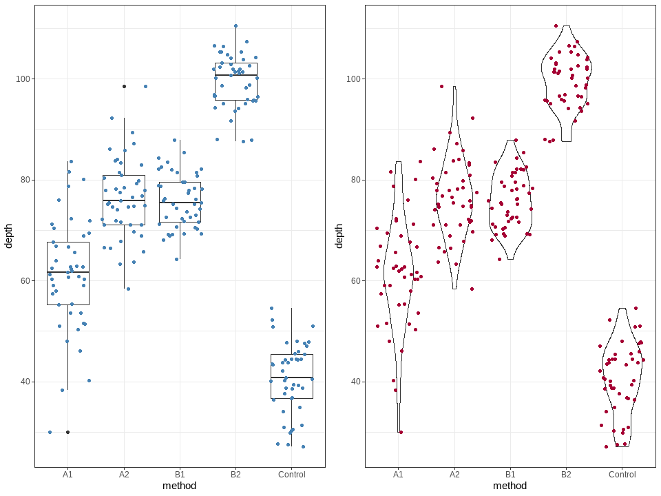

```r
g1 <- etch %>%
  ggplot(aes(x = method, y = depth)) +
  geom_boxplot() +
  geom_jitter(color = sbl) +
  theme_bw()

g2 <- etch %>%
  ggplot(aes(x = method, y = depth)) +
  geom_violin() +
  geom_jitter(color = lre) +
  theme_bw()
gridExtra::grid.arrange(g1, g2, ncol = 2)
```

- ANOVA 진행

```r
model <- aov(depth ~ method, data = etch)
summary(model)
```

```
##              Df Sum Sq Mean Sq F value              Pr(>F)
## method        4  84764   21191     360 <0.0000000000000002 ***
## Residuals   220  12961      59
## ---
## Signif. codes:  0 '***' 0.001 '**' 0.01 '*' 0.05 '.' 0.1 ' ' 1
```

- p-value = 0.0000000000000002 < 0.05 이므로 $H_{0}$를 기각한다.
  - 따라서 고려된 식각 방법이 모두 동일하지는 않다.
- 수준 별 요약값 정리

```r
model.tables(model, tpye = "means", se = TRUE)
```

```
## Tables of effects
##
##  method
## method
##      A1      A2      B1      B2 Control
##   -9.54    5.66    5.12   28.83  -30.06
##
## Standard errors of effects
##         method
##          1.144
## replic.     45
```

- 각 방법의 효과의 크기를 나타낸다.
  - `Control` 방법은 전체 평균보다 약 30.06만큼 낮은 것을 알 수 있다.
  - `B2` 방법은 전체 평균보다 약 28.83보다 높은 것을 알 수 있다.
    - 따라서 `B2’ 방법이 가장 깊은 식각을 제공한다.
- 잔차 진단

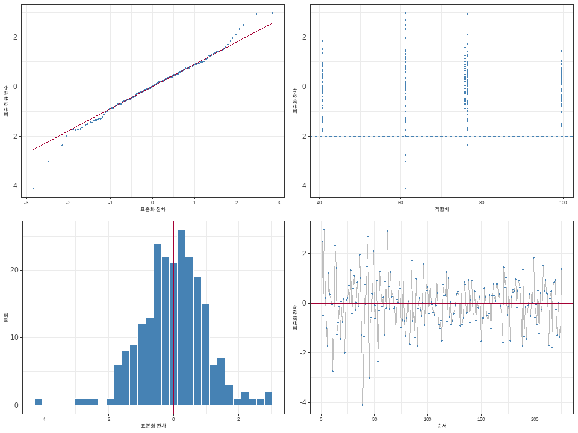

```r
etch$res <- resid(model)
etch$rsd <- rstandard(model)
etch$fit <- fitted.values(model)
m_residuals(etch)
```

- Quantile-Quantile (Q-Q) 그래프 (왼쪽 상단 그래프)
  - 잔차가 정규 분포를 따른다면 점들이 직선을 이루게 된다.
  - 대부분의 점들이 빨간선 주변에 위치하고 있다. 하지만 극단값에서는 라인에서 약간 벗어나 있다.
    - 따라서 꼬리 부분에서 이상치의 가능성이 있다.
- 잔차 vs 예측값 그래프 (오른쪽 상단 그래프)
  - 일정한 주기로 반복되는 패턴을 보인다.
- 잔차의 히스토그램 (왼쪽 하단 그래프)
  - 대체로 히스토그램의 종 모양에 가깝다.
- 잔차 vs 순서 그래프 (오른쪽 하단 그래프)
  - 잔차의 변동성이 커보인다.
- 표준화 잔차의 정규성 진단

```r
ad.test(etch$rsd)
```

```
##
##  Anderson-Darling normality test
##
## data:  etch$rsd
## A = 0.7, p-value = 0.08
```

# 선형 회귀 분석

Linear Regression Analysis

- 회귀 계수는 통계량이다.
- 회귀 분석은 알려져 있지 않은 f(x)를 대상으로 적용된다.
- 모수 절약(Parsimony)의 원칙 하에서 과현상에 대한 해석력(Interpretation)을 확보해야 한다.
- 선형 회귀 분석 Linear Regression Analysis
  - **동시**에 측정했을 때 사용**(같은 공간, 시간일 때)**
- y: **반응 변수(response)**, 종속 변수
- x: **설명 변수(exploratory variable(s))**, 예측 변수, 독립변수

# 4. 단순 회귀 분석

Simple Regression Analysis

$$y_i = \beta_0 + \beta_1x_i + \varepsilon_i \quad (i =
1,2,...,n),~~\varepsilon_i \sim iid \ N(0,\sigma^2)$$

- 오차는 상호 독립이다.
- 오차는 정규 분포(normal distribution)를 따른다.
- 오차는 모든 설명 변수의 값에 대하여 분산 $\sigma^2$가 같다.
  - iid; independently identically distributed
- 데이터를 이용한 회귀 계수(들)와 분산의 추정

$$(x_i,y_i), \ i = 1,2,...,n \rightarrow (\beta_0, \beta_1, \sigma^2)$$

- 추정된 회귀식(estimated regression equation)
  - $\hat{y} = y_0$은 평균 반응(mean response)으로 해석
  - 고려된 데이터의 범위 내에서 적용

$$\hat{y} = \beta_0 + \beta_1x_i,~~~x \in [x_{min}, x_{max}]$$

- $i$th 잔차(residual); $\varepsilon_i$
  - 가정된 모형 하에서 오차의 추정값
  - 관측값 $y_i$와 추정된 회귀선 $\hat{y}_i$의 차이

$$\varepsilon_i = y_i - \hat{y}_i = y_i - (\beta_0 + \beta_1x_i), \quad (i
= 1,2,...,n)$$

## 4.1. 회귀 계수의 추정: 최소 제곱법

Method of Least Squares

$$\arg \min_{\beta_0, \beta_1} L(\beta_0,
\beta_1) = \sum_{i=1}^{n} (y_i - \beta_0 - \beta_1 x_i)^2$$

- 최소 제곱 추정량(LSE)

$$\hat{\beta}_0 = \bar{y} - \hat{\beta}_1
\bar{x}$$
$$\hat{\beta}_1 =
\frac{S_{xy}}{S_{xx}}$$

여기서,

$$S_{xx} = \sum_{i=1}^{n} (x_i -
\bar{x})^2$$
$$S_{xy} = \sum_{i=1}^{n}
(y_i - \bar{y})(x_i - \bar{x})$$

- LSE의 통계적 특성

$$E(\hat{\beta}_0) = \beta_0, \quad
Var(\hat{\beta}_0) = \sigma^2 \left( \frac{1}{n} +
\frac{\bar{x}^2}{S_{xx}} \right)$$
$$E(\hat{\beta}_1) = \beta_1, \quad
Var(\hat{\beta}_1) = \frac{\sigma^2}{S_{xx}}$$

## 4.2. 잔차

residuals

- 잔차에는 설명 가능한 특정 패턴이 남아 있지 않아야 한다.

## 4.3. 변동의 분해

decompostion of variations

- 적합한 $R^2$를 판단하기 위한 통계적 기준값은 없다.
  - ex) 0.64이상
- 결정 계수만으로 올바른 회귀 모형을 결정할 수 없다.

## 4.4. 회귀 계수의 유의성 검정

- 일반적으로 $\beta_0$의 유의성 검정 결과는 고려하지 않는다.
- $\beta_0 = 0$을 적용한 경우를 원점을 통과하는 회귀 모형이라고 한다.
- $\beta_1$의 유의성 검정 결과는 가정된 모형의 타당성에 종속된다.

## 4.5. 추정된 회귀식의 활용

- 예측 구간(prediction interval)은 항상 신뢰 구간(confidence interval)보다 넓거나 같다.
- 만일 일정 범위에서 가능한 모든 x 값에 대하여 구해진 신뢰구간과 예측 구간을 각각 신뢰대(confidence bands) 그리고 예측대(prediction bands)라고 부른다.

## 실습 17. 임의로 선택된 소형 화물의 무게$(x;~g)$과 부피$(y;~cm^3)$

- 예제1 simple.csv
- 무게에 의하여 운송 요금을 결정하는 소형 화물들 중에서 임의로 선택된 58개의 무게(x; weight)과 부피(y; volume)을 조사하였다.
- 이를 이용하여 중량과 부피간의 관계를 추정하여 운송 계획을 수립하고자 한다.
- 데이터 불러오기 및 확인

```r
cargo <- read.csv(paste0(data_path, "simple.csv"))
str(cargo)
```

```
## 'data.frame':    58 obs. of  3 variables:
##  $ x : num  80.9 84.2 127.2 78.9 95.5 ...
##  $ y : num  2070 2799 4021 2496 2478 ...
##  $ hy: num  2358 2465 3824 2295 2820 ...
```

- 결측값 확인

```r
na_count(cargo)
```

```
##  x  y hy
##  0  0  0
```

- 세 개의 변수 모두 결측값이 없다.
- LS 추정량 계산
  - **round(x, digits = k)**는 유효 숫자를 소수점 k번째로 반올림한다.

```r
x <- cargo$x
y <- cargo$y
Sxy <- sum((x - mean(x)) * (y - mean(y)))
Sxx <- sum((x - mean(x))^2)
Syy <- sum((y - mean(y))^2)
#
hat_beta1 <- Sxy / Sxx
hat_beta0 <- mean(y) - hat_beta1*mean(x)
round(c(hat_beta0, hat_beta1), 2)
```

```
## [1] -204.1   31.7
```

- 추정된 회귀 계수 $\hat\beta_0 = -204.1$ 그리고 $\hat\beta_1=31.7$로 계산되었다.
- simple_reg()함수를 통한 분석

```r
simple_reg(cargo, x, y)
```

```
##  x  y hy
##  0  0  0
##
## Call:
## lm(formula = y ~ x, data = data)
##
## Residuals:
##    Min     1Q Median     3Q    Max
## -930.9 -293.1   10.2  200.2 1000.0
##
## Coefficients:
##             Estimate Std. Error t value           Pr(>|t|)
## (Intercept)   -204.1      289.9    -0.7               0.48
## x               31.7        2.9    10.9 0.0000000000000016 ***
## ---
## Signif. codes:  0 '***' 0.001 '**' 0.01 '*' 0.05 '.' 0.1 ' ' 1
##
## Residual standard error: 409 on 56 degrees of freedom
## Multiple R-squared:  0.681,  Adjusted R-squared:  0.675
## F-statistic:  120 on 1 and 56 DF,  p-value: 0.00000000000000162
```

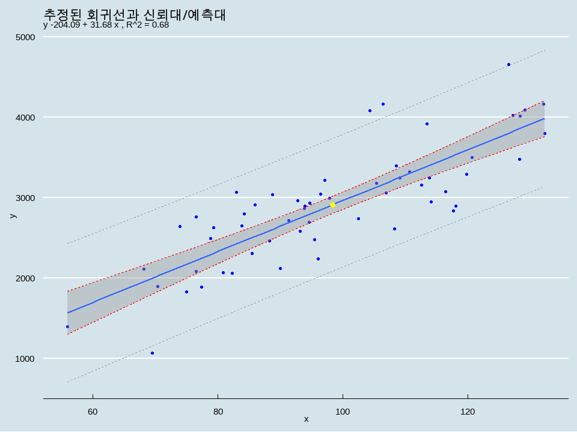

- 결측치는 존재하지 않는다.
- 결정계수값은 0.68로 잘 적합하고 있다고 볼 수 있다.
- p-value = 0.00000000000000162 < $\alpha = 0.05$ 이므로 $H_{0}$를 기각하므로 통계적으로 유의하다.
  - 따라서 위 회귀모형은 적절하다.
- 신뢰대는 빨간색 점선으로 이루어져 있다.
  - 노란색으로 색칠된 데이터가 위 데이터의 평균을 의미하고 평균을 기준으로 95%에 대한 신뢰구간이다.
- 예측대를 확인해봤을 때 일부 이상치가 있는 것으로 보인다.

## 실습 18. 유통 매장 정리 시간

```r
dist <- read.csv(paste0(data_path, "dist.store.csv"))
```

- 데이터 확인

```r
str(dist)
```

```
## 'data.frame':    25 obs. of  3 variables:
##  $ Time    : num  16.7 11.5 12 14.9 13.8 ...
##  $ Case    : int  7 3 3 4 6 7 2 7 30 5 ...
##  $ distance: int  280 110 170 40 75 165 55 105 730 302 ...
```

```r
head(dist)
```

```
##   Time Case distance
## 1 16.7    7      280
## 2 11.5    3      110
## 3 12.0    3      170
## 4 14.9    4       40
## 5 13.8    6       75
## 6 18.1    7      165
```

```r
tail(dist)
```

```
##    Time Case distance
## 20 35.1   17      385
## 21 17.9   10       70
## 22 52.3   26      405
## 23 18.8    9      225
## 24 19.8    8      318
## 25 10.8    4       75
```

```r
view(dist)
```

- 변수명을 소문자로 변환

```r
dist <- dist %>%
  rename_all(tolower)

head(dist, 5)
```

```
##   time case distance
## 1 16.7    7      280
## 2 11.5    3      110
## 3 12.0    3      170
## 4 14.9    4       40
## 5 13.8    6       75
```

- 각 변수별 결측값 확인하기

```r
na_count(dist)
```

```
##     time     case distance
##        0        0        0
```

- 세 변수 모두 결측값이 존재하지 않는다.
- 시각화: 관계의 검토

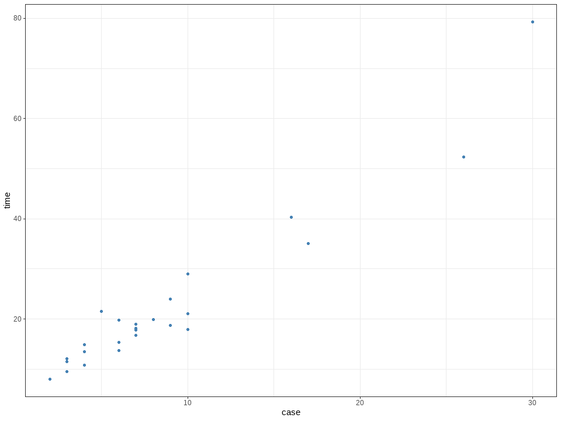

```r
dist %>%
  ggplot(aes(case, time)) +
  geom_point(color = sbl) +
  theme_bw()
```

- (case, time)의 관계는 직선의 경향을 갖는다.
- 회귀 분석의 실행

```r
dist_fit <- lm(time ~ case, data = dist)
```

- 분석 결과 확인

```r
summary(dist_fit)
```

```
##
## Call:
## lm(formula = time ~ case, data = dist)
##
## Residuals:
##    Min     1Q Median     3Q    Max
## -7.581 -1.874 -0.349  2.181 10.634
##
## Coefficients:
##             Estimate Std. Error t value           Pr(>|t|)
## (Intercept)    3.321      1.371    2.42              0.024 *
## case           2.176      0.124   17.55 0.0000000000000082 ***
## ---
## Signif. codes:  0 '***' 0.001 '**' 0.01 '*' 0.05 '.' 0.1 ' ' 1
##
## Residual standard error: 4.18 on 23 degrees of freedom
## Multiple R-squared:  0.93,   Adjusted R-squared:  0.927
## F-statistic:  308 on 1 and 23 DF,  p-value: 0.00000000000000822
```

- p-value = 0.00000000000000822 < $\alpha = 0.05$ 이므로 $H_{0}$를 기각한다.
  - 회귀 모형은 유의하다.
- `case`회귀 계수 또한 p-value < $\alpha = 0.05$로 유의하다.
- 현재 모형의 설명력은 0.93으로 높은 편이다.
- 회귀계수 확인

```r
summary(dist_fit)$coefficients
```

```
##             Estimate Std. Error t value            Pr(>|t|)
## (Intercept)     3.32      1.371    2.42 0.02372108174660464
## case            2.18      0.124   17.55 0.00000000000000822
```

- 잔차 확인

```r
summary(dist_fit)$residuals
```

```
##      1      2      3      4      5      6      7      8      9     10
## -1.874  1.651  2.181  2.855 -2.628 -0.444  0.327 -0.724 10.634  7.298
##     11     12     13     14     15     16     17     18     19     20
##  2.191 -4.082  1.475  3.372  1.094  3.918 -1.028  0.446 -0.349 -5.216
##     21     22     23     24     25
## -7.182 -7.581 -4.156 -0.900 -1.275
```

- `coef()`, `fitted()`, `resid()`: 회귀 계수, 추정값, 잔차 확인 가능

```r
coef(dist_fit) #추정된 회귀 계수 추출
```

```
## (Intercept)        case
##        3.32        2.18
```

```r
fitted(dist_fit) #현재 데이터를 이용한 추정값
```

```
##     1     2     3     4     5     6     7     8     9    10    11    12
## 18.55  9.85  9.85 12.03 16.38 18.55  7.67 18.55 68.61 14.20 38.14 25.08
##    13    14    15    16    17    18    19    20    21    22    23    24
## 12.03 16.38 22.91 25.08 16.38 18.55  9.85 40.32 25.08 59.90 22.91 20.73
##    25
## 12.03
```

```r
resid(dist_fit) #잔차
```

```
##      1      2      3      4      5      6      7      8      9     10
## -1.874  1.651  2.181  2.855 -2.628 -0.444  0.327 -0.724 10.634  7.298
##     11     12     13     14     15     16     17     18     19     20
##  2.191 -4.082  1.475  3.372  1.094  3.918 -1.028  0.446 -0.349 -5.216
##     21     22     23     24     25
## -7.182 -7.581 -4.156 -0.900 -1.275
```

- 표준화 잔차의 절대값이 2보다 크거나 같은 경우만을 선택

```r
rsd <- rstandard(dist_fit)
outliers_d <- as.numeric(names(rsd)[abs(rsd) >= 2])
dist[outliers_d, ]
```

```
##    time case distance
## 9  79.2   30      730
## 22 52.3   26      405
```

```r
dist_1 <- dist[-outliers_d, ]
```

- 스튜던트화 잔차의 절대값이 3보다 크거나 같은 경우만을 선택

```r
rst <- rstudent(dist_fit)
outliers_t <- as.numeric(names(rst)[abs(rst) >= 3])
dist[outliers_t, ]
```

```
##   time case distance
## 9 79.2   30      730
```

- $R^2_{pred}$의 계산

```r
PRESS <- sum(rstandard(dist_fit, type="pred")^2)
SST <- sum((dist$time - mean(dist$time))^2)
r.sq.p <- 1-(PRESS/SST)
paste("predicted R^2 = ", round(r.sq.p, 2))
```

```
## [1] "predicted R^2 =  0.87"
```

- 잔차 그림

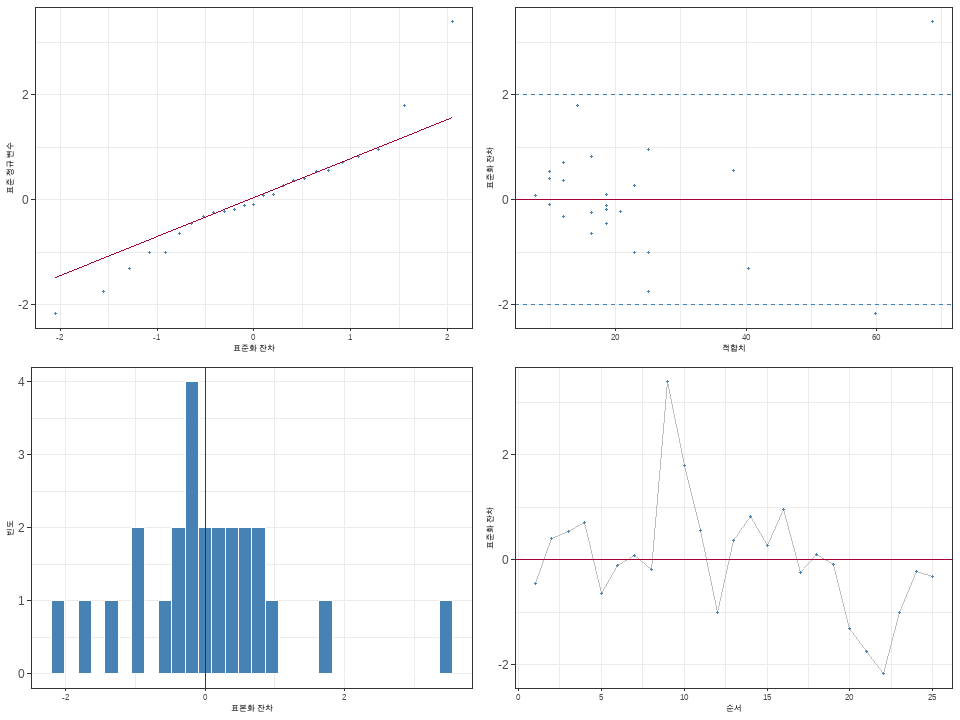

```r
rsd <- rstandard(dist_fit)
fit <- fitted.values(dist_fit)
dist_after <- cbind(dist, rsd, fit)

m_residuals(dist_after)
```

- 모형 적합 후 표준화 잔차와 적합치를 보완한 뒤에 잔차 분석`m_residuals(df)`을 실행
- `geom_smooth()`는 사전 분석 없이 기본 그림에 추정된 회귀식을 함께 도시해준다.

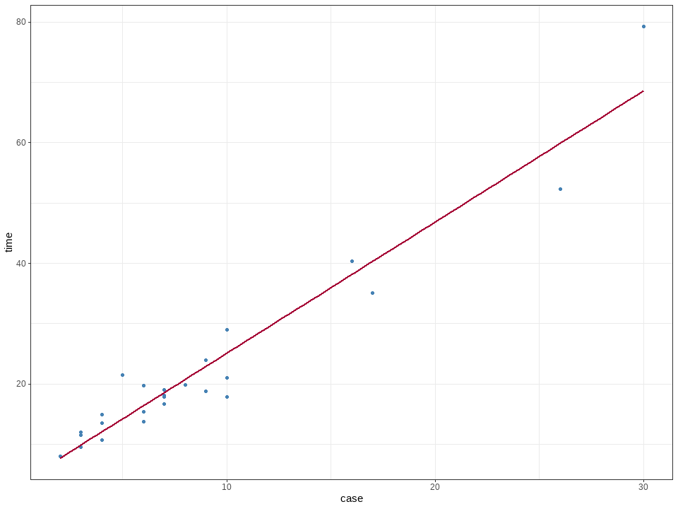

```r
dist %>%
  ggplot(aes(x = case, y = time)) +
  geom_point(color = sbl) +
  stat_smooth(method = "lm",
              formula = y~x,
              se = FALSE,
              color = lre
              ) +
  theme_bw()
```

- 평균 반응값의 구간 추정

```r
new_case <- data.frame(case = c(20, 30))
predict(dist_fit, newdata = new_case,
        interval = c("confidence"), level = 0.95)
```

```
##    fit  lwr  upr
## 1 46.8 43.5 50.2
## 2 68.6 62.9 74.3
```

- 새로운 관찰값에 대한 평균 반응값의 구간 추정

```r
new_case <- data.frame(case = c(20, 30))
predict(dist_fit, newdata = new_case,
        interval = c("prediction"), level = 0.95)
```

```
##    fit  lwr  upr
## 1 46.8 37.6 56.1
## 2 68.6 58.2 79.0
```

- 신뢰대(confidence bands)와 예측대(prediction bands)
  - ggfortify::는 통계 분석 결과를 시각화해주는 다양한 도구를 제공

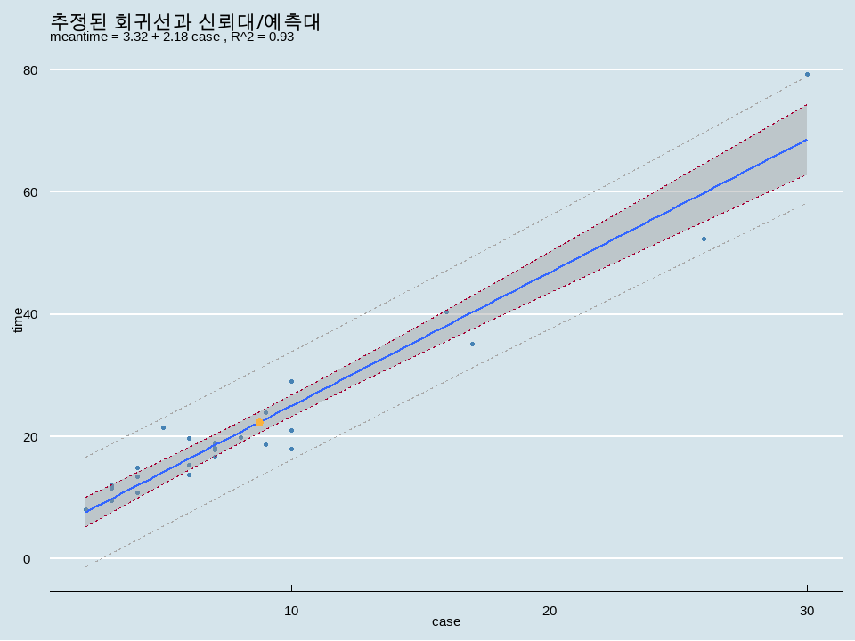

```r
# ggfortify 패키지 설치 및 불러오기
# install.packages("ggfortify")
library(ggfortify)
library(ggthemes)

# 데이터 생성
case_grid <- seq(min(dist$case), max(dist$case), by = 0.01)

# 신뢰구간(confidence bands) 예측
dist_c_band <- predict(dist_fit,
                       newdata = data.frame(case = case_grid),
                       interval = "confidence", level = 0.95)

# 예측구간(prediction bands) 예측
dist_p_band <- predict(dist_fit,
                       newdata = data.frame(case = case_grid),
                       interval = "prediction", level = 0.95)

# 그래프 그리기
ggplot(dist_fit, aes(x = case, y = time)) +
  geom_point(color = sbl) +
  geom_smooth(method = lm, se = TRUE) + # se=TRUE를 선택하여 신뢰 구간을 표시할 수 있다.
  geom_point(aes(x = mean(case), y = mean(time)),
             color = lgo,
             size = 3) +
  geom_line(data = dist_c_band,
            aes(x = case_grid, y = lwr),
            color = lre, linetype = "dashed") +
  geom_line(data = dist_c_band,
            aes(x = case_grid, y = upr),
            color = lre, linetype = "dashed") +
  geom_line(data = dist_p_band,
            aes(x = case_grid, y = lwr),
            color = "darkgray", linetype = "dashed") +
  geom_line(data = dist_p_band,
            aes(x = case_grid, y = upr),
            color = "darkgray", linetype = "dashed") +
  labs(title = "추정된 회귀선과 신뢰대/예측대",
       subtitle = paste("meantime =", round(dist_fit$coefficients[1], 2),
                        "+", round(dist_fit$coefficients[2], 2), "case",
                        ", R^2 =", round(summary(dist_fit)$r.squared, 2))) +
  theme_economist() +
  scale_color_economist()
```

- `case`에 따라 `time`이 어떻게 변화하는지를 나타내는 회귀선이다.
- `case`값이 1씩 증가할때마다 `time`이 2.18단위로 증가한다는 것을 의미한다.
- 결정계수값도 0.93으로 높은 값이라고 볼 수 있다.
  - `case`와 `time`사이에는 선형 관계가 있어보이고, 회귀식은 잘 적합되어 있어 보인다.
- 예측대 내에 데이터가 잘 들어와 있는 것으로 모아 모델이 잘 적합되어 있다.

## 실습 19. Test Case Determination

- test.sw.csv
- 00전자의 SWD팀은 최근 개발된 모델들을 중심으로 “KLOC”에 따른 적절한 ’Test Case’의 수에 대한 기준을 결정하기 위하여 기존 개발된 모델에서 두 변수간 밀접한 관계가 있는지를 확인하고, 이에 대한 모형을 설정하고자 한다.
  - 각 변수의 결측값(NA)의 수를 확인하시오.
  - 단순 회귀 모형을 가정하고 회귀 계수의 유의성 검정 결과를 제시하시오.
  - 결정 계수의 값을 제시하시오.
  - 잔차 진단을 실시하고 이상점 유무를 확인하시오.
  - 신뢰대와 예측대를 포함하여 단순 회귀 분석의 결과를 요약하시오.
- 데이터 불러오기

```r
swtest <- read.csv(paste0(data_path, "test.sw.csv"))
```

- 사용자 정의 함수 적용(단순 회귀 분석)

```r
swtest <- data.pre(swtest)
```

- 분석을 용이하게 하기 위하여 변수명을 소문자로 변환하였다.
- 잔차 진단

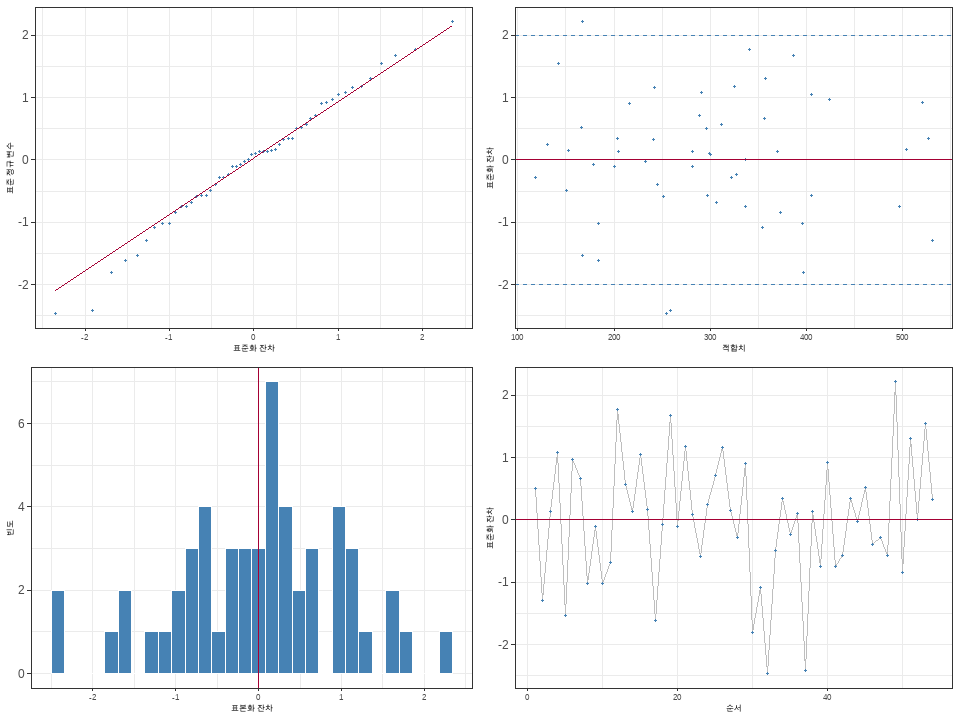

```r
swtest_fit <- lm(ttcase ~ kloc, data = swtest)

rsd <- rstandard(swtest_fit)
fit <- fitted.values(swtest_fit)
swtest_after <- cbind(swtest, rsd, fit)
m_residuals(swtest_after)
```

- 일부 양끝단을 제외하고는 정규성을 만족하는 것으으로 보인다.
- 정규성 검정 test

```r
ad.test(swtest_after$rsd)
```

```
##
##  Anderson-Darling normality test
##
## data:  swtest_after$rsd
## A = 0.2, p-value = 0.9
```

```r
pearson.test(swtest_after$rsd)
```

```
##
##  Pearson chi-square normality test
##
## data:  swtest_after$rsd
## P = 6, p-value = 0.5
```

```r
ks.test(swtest_after$rsd, "pnorm")
```

```
##
##  Exact one-sample Kolmogorov-Smirnov test
##
## data:  swtest_after$rsd
## D = 0.07, p-value = 0.9
## alternative hypothesis: two-sided
```

- 세가지의 정규성 테스트를 해본 결과 p-value > $\alpha = 0.05$ 이므로 $H_{0}$를 기각하지 못하였다.
  - 데이터는 정규성을 만족하는 것으로 보인다.
- 단순 회귀 분석 결과

```r
simple_reg(data = swtest, swtest$kloc, swtest$ttcase)
```

```
##      id  ttcase    kloc nesting  module   model
##       0       0       0       0       0       0
##
## Call:
## lm(formula = y ~ x, data = data)
##
## Residuals:
##     Min      1Q  Median      3Q     Max
## -145.55  -34.10    5.46   37.90  129.20
##
## Coefficients:
##             Estimate Std. Error t value             Pr(>|t|)
## (Intercept)  102.380     16.991    6.03           0.00000018 ***
## x             11.107      0.852   13.04 < 0.0000000000000002 ***
## ---
## Signif. codes:  0 '***' 0.001 '**' 0.01 '*' 0.05 '.' 0.1 ' ' 1
##
## Residual standard error: 59.7 on 52 degrees of freedom
## Multiple R-squared:  0.766,  Adjusted R-squared:  0.761
## F-statistic:  170 on 1 and 52 DF,  p-value: <0.0000000000000002
```

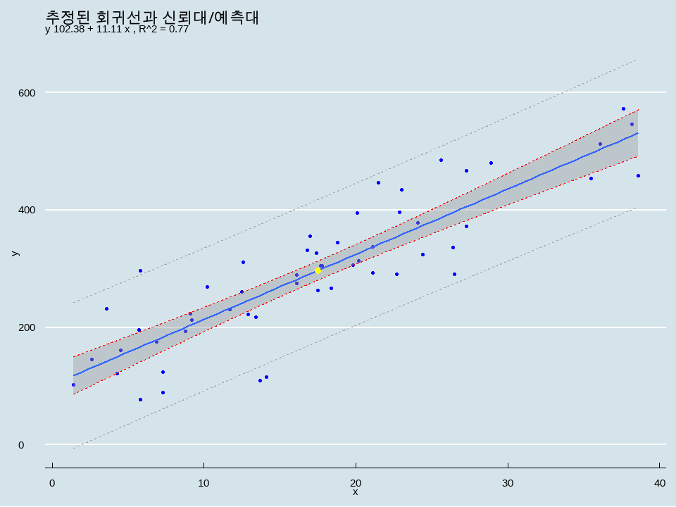

- 결측치는 존재하지 않는다.
- 결정계수값은 0.766로 잘 적합하고 있다고 볼 수 있다.
- p-value = 0.0000000000000002 < $\alpha = 0.05$ 이므로 $H_{0}$를 기각하므로 통계적으로 유의하다.
  - 위 회귀모형은 적절하다.
- 신뢰대는 빨간색 점선으로 회귀선의 평균값에 대한 신뢰도를 나타낸다.
  - 이는 회귀선의 평균값이 얼마나 정확한지를 의미한다.
- 예측대를 확인해봤을 때 모델이 데이터를 잘 반영하고 있다고 볼 수 있다.

# 5. 다중 회귀 분석

Multiple Regression Analysis

## 5.1. 최소 제곱법과 중요 결과

$$\arg
\min_{\beta_0,\beta_1,\beta_2,...,\beta_{p-1}}
L(\beta_0,\beta_1,\beta_2,...,\beta_{p-1})$$

여기서,

$$L
(\beta_0,\beta_1,\beta_2,...,\beta_{p-1}) = \sum_{i=1}^{n} (y_i -
\beta_0 - \beta_1 x_{i1} - \beta_2 x_{i2} - ... - \beta_{(p-1)}
x_{i(p-1)})^2$$
$$= (y - X\beta)^T (y
- X\beta)$$

- 회귀 계수의 LS추정량

$$\hat{\beta} = (X^T X)^{-1} X^T
y$$
$$E(\hat{\beta}) = \beta \quad
\text{그리고} \quad Var(\hat{\beta}) = \sigma^2 (X^T
X)^{-1}$$

- 반응값의 추정량과 잔차

$$\hat{y} = X\hat{\beta}, \quad e = y -
\hat{y} \quad$$
$$\quad \hat{y} =
E(y|X) = X \hat{\beta} = X(X^T X)^{-1} X^T y$$

- $\sigma^2$의 추정량 $s^2_{e}$

$$s^2_{e} = \frac{1}{n-p} \sum_{i=1}^{n}
(y_i - \hat{y}_i)^2 = \frac{e^T e}{n-p}$$

## 5.2. 변수 선택

Variable Selection

- 예측자(predictors)에 대한 사전 정보가 부족하여 적절한 예측자를 선정하지 못하거나
- 수집된 데이터에서 예측자가 많은 경우 적용
- AIC, BIC 모두 값이 작을수록 바람직하다.
  - AIC; Akike Information Criterion
  - BIC; Bayesian Information Criterion
- 2개 이상의 후보 모형을 선정하고, 잔차 분석 등의 추가 진단을 통하여 최종 모형을 선택한다.
  - **memisc::mtable()**: 모형의 비교 결과를 요약
- Mallow’s $C_{p}$
  - 회귀 모델 선택에서 사용되는 통계량
  - 여러 후보 회귀 모델 중에서 가장 적절한 모델을 선택하기 위한 기준으로 사용
  - 이 지표도 작을수록 잘 적합했다고 볼 수 있다.

### 5.2.1. 전방 선택

Foreward Selection

- 상수 모형에서 기여도가 큰 순서대로 Predictor들을 차례로 선택한다.
- 전 단계에서 모형에 포함된 Predictor들은 계속 모형에 남게 된다.
- 예측자(predictors) 들의 나열 순서는 영향을 주지 않는다.
  - **stat::step**은 AIC를 기준으로 변수를 선택한다.
  - BIC를 기준으로 변수를 선택하고자 하는 경우, k = long(n)을 옵션에 추가한다.
  - 전방 선택(direction = “forward”)의 경우, 시작 모형을 지정해야 한다.
  - 상수 모형인 경우 y ~ 1 그리고 반드시 포함해야 할 예측자가 있는 경우, y ~ x1 + x2..로 지정하여 사용한다.

### 5.2.2. 후방 제거

Backward Elimination

- 완전 모형에서 가장 기여도가 작은 순서대로 Predictor들을 차례로 제거한다.
- 전 단계에서 모형에서 제거된 예측자들은 모형에 다시 포함될 수 없다.
  - 후방 제거(direction = “backward”)의 경우, full model에서 시작하므로 시작 모형을 지정하지 않는다.

### 5.2.3. 단계별 선택

Stepwise Selection

- 후방 소거의 개념을 포함하는 전방 선택법으로 각 예측자들을 선택한 다음에 제거될 필요가 있는 예측자들을 검토하여 제거한다.
- 일단 모형에 포함된 예측자들도 다시 모형에서 제거될 수 있다.
- 단계적 선택법은 후방제거를 보완한 전방 선택법이다. 따라서 시작 모형을 반드시 지정해야 한다.

### 5.2.4. 모든 부분 집합

- 모든 가능한 회귀 모형을 적합하고, 예측자의 수에 따라 1개의 좋은 모형을 나열해 준다.
- 특정 모형을 지정해 주지 않는다.
  - **regsubsets()**을 이용하여 모든 부분 집합에 대한 회귀 모형을 고려한다.
    - 여기서, nvmax = k는 검토할 부분 집합의 최대값이다.

## 실습 20. C-materials

- cem.materials.csv
- 다음은 C-material의 구성 선분에 따른 발생 열량 관계를 분석하고자 조사된 데이터이다.
- 먼저 열량에 중요한 영향을 주는 구성 성분을 구별해 내고, 이를 통하여 발생 열량의 정도를 추정할 수 있다면, 응고 시간을 예측할 수 있어 조립 절차를 크게 간소화 할 수 있다고 한다.
- 구성 성분을 조절하여 실험하기에는 시간과 비용이 만힝 소요되어, 상대적으로 변동이 큰 표본들을 구분하여 총 4가지의 구성 성분(t1, t2, t3, t4)을 수집하였다.
- 반응값은 C-material 1g 내의 열량을 나타낸다.
- 데이터 불러오기

```r
cem <- read.csv(paste0(data_path,"cem.materials.csv"))
str(cem)
```

```
## 'data.frame':    13 obs. of  6 variables:
##  $ ID: int  1 2 3 4 5 6 7 8 9 10 ...
##  $ T1: int  7 1 11 11 7 11 3 1 2 21 ...
##  $ T2: int  26 29 56 31 52 55 71 31 54 47 ...
##  $ T3: int  6 15 8 8 6 9 17 22 18 4 ...
##  $ T4: int  60 52 20 47 33 22 6 44 22 26 ...
##  $ Y : num  78.5 74.3 104.3 87.6 95.9 ...
```

- 변수 이름과 위치 정리

```r
cem <- cem %>%
  dplyr::rename_all(tolower) %>%
  select(-id) %>%
  relocate(y)
```

- 결측값 확인

```r
na_count(cem)
```

```
##  y t1 t2 t3 t4
##  0  0  0  0  0
```

- 데이터 시각화: 행렬도(matrix plot)
  - lower는 matrix plot의 lower triangle을 말하고 upper는 upper triangle을 말한다.
  - point, smooth, cor(relation)을 선택 가능
  - diag는 대각 요소를 말함
  - densityDiag, barDiag, blankDiag를 선택 가능

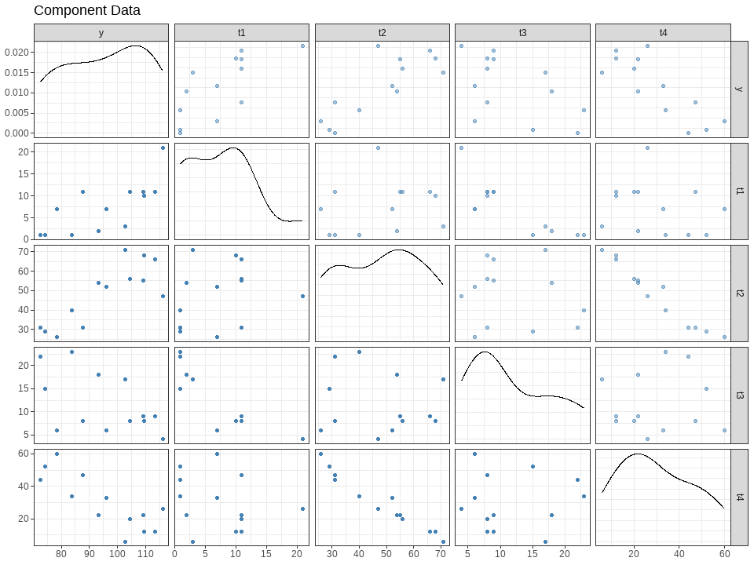

```r
cem %>%
  ggpairs(columns = 1:ncol(.),
          lower = list(continuous = wrap("points", # continuous = "smooth"
                                         color = sbl,
                                         aplha = 0.5)
                   ),
          upper = list(continuous = wrap("points", # wrap("cor", size = 2.5)
                                         color = sbl,
                                         alpha =0.5)
                   ),
          diag = list(continuous = wrap("densityDiag",
                                        color = "black",
                                        alpha = 0.5)
                   ),
          title = "Component Data") +
  theme_bw()
```

- 함수 정의
  - 원하는 형태의 행렬도(matrix plot) 형식을 결정하여 함수화
  - `gg_mplot(data, title)`

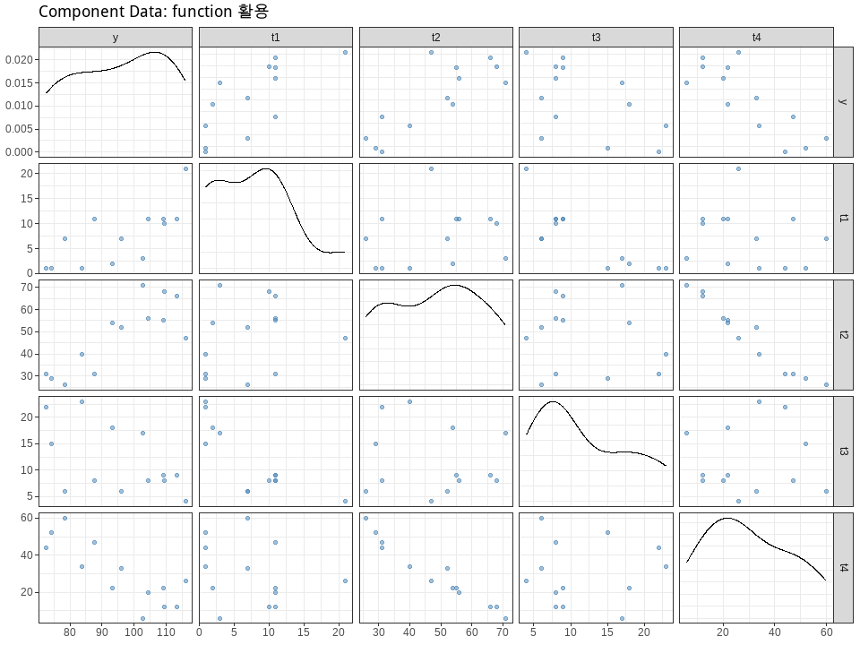

```r
gg_mplot <- function(df, ttl){
  df %>%
  ggpairs(columns = 1:ncol(.),
          lower = list(continuous = wrap("points", #continuous = "smooth"
                                         color = sbl,
                                         alpha = 0.5)
                       ),
          upper = list(continuous = wrap("points", #wrap("cor", size = 2.5)
                                         color = sbl,
                                         alpha = 0.5)
                       ),
          diag = list(continuous = wrap("densityDiag",
                                        color = "black",
                                        alpha = 0.5)
                       ),
          title = ttl) +
  theme_bw()
}

ttl = "Component Data: function 활용"
gg_mplot(cem, ttl)
```

- 다중 회귀 분석: **lm()*
  - **lm()* 함수는 단순 회귀 분석과 동일하게 적용된다.
  - 단, formula를 사전에 지정하는 경우에는 문자형으로 정의되어야 한다.

```r
fml <- "y ~ t1 + t2 + t3 + t4"
cem_model <- lm(fml, cem)
summary(cem_model)
```

```
##
## Call:
## lm(formula = fml, data = cem)
##
## Residuals:
##    Min     1Q Median     3Q    Max
## -3.175 -1.671  0.251  1.378  3.925
##
## Coefficients:
##             Estimate Std. Error t value Pr(>|t|)
## (Intercept)   62.405     70.071    0.89    0.399
## t1             1.551      0.745    2.08    0.071 .
## t2             0.510      0.724    0.70    0.501
## t3             0.102      0.755    0.14    0.896
## t4            -0.144      0.709   -0.20    0.844
## ---
## Signif. codes:  0 '***' 0.001 '**' 0.01 '*' 0.05 '.' 0.1 ' ' 1
##
## Residual standard error: 2.45 on 8 degrees of freedom
## Multiple R-squared:  0.982,  Adjusted R-squared:  0.974
## F-statistic:  111 on 4 and 8 DF,  p-value: 0.000000476
```

- 모든 변수가 유의하지 않지만, $R^2 = 0.982$이다.
- 회귀 분석 관련 추정값 추출

```r
cem_model$coefficients
```

```
## (Intercept)          t1          t2          t3          t4
##      62.405       1.551       0.510       0.102      -0.144
```

```r
summary(cem_model)$sigma
```

```
## [1] 2.45
```

- 구간 추정
  - lm()에 의한 model object가 생성
    - 신뢰도(level = )하에서 **stat::confint()**를 이용하여 개별 회귀 계수에 대한 구간 추정 결과를 확인
    - **conflict()**의 기본 함수 구조
      - 특정 회귀 계수(들)만을 원하는 경우, parm의 위치에 문자형으로 지정

```r
confint(cem_model, level = 0.95)
```

```
##               2.5 % 97.5 %
## (Intercept) -99.179 223.99
## t1           -0.166   3.27
## t2           -1.159   2.18
## t3           -1.638   1.84
## t4           -1.779   1.49
```

```r
confint(cem_model, c("t1", "t2"), level = 0.95)
```

```
##     2.5 % 97.5 %
## t1 -0.166   3.27
## t2 -1.159   2.18
```

- 가설 검정
  - lm()을 적용한 model object의 summary()의 coef를 부분 선택

```r
summary(cem_model)$coef
```

```
##             Estimate Std. Error t value Pr(>|t|)
## (Intercept)   62.405     70.071   0.891   0.3991
## t1             1.551      0.745   2.083   0.0708
## t2             0.510      0.724   0.705   0.5009
## t3             0.102      0.755   0.135   0.8959
## t4            -0.144      0.709  -0.203   0.8441
```

- 예측 구간 - **stat::predict()**:model object(class = lm)를 이용하여 점 추정과 구간 추정을 실행
  - interval = c(“none”, “confidence”, “prediction”)
  - **“confidence”**는 평균 반응값에 대한 신뢰구간을 제공
  - **“prediction”**은 새로운 관찰값에서의 반응값에 대한 신뢰구간을 제공

```r
x0 <- data.frame(t1 = 11, t2 =56, t3 = 9, t4 = 20)
```

```r
#점추정
predict(cem_model, newdata = x0)
```

```
##   1
## 106
```

```r
#구간 추정: 신뢰 구간
predict(cem_model, newdata = x0, interval = "confidence", level = 0.95)
```

```
##   fit lwr upr
## 1 106 103 109
```

```r
#구간 추정: 예측 구간
predict(cem_model, newdata = x0, interval = "prediction", level = 0.95)
```

```
##   fit  lwr upr
## 1 106 99.7 112
```

### 변수 선택 실습

- 전방 선택법, 후방제거법, 단계별 선택법, 모든 부분 집합법

#### 전방 선택

- 선택 과정의 정보를 생략하고 최종 경과만을 확인하고 싶으면 trace = 0 옵션을 추가한다.

```r
# fml <- "y ~ t1 + t2 + t3+ t4"
model_start <- lm(y ~ 1, data = cem)
cem_fore_aic <- step(model_start, scope = fml, diretion = "forward")
```

```
## Start:  AIC=71.4
## y ~ 1
##
##        Df Sum of Sq  RSS  AIC
## + t4    1      1832  884 58.9
## + t2    1      1809  906 59.2
## + t1    1      1450 1266 63.5
## + t3    1       776 1939 69.1
## <none>              2716 71.4
##
## Step:  AIC=58.9
## y ~ t4
##
##        Df Sum of Sq  RSS  AIC
## + t1    1       809   75 28.7
## + t3    1       708  176 39.9
## <none>               884 58.9
## + t2    1        15  869 60.6
## - t4    1      1832 2716 71.4
##
## Step:  AIC=28.7
## y ~ t4 + t1
##
##        Df Sum of Sq  RSS  AIC
## + t2    1        27   48 25.0
## + t3    1        24   51 25.7
## <none>                75 28.7
## - t1    1       809  884 58.9
## - t4    1      1191 1266 63.5
##
## Step:  AIC=25
## y ~ t4 + t1 + t2
##
##        Df Sum of Sq RSS  AIC
## <none>               48 25.0
## - t4    1        10  58 25.4
## + t3    1         0  48 26.9
## - t2    1        27  75 28.7
## - t1    1       821 869 60.6
```

- 최종 선택된 모형의 회귀 계수의 수(p)와 AIC 제공

```r
extractAIC(cem_fore_aic)
```

```
## [1]  4 25
```

- 추정된 회귀 계수들

```r
coef(cem_fore_aic)
```

```
## (Intercept)          t4          t1          t2
##      71.648      -0.237       1.452       0.416
```

- Adj $R^2$

```r
summary(cem_fore_aic)$adj.r.squared
```

```
## [1] 0.976
```

- BIC

```r
cem_fore_bic <- step(model_start, scope = fml, direction = "forward",
                     k = log(length(cem)),
                     trace = 0)
coef(cem_fore_bic)
```

```
## (Intercept)          t4          t1          t2
##      71.648      -0.237       1.452       0.416
```

- Adj $R^2$

```r
summary(cem_fore_bic)$adj.r.squared
```

```
## [1] 0.976
```

- 최종 모형의 formula확인

```r
formula(cem_fore_bic)
```

```
## y ~ t4 + t1 + t2
```

#### 후방 제거

- full model에서 시작하기 때문에 시작 모형을 지정하지 않는다.
- AIC

```r
cem_back_aic <- step(cem_model, direction = "backward", trace = 0)
extractAIC(cem_back_aic)
```

```
## [1]  4 25
```

```r
coef(cem_back_aic)
```

```
## (Intercept)          t1          t2          t4
##      71.648       1.452       0.416      -0.237
```

- AIC를 기준으로 최종 모형의 formula

```r
formula(cem_back_aic)
```

```
## y ~ t1 + t2 + t4
## <environment: 0x000001d02743b4e8>
```

- BIC

```r
n <- length(resid(cem_model))
```

```r
cem_back_bic <- step(cem_model, direction = "backward",
                     k = log(n),
                     trace = 0)
coef(cem_back_bic)
```

```
## (Intercept)          t1          t2
##      52.577       1.468       0.662
```

- BIC를 기준으로 최종 모형의 formula

```r
formula(cem_back_bic)
```

```
## y ~ t1 + t2
## <environment: 0x000001d02743b4e8>
```

#### 단계별 선택

- 시작 모형을 반드시 지정해야 한다.

```r
cem_both_aic <- step(model_start, scope = fml, diretion = "both", trace = 0)
cem_both_bic <- step(model_start, scope = fml, diretion = "both",
                     k = log(n),
                     trace = 0)
```

- 단계별 선택법에 의하여 선택된 최종 모형의 formula

```r
formula(cem_both_aic)
```

```
## y ~ t4 + t1 + t2
```

- AIC와 BIC기준으로 각각의 변수 선택 방법에 의하여 도출된 최종 모형을 비교

```r
final.model_aic <- rbind("forward" = as.character(formula(cem_fore_aic))[3],
                         "backward" = as.character(formula(cem_back_aic))[3],
                         "stepwise" = as.character(formula(cem_both_aic))[3]
                         )
final.model_bic <- rbind("forward" = as.character(formula(cem_fore_bic))[3],
                         "backward" = as.character(formula(cem_back_bic))[3],
                         "stepwise" = as.character(formula(cem_both_bic))[3]
                         )
info <- cbind(final.model_aic, final.model_bic)
colnames(info) <- c("AIC", "BIC")
info
```

```
##          AIC            BIC
## forward  "t4 + t1 + t2" "t4 + t1 + t2"
## backward "t1 + t2 + t4" "t1 + t2"
## stepwise "t4 + t1 + t2" "t1 + t2"
```

- AIC에 기초하여 선택된 모형의 예측자는 3가지 방법 모두 (t1, t2, t4)로 동일하다.
- BIC에 기초하여 선택된 예측자는 (t1, t2, t4)와 (t1, t2)이다.
- 결과가 비슷하다면, 가능한 한 간단한 모형을 선택하는 것이 바람직하다.
- AIC에 의하여 선택된 최종 모형의 결과는 다음과 같다.

```r
extractAIC(cem_fore_aic)
```

```
## [1]  4 25
```

```r
extractAIC(cem_back_aic)
```

```
## [1]  4 25
```

```r
extractAIC(cem_both_aic)
```

```
## [1]  4 25
```

```r
summary(cem_back_aic)
```

```
##
## Call:
## lm(formula = y ~ t1 + t2 + t4, data = cem)
##
## Residuals:
##    Min     1Q Median     3Q    Max
## -3.092 -1.802  0.256  1.282  3.898
##
## Coefficients:
##             Estimate Std. Error t value   Pr(>|t|)
## (Intercept)   71.648     14.142    5.07    0.00068 ***
## t1             1.452      0.117   12.41 0.00000058 ***
## t2             0.416      0.186    2.24    0.05169 .
## t4            -0.237      0.173   -1.37    0.20540
## ---
## Signif. codes:  0 '***' 0.001 '**' 0.01 '*' 0.05 '.' 0.1 ' ' 1
##
## Residual standard error: 2.31 on 9 degrees of freedom
## Multiple R-squared:  0.982,  Adjusted R-squared:  0.976
## F-statistic:  167 on 3 and 9 DF,  p-value: 0.0000000332
```

- 세 가지 방법 모두 AIC가 동일하다.
- BIC도 각각의 값들을 확인을 해보았다.

```r
extractAIC(cem_fore_bic)
```

```
## [1]  4 25
```

```r
extractAIC(cem_back_bic)
```

```
## [1]  3.0 25.4
```

```r
extractAIC(cem_both_bic)
```

```
## [1]  3.0 25.4
```

- BIC에 의하여 선택된 최종 모형의 결과는 다음과 같다.

```r
summary(cem_back_bic)
```

```
##
## Call:
## lm(formula = y ~ t1 + t2, data = cem)
##
## Residuals:
##    Min     1Q Median     3Q    Max
##  -2.89  -1.57  -1.30   1.36   4.05
##
## Coefficients:
##             Estimate Std. Error t value      Pr(>|t|)
## (Intercept)  52.5773     2.2862    23.0 0.00000000055 ***
## t1            1.4683     0.1213    12.1 0.00000026922 ***
## t2            0.6623     0.0459    14.4 0.00000005029 ***
## ---
## Signif. codes:  0 '***' 0.001 '**' 0.01 '*' 0.05 '.' 0.1 ' ' 1
##
## Residual standard error: 2.41 on 10 degrees of freedom
## Multiple R-squared:  0.979,  Adjusted R-squared:  0.974
## F-statistic:  230 on 2 and 10 DF,  p-value: 0.00000000441
```

- 이 모형같은 경우에는 더 적은 변수로 회귀식을 도출할 수 있다.
- 다른 방법같은 경우에도 비슷한 BIC를 보이므로 잔차 분석을 통한 추가 분석도 고려해 볼 필요가 있다.

#### 모든 부분 집합

- `library(leaps)`
  - **regsubsets()**을 이용하여 모든 부분 집합에 대한 회귀모형을 고려한다.
    - nvmax = k는 검토할 부분집합의 최대값
  - **memisc::mtable()**: 모형의 비교 결과를 요약한다.

```r
library(leaps)

temp <- leaps(x = cem[, -1], y = cem[ , 1])
full <- as.formula(paste("y ~ ",
                         paste(colnames(cem[-1]), collapse = "+"))
                   )
cem_all <- regsubsets(full, data = cem, nvmax = 4)
summary(cem_all)
```

```
## Subset selection object
## Call: regsubsets.formula(full, data = cem, nvmax = 4)
## 4 Variables  (and intercept)
##    Forced in Forced out
## t1     FALSE      FALSE
## t2     FALSE      FALSE
## t3     FALSE      FALSE
## t4     FALSE      FALSE
## 1 subsets of each size up to 4
## Selection Algorithm: exhaustive
##          t1  t2  t3  t4
## 1  ( 1 ) " " " " " " "*"
## 2  ( 1 ) "*" "*" " " " "
## 3  ( 1 ) "*" "*" " " "*"
## 4  ( 1 ) "*" "*" "*" "*"
```

```r
model.q <- summary(cem_all)
```

모형 선택중

```r
# 수정 결정계수가 가장 큰 모형
(adj.r2 <- which.max(model.q$adjr2))
```

```
## [1] 3
```

```r
# Cp가 가장 작은 모형
(cp <- which.min(model.q$cp))
```

```
## [1] 2
```

```r
# BIC가 가장 작은 모형
(bic <- which.min(model.q$bic))
```

```
## [1] 2
```

- 2개 이상의 후보 모형을 선정하고, 잔차 분석 등의 추가 진단을 통하여 최종 모형을 선택

```r
# install.packages("memisc")

library(memisc)
model_1 <- lm(formula = y ~ t1, data = cem)
model_2 <- lm(formula = y ~ t1 + t2, data = cem)
model_3 <- lm(formula = y ~ t1 + t2 + t3, data = cem)
model_4 <- lm(formula = y ~ t1 + t2 + t3 + t4, data = cem)

s_table <- mtable("M1" = model_1, "M2" = model_2, "M3" = model_3, "M4" = model_4,
                  summary.stats = c("sigma", "R-squared", "F", "P"))
s_table
```

```
##
## Calls:
## M1: lm(formula = y ~ t1, data = cem)
## M2: lm(formula = y ~ t1 + t2, data = cem)
## M3: lm(formula = y ~ t1 + t2 + t3, data = cem)
## M4: lm(formula = y ~ t1 + t2 + t3 + t4, data = cem)
##
## ============================================================
##                   M1          M2          M3         M4
## ------------------------------------------------------------
##   (Intercept)  81.479***   52.577***   48.194***   62.405
##                (4.927)     (2.286)     (3.913)    (70.071)
##   t1            1.869**     1.468***    1.696***    1.551
##                (0.526)     (0.121)     (0.205)     (0.745)
##   t2                        0.662***    0.657***    0.510
##                            (0.046)     (0.044)     (0.724)
##   t3                                    0.250       0.102
##                                        (0.185)     (0.755)
##   t4                                               -0.144
##                                                    (0.709)
## ------------------------------------------------------------
##   sigma        10.727       2.406       2.312       2.446
##   R-squared     0.534       0.979       0.982       0.982
##   F            12.603     229.504     166.345     111.479
## ============================================================
##   Significance: *** = p < 0.001; ** = p < 0.01;
##                 * = p < 0.05
```

- $Mallow's~C_{p}$는 다음을 이용하여 계산한다.

```r
# install.packages("olsrr")
library(olsrr)
full <- as.formula(paste("y ~ ",
                         paste(colnames(cem[-1]), collapse = "+"))
                         )
full
```

```
## y ~ t1 + t2 + t3 + t4
```

```r
temp <- as.formula(paste("y ~ ",
                         paste(colnames(cem[-c(1, 5:6)]), collapse = "+"))
                   )
temp
```

```
## y ~ t1 + t2 + t3
```

```r
f_model <- lm(formula(full), data = cem)
t_model <- lm(formula(temp), data = cem)
ols_mallows_cp(t_model, f_model) # 반드시 full_model 지정
```

```
## [1] 3.04
```

- Cp결과 값이 3.04로 나왔는데, 이는 t_model의 적합도와 변수의 수를 고려할 때의 평가 결과이다.
- `t_model`의 경우 세 가지의 설명변수를 사용했는데 Cp값이 3.04가 나왔다는 건 적절하다고 보인다.
- 이번에는 BIC 모형에서의 결과인, (t1, t2)를 사용한 모형에도 적용을 해보았다.

```r
full <- as.formula(paste("y ~ ",
                         paste(colnames(cem[-1]), collapse = "+"))
                         )
full
```

```
## y ~ t1 + t2 + t3 + t4
```

```r
temp <- as.formula(paste("y ~ ",
                         paste(colnames(cem[-c(1, 4:6)]), collapse = "+"))
                   )
temp
```

```
## y ~ t1 + t2
```

```r
f_model <- lm(formula(full), data = cem)
t_model <- lm(formula(temp), data = cem)
ols_mallows_cp(t_model, f_model) # 반드시 full_model 지정
```

```
## [1] 2.68
```

## 5.3. 다중 공선성

- 다중 공선성의 원인
  - 데이터 수집 방법
  - 모집단 또는 모형의 제약 조건
  - 모형의 선택(Predictor의 결정)
  - 과적합(Over-fitting) 모형의 사용(n < p)
- 분산 팽창 지수(Variance Inflation Factor; VIF)
  - $VIF_{j}~=~\frac{1}{1-R^2_j}~,j=1,2,...,(p-1)$
  - VIF $\approx$ 1이면, 다른 예측자들과 공선성 없는 직교 예측자
  - VIF > 5이면, 다른 Predictor들과 다중 공선성 의심
  - VIF > 10이면, 다른 Predictor들과 심각한 다중 공선성
- $\sqrt({VIF_{j}})$는 해당 변수가 모형의 다른 예측자와의 상관 계수가 0인 경우와 비교하여 해당 회귀 계수의 표준오차가 얼마나 크게 증가하는가를 나타낸다.

### 실습 21. 다중 공선성

- 완전 모형에서의 VIF

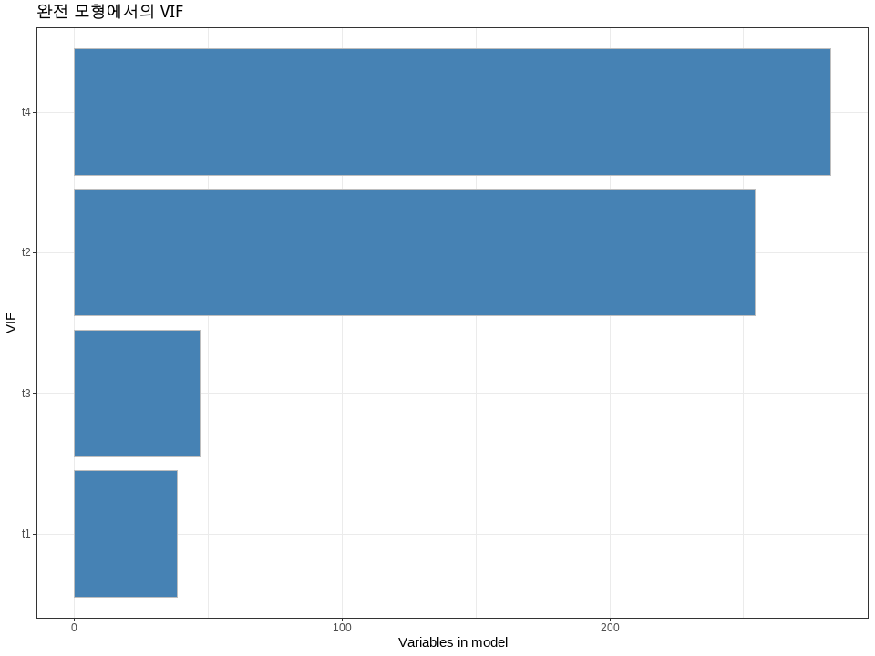

```r
fit_full <- lm(y ~ t1 + t2 +t3 + t4,
               data = cem
               )
vifs <- car::vif(fit_full)
vifs_d <- as.data.frame(vifs)
vifs_d %>%
  mutate(vars = rownames(.),
         vars = fct_reorder(vars, vifs)) %>%
  ggplot(aes(x=vars, y=vifs), fill = sbl) +
  geom_col(col = "gray", fill = sbl) +
  coord_flip() +
  xlab("VIF") +
  ylab("Variables in model") +
  labs(title = "완전 모형에서의 VIF") +
  theme_bw()
```

- 결과를 살펴보면 4개의 변수 중 다중공선성이 제일 작은 t1변수의 VIF값이 38.5로 나온다.
- VIF가 높은 변수를 제거해본다음에 다시 모델을 확인해볼 필요가 있어 보인다.
  - 만약, 도메인 지식을 고려했을 때 해당 변수가 모델 내 중요한 변수일수도 있기 때문에 신중하게 중요성을 고려해볼 필요가 있다.
- 완전 모형(full model)과 축소 모형(reduced model)의 회귀 계수의 표준 오차를 비교

```r
fit_reduced <- lm(y ~ t1 + t2, data = cem)
vifs <- car::vif(fit_reduced)
vifs
```

```
##   t1   t2
## 1.06 1.06
```

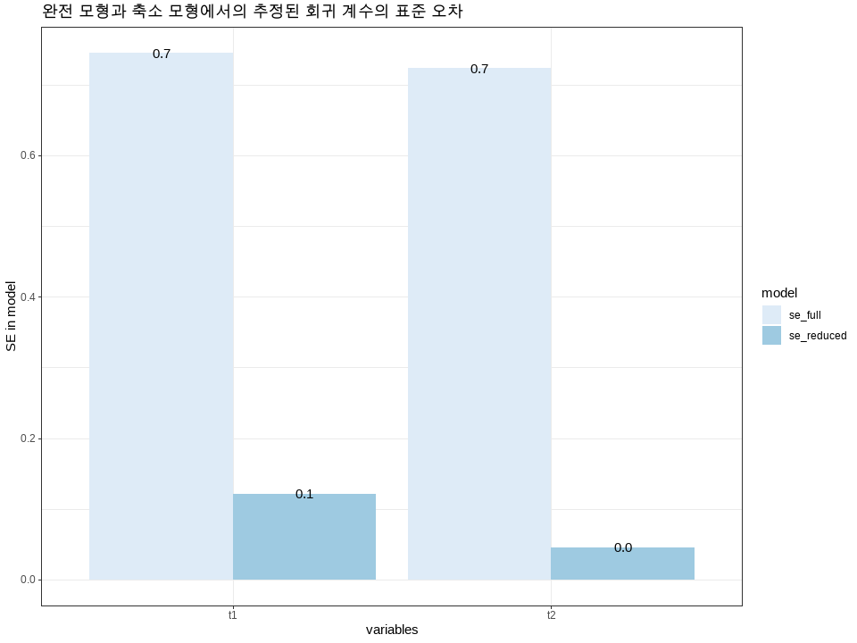

```r
#
se_reduced <- coef(summary(fit_reduced))[c("t1", "t2"), "Std. Error"]
se_full <- coef(summary(fit_full))[c("t1", "t2"), "Std. Error"]
#
se_compare <- as.data.frame(cbind(se_full, se_reduced))
se_compare %>%
  mutate(var = rownames(.)) %>%
  gather(model, se, se_full:se_reduced) %>%
  ggplot(aes(x=var, y=se, fill=model)) +
  geom_bar(stat="identity", position = position_dodge()) +
  geom_text(aes(var, se, label = sprintf("%2.1f", se),
                group = model),
            position = position_dodge(width = .9)) +
  xlab("variables") +
  ylab("SE in model") +
  labs(title = "완전 모형과 축소 모형에서의 추정된 회귀 계수의 표준 오차") +
  scale_fill_brewer(palette="Blues") +
  theme_bw()
```

- t1, t2 변수 각각 모두 축소 모형에서 추정된 회귀 계수의 표준 오차가 작을 것을 알 수 있다.
  - 이는 간단한 모형이 재현될 가능성이 높다라고 볼 수 있다.

# Part3, Cutting-Edge Approaches

# 1. Cuting-Edge Approaches Introduction

- 귀무 가설에 기반한 지식 생성과 샘플 외 패턴 일반화(out-of-sample pattern generation; test dataset)간의 문화적 충돌을 해소하기 위해서는 다음을 비교하여 방법을 분리할 수 있어야 한다.
  - 발생 동기와 역사적 궤적
  - 모델링 목적과 철학
  - 개념적 프레임워크
  - 성능 척도
- 통계 학습, 예측 모델링 그리고 기계 학습의 차이점은 무엇인가요?
- 2023.12월 chat chpt 답변:
  - 통계 학습: 통계 모델을 통해 데이터 관계를 이해하는 방법을 포괄하는 광범위한 범주입니다. 통계에 깊이 뿌리를 두고 있으며 변수 간의 관계를 이해하는 것을 의미하는 추론에 중점을 두고 있습니다. 통계적 학습 기술은 데이터의 기본 구조나 분포에 대한 결론을 내리는 데 사용됩니다. 그들은 종종 변수 간 관계의 본질을 알려줄 수 있는 해석 가능한 모델을 제공하는 것을 목표로 합니다.
  - 예측 모델링: 이는 알려진 데이터를 기반으로 알려지지 않은 미래 사건에 대해 예측하는 데 특히 초점을 맞춘 통계 학습과 기계 학습의 하위 집합입니다. 예측 모델링은 통계 기법을 사용하여 결과를 예측합니다. 기계 학습은 예측 모델링에 사용될 수 있지만 모든 예측 모델이 기계 학습 기술을 사용하여 구축되는 것은 아닙니다. 예측 모델링은 종종 모델의 해석 가능성보다 예측의 정확성을 우선시합니다.
  - 머신러닝: 머신러닝은 데이터로부터 학습하고 데이터를 기반으로 예측 또는 결정을 내릴 수 있는 알고리즘 개발과 관련된 인공 지능의 하위 집합입니다. 기계 학습에는 통계적 방법과 신경망과 같은 최신 기술이 모두 포함될 수 있습니다. 예측 정확도에 중점을 두는 경우가 많으며 대량의 데이터를 처리할 수 있습니다. 기계 학습 모델은 복잡할 수 있고 입력 데이터와 직접 연결하기 어려운 수많은 매개 변수를 포함하기 때문에 항상 해석하거나 설명할 수 있는 것은 아닙니다.
- 머신 러닝은 통계 학습과 예측 모델링을 포함한 학습 알고리즘에 대한 최적화/자동화를 목적으로 한다.
  - 머신 러닝에서는 인과 관계를 알수가 없는데 통계학습에서는 이를 알 수 가 있다.
  - 따라서 통계학습이 머신러닝에 선행이 되어야 한다.
- 학습 모델의 구축과 선택을 위한 기본 원칙
  - Data Quality matters
    - 데이터의 양과 질이 모든 성능을 결정
  - Occam’s Razor
    - 더 적은 것이 더 나은 것이다. -> 단순한 모델이 유용
  - Bet on Sparsity
    - 희소성에 기대 -> 중요한 특징들만을 사용한 모델이 유용할 가능성이 높음
  - Bias-Variance Trade-Off
    - 편의 분산의 균형을 달성
    - 너무 당연하면서도 어려운 결론이지만 편의와 분산 사이의 균형을 달성하는 적절한 복잡성의 모델을 선택해야 한다는 것이다.
  - No Free Lunch
    - 모든 문제에서 최적인 단일해는 없다.
    - 어떤 모델이든 모든 문제에 대한 항상 최고의 성능을 보장할 수는 없다.
      - 주어진 문제의 특성에 따라 달라진다.
- 학습 모델의 성능 평가와 개선
  - Hold-out and Resampling Method
    - 일반화 성능을 평가하는 게 주목적!
  - Regularization
    - 과적합(Overfitting)을 방지하여 일반화 성능을 향상
  - Ensemble Learning
    - 여러 개의 다른 모델을 결합하여 더 강력하고 일반화 성능이 높은 모델을 생성하는 방법
    - 꼭 트리구조에만 적용하는 것은 아니라는 것을 알기.
  - Feature Exploration and Analysis
    - 데이터의 변수를 탐색하고 모델에 적합한 변수들을 선택하거나 새로운 변수를 생성하여 일반화 성능을 향상하는 것이 목적
  - Data Balancing
    - 연속형 데이터의 입력 공간의 일부 영역에만 데이터가 존재하거나 범주형 데이터의 특정 범주에만 데이터가 밀집된 경우, 모델 성능에 부정적인 영향을 준다. 이러한 경우, 차원 축소 또는 다양한 표본 추출 방법들을 통하여 그 불균형을 개선함으로써 모델의 일반화 성능 향상을 목적
- 중요 학습 방법
  - 지도 학습 Supervised Learning
    - 입력 변수와 출력/목표 변수의 관계를 학습하는 방법
      - 회귀
        - 평가 척도: MSE, RMSE, MAE
      - 분류
        - 평가 척도: 오분류율, 정확도, 정밀도, 재현율, F1 점수, ROC곡선, AUC
    - 평가 척도를 기초로 모델의 성능을 평가, 수정 또는 개선하여 더 높은 예측 성능 달성
  - 비지도 학습
    - 목표 변수 없이 입력 데이터만을 사용하여 패턴, 구조 또는 관계를 찾아내는 학습 방법
      - 차원 축소 Dimensionality Reduction
        - 평가 척도: 재구성 오차
      - 군집화 Clustering
        - 평가 척도: 실루엣 계수, 외부 평가 척도, 내부 평가 척도
    - 목표 변수가 측정되지 않은 데이터에서 정보 또는 인사이트를 추출하는 데 유용
- 기타 학습 방법
  - 준지도 학습 Semi-Supervised Learning
    - 지도 학습과 비지도 학습의 중간 형태로, 수집된 데이터 중 일부에만 출력값이 존재할 때, 출력값이 없는 데이터를 학습하는 방법으로 비지도 학습을 통하여 얻은 정보를 활용하여 지도 학습의 성능을 향상시키는 목적
  - 강화 학습 Reinforcement Learning
    - 학습 주체(Agent)가 환경과 상호 작용에서 취한 행동의 결과에 따른 보상을 최대화하는 학습 방법, 주로 시간에 따라 순차적인 행동이 필요한 문제에 적용
  - 전이 학습 Transfer Learning
    - 한 작업에서 학습한 지식을 다른 작업에 활용하는 방법으로 기존의 학습된 모델을 다른 관련 작업에 적용하여 새로운 작업에서 더 빠르게 학습하여 더 나은 성능을 추구
  - 이상 감지 Anomaly Detection
    - 데이터에서 정상적인 패턴과는 다른 이상치를 탐지하는 기법으로 보안, 결함 탐지, 금융 사기 탐지 등 다양한 분야에 적용
  - 생성 모델 Generative Models
    - 생성 모델은 데이터 분포를 학습하여 새로운 샘플을 생성하는 기법으로 주로 이미지 생성, 음성 합성, 자연어 생성 등에 사용

# 2. 예측 성능의 평가

- 일반화 성능 Generalization Performance; test error
- 모델 학습에 사용되지 않은(unseen) 새로운 데이터에서의 예측 정확도 지표
- 일반화 성능의 올바른 평가와 최소화 방법
  - Holdout and Resampling method, 일반화 성능 평가
    - Train/validation/test
  - Cross Validation; CV
  - Bias-Variance Trade-Off
  - Bootstrap
- Nonlinear Pattern Modeling, 편의 감소
  - linear basis expansion
  - smoothing: 잡음 제거 효과
  - Kernel method: 차원이 기하급수적으로 늘어난다.
- Regularization, 일반화 성능 향상
  - Shrinkage/Penalized

## 2.1. 홀드아웃 방법

- Holdout Method
  - 훈련 세트를 이용하여 학습 모델의 구축/훈련
  - 시험 세트를 이용하여 학습 모델의 일반화 성능을 평가
    - 목적이 설명을 하는 것이 아니기 때문에 예측력이 높은 모델을 선택한다.
- 2-way Method
  - Training/Test Split
  - 8:2 / 7:3
  - 데이터 분할에 대한 정해진 답은 없다.
- 3-way Method
  - Training/Validation/Test Split
  - 훈련 세트에서 모델 학습/구축
  - 검증 세트에서 파라미터 최적화
  - 파라미터 결정 후, 훈련/검증 세트를 통합하여 재구축
  - 시험 세트를 이용하여 일반화 성능 평가
  - 시험 세트에서 가장 우수한 성능의 모델 선택
- 과적합 Overfitting
  - 학습 데이터에서는 높은 성능을 보이지만, 시험 데이터에서의 일반화 성능이 저하되는 현상
  - 모델이 실제 패턴과 관련성이 없는 불필요한 현상
    - 훈련 데이터의 잡음(noise)
    - 이상값(Outlier) 등
- Traing Error vs. Test Error
  - Bias-Variance Trade-Off를 잘 정해야 좋은 모델이 나온다.
  - Bias를 통해 예측값이 정답과 얼마나 다른가?를 알 수 있고, variance를 통해 예측값들이 예측값들의 평균과 얼마나 떨어져있는지. 즉, 자기들끼리 얼마나 떨어져있는지 파악할 수 있다.
  - **편향(Bias)**: 추정량의 편향은 추정량의 기대값이 추정하려는 모수의 실제 값에서 얼마나 벗어나 있는지를 나타내는 척도이다. 편향이 0인 추정량을 불편 추정량이라고 하며, 이는 추정량의 기대값이 추정하려는 모수의 실제 값과 일치함을 의미한다. 반면, 편향이 있는 추정량은 모수의 실제 값을 체계적으로 과대 혹은 과소 평가할 수 있다.
  - **평균 제곱 오차(Mean Squared Error, MSE)**: 추정량의 평균 제곱 오차는 추정량의 편향과 분산을 모두 고려한 척도이다. MSE는 추정량과 실제 모수 값과의 차이를 제곱한 값의 기대값이다.
  - 모델이 간단할수록 편의 증가, 분산 감소
  - 모델이 복잡할수록 편의 감소, 분산 증가
    - 따라서 적절한 Trade-Off 지점을 찾아줘야 한다.

### 실습. Hold-out Method

- Hold-out method는 패키지를 통해서 간단하게 구현 가능하다.
  - 기본 함수를 이용해서도 쉽게 적용 가능한 방법이다.
- 2-Way Method

```r
library(caret)
# 재현성 확보를 위한 seed 고정
set.seed(4885)

# p로 비율 지정
split <- createDataPartition(mtcars$mpg, p = 0.7, list = FALSE)

# training data
train_data <- mtcars[split, ]

# test data
test_data <- mtcars[-split, ]
```

- 3-Way Method
  - 70:15:15(%)로 나누는 예시이다.
  - 본인의 데이터 수와 상황에 맞게 적절하게 함수를 사용하여 나누면 된다.

```r
library(caret)

# 재현성 확보를 위한 seed 고정
set.seed(4885)

# train을 먼저 분리
train_index <- createDataPartition(mtcars$mpg, p = 0.7, list = FALSE)
train_data <- mtcars[train_index, ]
remaining_data <- mtcars[-train_index, ]

# training:Validation:test = 70:15:15
validation_index <- createDataPartition(remaining_data$mpg, p = 0.5, list = FALSE)
validation_data <- remaining_data[validation_index, ]
test_data <- remaining_data[-validation_index, ]
```

## 2.2. K-겹 교차 검증

- K-fold Cross Validation(k < n)
  - 일반적으로 5~10으로 나누는게 좋음
  - 좋은 방법이지만 데이터셋이 너무 클 경우에는 Hold-out Method가 적절하다.

### 실습 K-겹 교차 검증

- 기본적으로 k=10으로 지정되어 있다.
- k값에 대한 절대적인 정답은 없다.

```r
library(caret)

# trainControl 함수 사용
train_control <- trainControl(method = "cv", number = 10)

# 모델 적용
model <- train(mpg ~ ., data = mtcars, method = "lm", trControl = train_control)

# 결과 출력
print(model)
```

```
## Linear Regression
##
## 32 samples
## 10 predictors
##
## No pre-processing
## Resampling: Cross-Validated (10 fold)
## Summary of sample sizes: 29, 29, 29, 28, 28, 29, ...
## Resampling results:
##
##   RMSE  Rsquared  MAE
##   3.18  0.773     2.8
##
## Tuning parameter 'intercept' was held constant at a value of TRUE
```

- 한점 소거 교차 검증(Leave-One-Out Cross Validation; LOOCV)
  - 훈련 데이터에서 1개의 데이터만을 제외하고 모델 훈련
  - 나머지 1개를 이용하여 계산된 $MSE_i$, i=1,2,…,n의 평균으로 Test MSE를 추정
  - 데이터의 수가 적은 경우 유용한 방법
    - 하지만 컴퓨터 resource를 많이 낭비하기 때문에 데이터가 클 때는 사용 불가능하다.

```r
library(caret)

# k-fold와 똑같은 함수에서 method를 "LOOCV"로 지정
train_control <- trainControl(method = "LOOCV")

# 모델 적용
model_loocv <- train(mpg ~ ., data = mtcars, method = "lm", trControl = train_control)

# 결과 출력
print(model_loocv)
```

```
## Linear Regression
##
## 32 samples
## 10 predictors
##
## No pre-processing
## Resampling: Leave-One-Out Cross-Validation
## Summary of sample sizes: 31, 31, 31, 31, 31, 31, ...
## Resampling results:
##
##   RMSE  Rsquared  MAE
##   3.49  0.682     2.74
##
## Tuning parameter 'intercept' was held constant at a value of TRUE
```

- Hold-out / k-fold CV / LOOCV 비교표

| 방법 | 장점 | 단점 |
| --- | --- | --- |
| Hold-out | - 구현 용이, 빠른 모델 평가 - 계산 비용 낮음 | - 데이터 분할에 따른 변동성이 큼 - 모델의 성능 추정이 불안정 |
| k-fold CV | - 반복 추정을 통하여 분할의 불안정성 감소 - 일반화 성능의 안정적 추정 | - 대용량의 경우 높은 계산 비용 발생 - k가 큰 경우 계산 비용 증대 |
| LOOCV | - 훈련 데이터를 최대한 활용 - 작은 데이터에서 안정적 성능 추정 | - 높은 계산 비용 발생 - 대용량의 경우 높은 계산 비용 발생 |

- 교차 검증의 목적은 일반화 성능의 올바른 추정으로 특정 방법이 우세하다고 볼 순 없다.
  - 데이터의 수집 방법/크기, 모델의 복잡성, 계산 자원 등을 고려하여 적용해야 한다.

## 2.3. 부트스트랩 방법

- Bootstrap Method
  - 주어진 추정량 또는 학습 방법과 연관된 통계적 정확도/불확실성을 수량화할 수 있는 방법
  - 데이터 세트에서 대체 샘플링을 통해 통계 분포(예: 평균 또는 표준 편차)를 추정하는 데 사용되는 강력한 방법이다. 이는 데이터의 기본 분포를 알 수 없거나 표본 크기가 작은 경우 통계 분포를 추정하는 데 특히 유용하다.
- 장점
  - **비모수적:** 부트스트랩 방법은 데이터 분포에 대해 특정 매개변수 형식을 가정하지 않으므로 다양하게 적용 가능하다.
  - **간단함 및 다용성:** 많은 통계 측정값에 적용할 수 있고 구현이 간단하다.
  - **작은 표본에 적합:** 표본 크기가 너무 작아서 기존 방법을 신뢰할 수 없을 때 통계의 변동성을 평가하는 방법을 제공한다.
  - **정밀도 추정:** 표준 공식을 사용할 수 없는 복잡한 추정에 대한 표준 오류, 신뢰 구간 및 기타 통계 정확도 측정값의 추정을 제공한다.
  - **복잡한 추정에 유용함:** 표본 분포를 분석적으로 도출하기 어렵거나 불가능한 복잡한 추정에 사용할 수 있다.
- 단점
  - **계산 집약적:** 부트스트랩 방법은 정확한 추정치를 얻으려면 많은 수의 재표본이 필요하기 때문에 특히 대규모 데이터 세트와 복잡한 통계의 경우 계산 비용이 많이 들 수 있다.
  - **편향 및 변동성:** 작은 표본 크기나 통계의 경우 편향될 수 있다.
- OOB(Out-Of-Bag) 데이터
  - 복원 추출로 인하여 부트스트랩 표본에 포함되지 않은 데이터를 의미한다.
  - Validation Set과 같은 효과를 볼 수 있어 유용하게 쓰인다.

### 실습. 부트스트랩 샘플링을 통한 시각화

```r
# Sample data: Resistance measurements
resistance_data <- c(50, 48, 52, 49, 51, 47, 53, 48, 50, 52)
str(resistance_data)
```

```
##  num [1:10] 50 48 52 49 51 47 53 48 50 52
```

```r
# Function to calculate sample variance
sample_mean <- function(data){
  mean_value <- mean(data)
  return(mean_value)
}

sample_variance <- function(data){
  n <- length(data)
  mean_value <- mean(data)
  sum_sq_diff <- sum((data - mean_value)^2)
  variance <- sum_sq_diff / (n-1)
  return(variance)
}

sample_mean(resistance_data)
```

```
## [1] 50
```

```r
sample_variance(resistance_data)
```

```
## [1] 4
```

[figure not shown]

```r
# Function to perform Bootstrap Resampling
bootstrap_resampling <- function(data, num_samples, sample_size){
  boot_variances <- numeric(num_samples)
  boot_mean <- numeric(num_samples)
  for (i in 1:num_samples){
    bootstrap_sample <- sample(data, size = sample_size, replace = TRUE)
    boot_mean[i] <- sample_mean(bootstrap_sample)
    boot_variances[i] <- sample_variance(bootstrap_sample)
  }
  return(list(mean = boot_mean, variance = boot_variances))
}

# Number of Bootstrap samples and sample size for each sample
num_samples <- 1000
sample_size <- length(resistance_data)

# Perform Bootstrap Resampling
resamping_result <- bootstrap_resampling(resistance_data,
                                         num_samples,
                                         sample_size)

# Convert results to data frames
boot_mean <- data.frame(mean = resamping_result$mean)
boot_variances <- data.frame(variance = resamping_result$variance)

# Calculate original sample mean and variance
original_mean <- sample_mean(resistance_data)
original_variance <- sample_variance(resistance_data)

# Calculate 95% confidence intervals
ci_mean <- quantile(resamping_result$mean, c(0.025, 0.975))
ci_variance <- quantile(resamping_result$variance, c(0.025, 0.975))

# Calculate t-distribution based 95% confidence interval for mean
t_ci <- qt(c(0.025, 0.975), df = sample_size - 1)
mean_error <- sd(resistance_data) / sqrt(sample_size)
t_ci_mean <- original_mean + t_ci * mean_error

# Calculate chi-square distribution based 95% confidence interval for variance
chi_square_ci <- qchisq(c(0.975, 0.025), df = sample_size - 1)
chi_square_ci_variance <- (sample_size - 1) * original_variance / chi_square_ci

p1 <- ggplot(data = boot_mean, aes(x = mean)) +
  geom_histogram(bins = 20, fill = 'blue', color = "white") +
  geom_vline(aes(xintercept = original_mean), color = 'red', linetype = "dashed", linewidth = 1) +
  geom_vline(aes(xintercept = ci_mean[1]), color = 'brown', linetype = "dashed", linewidth = 0.5) +
  geom_vline(aes(xintercept = ci_mean[2]), color = 'brown', linetype = "dashed", linewidth = 0.5) +
  geom_vline(aes(xintercept = t_ci_mean[1]), color = 'gray', linetype = "dashed", linewidth = 0.3) +
  geom_vline(aes(xintercept = t_ci_mean[2]), color = 'gray', linetype = "dashed", linewidth = 0.3) +
  geom_text(aes(x = ci_mean[1], y = 100, label = "95% CI (Bootstrap)"), color = 'red', angle = 90, vjust = 1.5, fontface = "plain") +
  geom_text(aes(x = ci_mean[2], y = 100, label = "95% CI (Bootstrap)"), color = 'red', angle = 90, vjust = 1.5, fontface = "plain") +
  geom_text(aes(x = t_ci_mean[1], y = 100, label = "95% CI (t-dist)"), color = 'gray', angle = 90, vjust = 1.5, fontface = "plain") +
  geom_text(aes(x = t_ci_mean[2], y = 100, label = "95% CI (t-dist)"), color = 'gray', angle = 90, vjust = 1.5, fontface = "plain") +
  labs(title = "Bootstrap Mean Distribution and Confidence Intervals",
        x = "Bootstrap Mean",
        y = "Frequency") +
  theme_bw()

p2 <- ggplot(data = boot_variances, aes(x = variance)) +
  geom_histogram(bins = 20, fill = 'blue', color = "white") +
  geom_vline(aes(xintercept = original_variance), color = 'red', linetype = "dashed", linewidth = 1) +
  geom_vline(aes(xintercept = ci_variance[1]), color = 'brown', linetype = "dashed", linewidth = 0.5) +
  geom_vline(aes(xintercept = ci_variance[2]), color = 'brown', linetype = "dashed", linewidth = 0.5) +
  geom_vline(aes(xintercept = chi_square_ci_variance[1]), color = 'gray', linetype = "dashed", linewidth = 0.3) +
  geom_vline(aes(xintercept = chi_square_ci_variance[2]), color = 'gray', linetype = "dashed", linewidth = 0.3) +
  geom_text(aes(x = ci_variance[1], y = 175, label = "95% CI (Bootstrap)"), color = 'red', angle = 90, vjust = 1.5) +
  geom_text(aes(x = ci_variance[2], y = 175, label = "95% CI (Bootstrap)"), color = 'red', angle = 90, vjust = 1.5) +
  geom_text(aes(x = chi_square_ci_variance[1], y = 175, label = "95% CI (t-dist)"), color = 'gray', angle = 90, vjust = 1.5) +
  geom_text(aes(x = chi_square_ci_variance[2], y = 175, label = "95% CI (t-dist)"), color = 'gray', angle = 90, vjust = 1.5) +
  labs(title = "Bootstrap Variance Distribution and Confidence Intervals",
       x = "Bootstrap Variance",
       y = "Frequency") +
  theme_bw()

p1
```

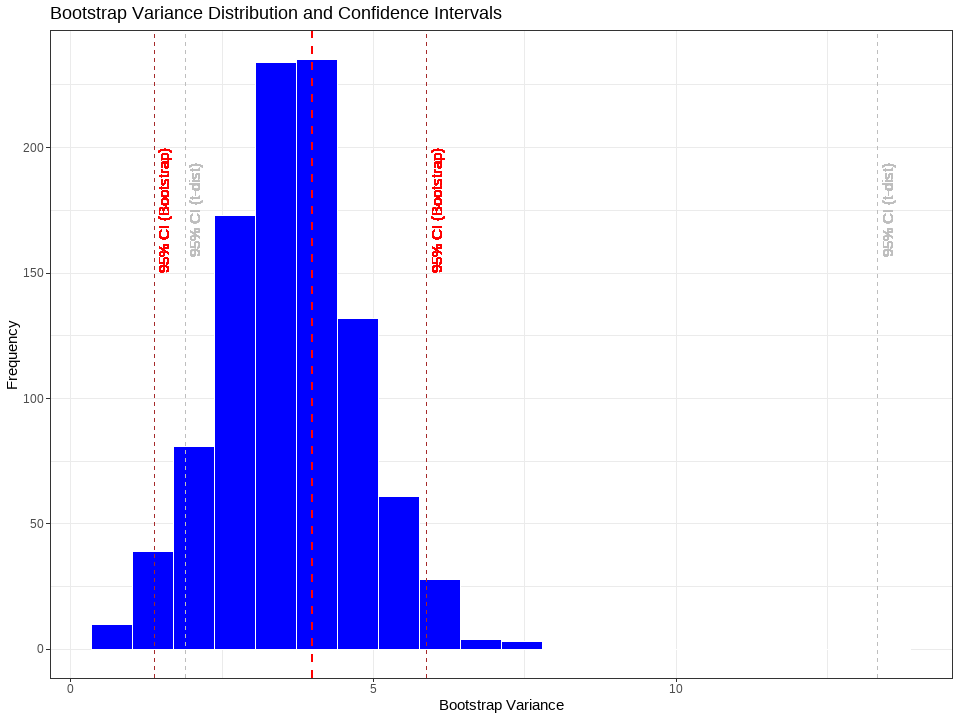

```r
p2
```

### 실습. mtcars

```r
library(boot)
#
bootstrap_statistic <- function(data, indices) {
  sample_data <- data[indices, ]
  model <- lm(mpg ~ wt, data = sample_data)
  return(coef(model))
}

# original
ori_results <- lm(mpg ~ wt, data = mtcars)

set.seed(4885)

# 1000번 resampling
results <- boot(data = mtcars, statistic = bootstrap_statistic, R = 1000)
# result
print(results)
```

```
##
## ORDINARY NONPARAMETRIC BOOTSTRAP
##
##
## Call:
## boot(data = mtcars, statistic = bootstrap_statistic, R = 1000)
##
##
## Bootstrap Statistics :
##     original  bias    std. error
## t1*    37.29  0.1869       2.367
## t2*    -5.34 -0.0892       0.723
```

```r
# estimates
bootstrapped_coefficients <- results$t
bootstrap_standard_errors <- apply(bootstrapped_coefficients, 2, sd)
# result
print(bootstrap_standard_errors)
```

```
## [1] 2.367 0.723
```

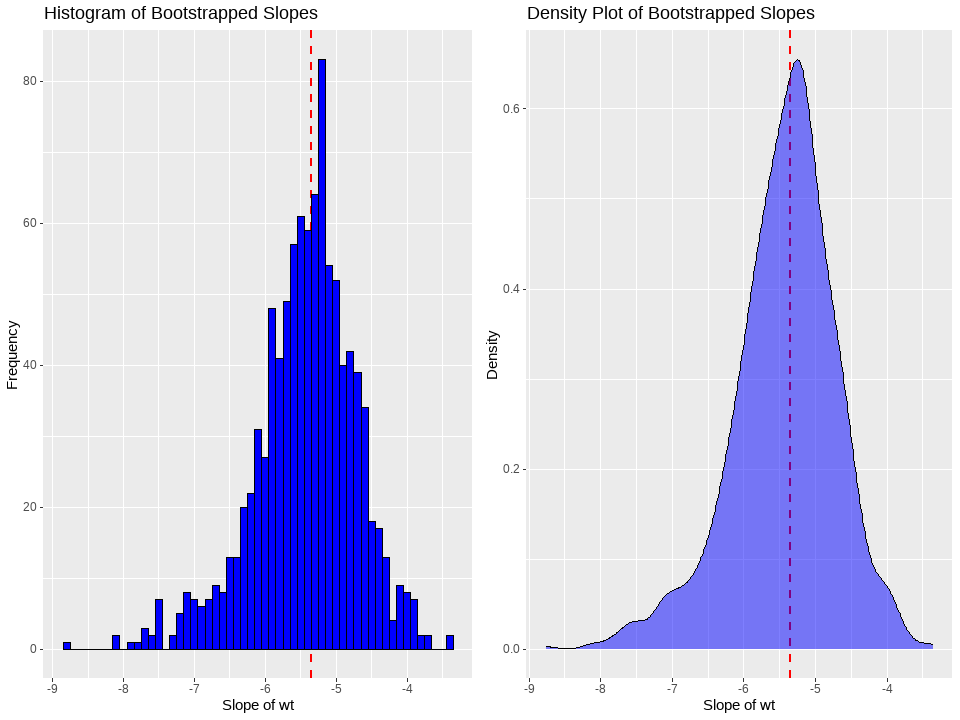

```r
# bootstrap estimates for the slope of wt
bootstrapped_slopes <- results$t[, 2]

# histogram of the bootstrapped slopes
histogram <- ggplot(data.frame(bootstrapped_slopes), aes(x = bootstrapped_slopes)) +
  geom_vline(aes(xintercept = ori_results$coefficients[2]), color = 'red', linetype = "dashed", linewidth = 1) +
  geom_histogram(binwidth = 0.1, fill = "blue", color = "black") +
  labs(title = "Histogram of Bootstrapped Slopes", x = "Slope of wt", y = "Frequency")

density_plot <- ggplot(data.frame(bootstrapped_slopes), aes(x = bootstrapped_slopes)) +
  geom_vline(aes(xintercept = ori_results$coefficients[2]), color = 'red', linetype = "dashed", linewidth = 1) +
  geom_density(fill = "blue", alpha = 0.5) +
  labs(title = "Density Plot of Bootstrapped Slopes", x = "Slope of wt", y = "Density")

# 그래프 그리기
gridExtra::grid.arrange(histogram, density_plot, ncol = 2)
```

- mtcars data를 통해 부트스트랩을 실습한 결과이다.
- 실제 wt변수의 계수 부근으로 부트스트랩 결과가 나타나는 것을 알 수 있다.

# 3. 선형 모형의 비선형 확장

- Beyond Linearity
- 비선형 확장 방법
  - 선형 기저 확장 Linear Basis Expension
    - 입력 변수를 다양한 비선형 기저 함수(basis function)를 통하여 새로운 변수를 생성하고 이를 선형 모델에 적합 시키는 방법
      - 다항 회귀, 계단 함수 회귀, 회귀 스플라인 등
        - 계단 함수는 사회과학적으로 의미가 있는 함수이다.
          - ex) 20대, 30대, 40대 등 / 크게 step up을 하는 구간을 잘 적합시킬 수 있다.
      - 방법이 직관적이고 모델 해석이 용이하며 기존의 통계적 추론 정보, 구간 추정과 가설 검정 등을 활용 가능
      - 모델의 복잡도 증가, 과적합(overfitting) 가능성이 높음
  - 평활화/스무딩 Smoothing
    - 통계 계산적 접근으로 주어진 데이터의 잡음(noise)을 줄이고 중요 패턴을 강조하는 방법
    - 이동 평균(moving average), 스플라인 스무딩(spline smoothing), 로컬 회귀(local regression) 등
      - 이동 평균 방법을 통해 주식시장에서 대략적 패턴을 파악 가능하다.
    - 잡음을 효과적으로 줄일 수 있고 복잡한 패턴도 쉽게 도출
    - 과도하게 평활화를 적용하는 경우, 데이터의 중요 정보 누락 발생
  - 커널 방법 Kernel Method
    - 데이터를 고차원 공간으로 매핑하고 해당 공간에서 선형 모델을 적합시키는 일련의 알고리즘
      - 2개의 데이터값들간의 유사성을 측정하는 커널 함수(kernel function) 사용
      - 라디얼 기저 함수(Radial Basis Function, RBF), 아노바(ANOVA) RBF, 가우시안 프로세스(Gaussian Process) 등
      - 효율적인 계산으로 복잡한 관계를 효과적으로 모델링
      - 모델의 복잡도 증가, 높은 과적합 발생 가능성 그리고 모델 해석이 어려움
  - 이런 비선형 확장 방법을 적용할 때는 Bias-Variance Trade off를 생각하면서 진행을 해야 한다.
- 그래프를 통해 형태로 이해해야 향후 연구에 도움이 될 수 있다.

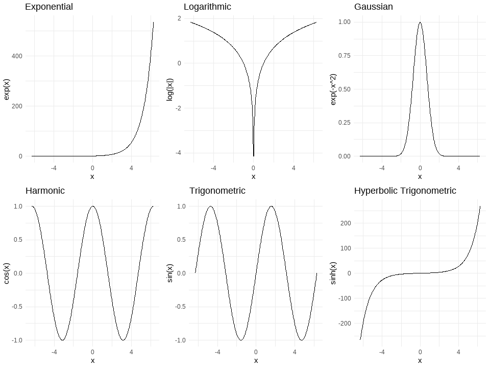

```r
x <- seq(-2*pi, 2*pi, length.out = 400)
df <- data.frame(x)

# 대표적인 기저 함수들
df$exponential <- exp(df$x) # 지수 함수
df$logarithmic <- log(abs(df$x)) # 로그 함수
df$gaussian <- exp(-df$x^2) # 가우시안 함수
df$harmonic <- cos(df$x) # 하모닉 함수
df$trigonometric <- sin(df$x) # 삼각 함수
df$hyperbolic_trigonometric <- sinh(df$x) # 쌍곡 삼각 함수

# 그래프 그리기
p1 <- ggplot(df, aes(x, exponential)) + geom_line() +
      labs(title="Exponential", y="exp(x)") + theme_minimal()
p2 <- ggplot(df, aes(x, logarithmic)) + geom_line() +
      labs(title="Logarithmic", y="log(|x|)") + theme_minimal()
p3 <- ggplot(df, aes(x, gaussian)) + geom_line() +
      labs(title="Gaussian", y="exp(-x^2)") + theme_minimal()
p4 <- ggplot(df, aes(x, harmonic)) + geom_line() +
      labs(title="Harmonic", y="cos(x)") + theme_minimal()
p5 <- ggplot(df, aes(x, trigonometric)) + geom_line() +
      labs(title="Trigonometric", y="sin(x)") + theme_minimal()
p6 <- ggplot(df, aes(x, hyperbolic_trigonometric)) + geom_line() +
      labs(title="Hyperbolic Trigonometric", y="sinh(x)") + theme_minimal()
#
grid.arrange(p1, p2, p3, p4, p5, p6, nrow = 2)
```

## 3.1. 다항 회귀

- Polynomial Regression
  - 입력 변수(들)과 반응 변수간의 비선형 관계를 적합하기 위한 표준적인 방법
  - 주의 사항
    - 가능하면 저차원의 다항 차수 d를 지향한다.
    - 계층적 구조(Hierarchical Structure)를 유지한다.
    - 가능한 한 외삽(Extrapolation)을 최소로 한다.
- 분위수 회귀 Quantile Regression
  - 기존의 회귀 방법이 평균을 추정하는 것을 보완하기 위하여 각 분위수(quantile)를 추정하는 방법
  - 이상점에 둔감하여 강건성을 갖는 회귀 추정 방법

## 3.2. 계단 함수 회귀

- Regression with Step functions
  - 입력 변수의 범위를 K > 1개의 구간(bins)으로 범주화하여 구간별 상수(constant) 함수를 적합
  - 연속형 입력 변수를 순서화된 범주형 변수로 전환

## 실습 1. Wage Data

- usa_wage.csv
  - 미국 Mid-Atlantic 지역의 직장인 3000명에 대한 급여와 관련 정보

| Variable Name | Description |
| --- | --- |
| year | 임금정보가 기록된 연도 |
| age | 근로자의 나이 |
| maritl | 혼인 상태(1. Never Married 2. Married 3. Widowed 4. Divorced 5. Separated) |
| race | 1. White 2. Black 3. Asian 4. Other indicating race |
| education | 1. < HS Grad 2. HS Grad 3. Some College 4. College Grad 5. Advanced |
| region | mid-atlantic만 존재 |
| jobclass | 직업의 종류(1. Industrial 2. Information) |
| health | 근로자 건강 수준(1. <=Good 2. >=Very Good) |
| health_ins | 근로자의 건강보험 가입 여부(1. Yes / 2. No) |
| logwage | 근로자의 임금 로그값 |
| wage | 근로자의 임금 |

- 변수 type 및 데이터 개수 파악하기

```r
Wage <- read.csv(paste0(data_path, "usa_wage.csv"))
str(Wage)
```

```
## 'data.frame':    3000 obs. of  11 variables:
##  $ year      : int  2006 2004 2003 2003 2005 2008 2009 2008 2006 2004 ...
##  $ age       : int  18 24 45 43 50 54 44 30 41 52 ...
##  $ maritl    : chr  "1. Never Married" "1. Never Married" "2. Married" "2. Married" ...
##  $ race      : chr  "1. White" "1. White" "1. White" "3. Asian" ...
##  $ education : chr  "1. < HS Grad" "4. College Grad" "3. Some College" "4. College Grad" ...
##  $ region    : chr  "2. Middle Atlantic" "2. Middle Atlantic" "2. Middle Atlantic" "2. Middle Atlantic" ...
##  $ jobclass  : chr  "1. Industrial" "2. Information" "1. Industrial" "2. Information" ...
##  $ health    : chr  "1. <=Good" "2. >=Very Good" "1. <=Good" "2. >=Very Good" ...
##  $ health_ins: chr  "2. No" "2. No" "1. Yes" "1. Yes" ...
##  $ logwage   : num  4.32 4.26 4.88 5.04 4.32 ...
##  $ wage      : num  75 70.5 131 154.7 75 ...
```

### 다항식 적합과 시각화

- 4차 다항 회귀 적합합

```r
# 'age'에 대한 'wage'의 4차 다항 회귀 적합
fit <- lm(wage ~ poly(age, 4), data = Wage)
summary(fit)
```

```
##
## Call:
## lm(formula = wage ~ poly(age, 4), data = Wage)
##
## Residuals:
##    Min     1Q Median     3Q    Max
## -98.71 -24.63  -4.99  15.22 203.69
##
## Coefficients:
##               Estimate Std. Error t value            Pr(>|t|)
## (Intercept)    111.704      0.729  153.28 <0.0000000000000002 ***
## poly(age, 4)1  447.068     39.915   11.20 <0.0000000000000002 ***
## poly(age, 4)2 -478.316     39.915  -11.98 <0.0000000000000002 ***
## poly(age, 4)3  125.522     39.915    3.14              0.0017 **
## poly(age, 4)4  -77.911     39.915   -1.95              0.0510 .
## ---
## Signif. codes:  0 '***' 0.001 '**' 0.01 '*' 0.05 '.' 0.1 ' ' 1
##
## Residual standard error: 39.9 on 2995 degrees of freedom
## Multiple R-squared:  0.0863, Adjusted R-squared:  0.085
## F-statistic: 70.7 on 4 and 2995 DF,  p-value: <0.0000000000000002
```

```r
# 적합 결과의 예측값 및 신뢰구간 계산
pred <- predict(fit, newdata = list(age = Wage$age), se = TRUE)
Wage$fit <- pred$fit
Wage$upr <- pred$fit + 1.96 * pred$se.fit
Wage$lwr <- pred$fit - 1.96 * pred$se.fit
```

```r
# 그래프 생성을 위하여 데이터를 'age'로 정렬
Wage <- Wage[order(Wage$age), ]
p1 <- ggplot(Wage, aes(x = age)) +
  geom_histogram(aes(y = ..count..), binwidth = 1) +
  geom_point(aes(y = wage)) +
  geom_line(aes(y = fit), color = lre) +
  geom_ribbon(aes(ymin = lwr, ymax = upr), alpha = 0.2) +
  labs(x = "Age", y = "Wage", title = "Polynomial(4)") +
  theme_bw()
```

- 3차 다항 회귀 적합

```r
# 'age'에 대한 'wage'의 3차 다항 회귀 적합
fit <- lm(wage ~ poly(age, 3), data = Wage)
summary(fit)
```

```
##
## Call:
## lm(formula = wage ~ poly(age, 3), data = Wage)
##
## Residuals:
##    Min     1Q Median     3Q    Max
## -99.69 -24.56  -5.22  15.10 206.12
##
## Coefficients:
##               Estimate Std. Error t value            Pr(>|t|)
## (Intercept)    111.704      0.729  153.21 <0.0000000000000002 ***
## poly(age, 3)1  447.068     39.933   11.20 <0.0000000000000002 ***
## poly(age, 3)2 -478.316     39.933  -11.98 <0.0000000000000002 ***
## poly(age, 3)3  125.522     39.933    3.14              0.0017 **
## ---
## Signif. codes:  0 '***' 0.001 '**' 0.01 '*' 0.05 '.' 0.1 ' ' 1
##
## Residual standard error: 39.9 on 2996 degrees of freedom
## Multiple R-squared:  0.0851, Adjusted R-squared:  0.0842
## F-statistic: 92.9 on 3 and 2996 DF,  p-value: <0.0000000000000002
```

```r
# 적합 결과의 예측값 및 신뢰구간 계산
pred <- predict(fit, newdata = list(age = Wage$age), se = TRUE)
Wage$fit <- pred$fit
Wage$upr <- pred$fit + 1.96 * pred$se.fit
Wage$lwr <- pred$fit - 1.96 * pred$se.fit
```

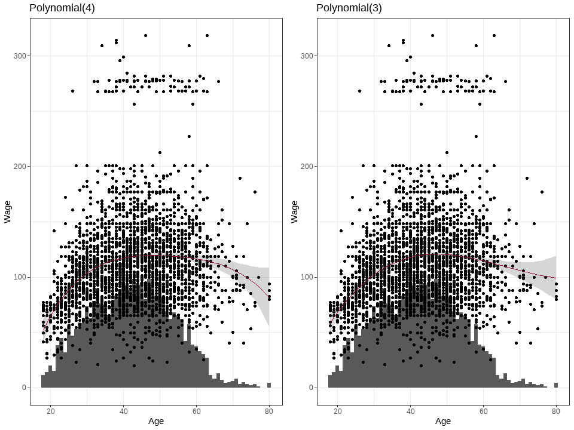

```r
# 그래프 생성을 위하여 데이터를 'age'로 정렬
Wage <- Wage[order(Wage$age), ]
p2 <- ggplot(Wage, aes(x = age)) +
  geom_histogram(aes(y = ..count..), binwidth = 1) +
  geom_point(aes(y = wage)) +
  geom_line(aes(y = fit), color = lre) +
  geom_ribbon(aes(ymin = lwr, ymax = upr), alpha = 0.2) +
  labs(x = "Age", y = "Wage", title = "Polynomial(3)") +
  theme_bw()

gridExtra::grid.arrange(p1, p2, ncol = 2)
```

- 3, 4차 다항회귀로 그래프를 그려본 결과, 연령대별로 나누어 보는 것이 더 적합해보인다.

### 분위수 회귀 Quantile Regression

```r
library(quantreg)
```

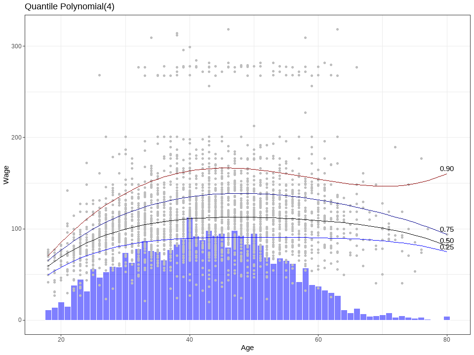

```r
taus <- c(0.25, 0.5, 0.75, 0.9)

# 분위수 이름 설정
names <- paste0("P", taus*100)

# 분위수 회귀 분석 진행
fits <- lapply(taus, function(tau) rq(wage ~ poly(age, 4), data = Wage, tau = tau))

# 예측값 계산
preds <- lapply(fits, function(fit) predict(fit, newdata = Wage))
names(preds) <- names

# 결과를 데이터 프레임으로 변환
Wage <- cbind(Wage, as.data.frame(preds))

# 데이터를 임금에 따라 정렬
Wage <- Wage[order(Wage$age), ]

# 그래프 생성
ggplot(Wage, aes(x = age)) +
  geom_histogram(aes(y = ..count..), binwidth = 1, fill = "blue", color = "white", alpha = 0.5) +
  geom_point(aes(y = wage), color = "gray") +
  geom_line(aes(y = P25), color = "blue") +
  geom_line(aes(y = P50), color = "black") +
  geom_line(aes(y = P75), color = "darkblue") +
  geom_line(aes(y = P90), color = "darkred") +
  annotate("text", x = max(Wage$age), y = tail(Wage$P25, n=1), label = "0.25", hjust = 0.5, vjust = -0.5) +
  annotate("text", x = max(Wage$age), y = tail(Wage$P50, n=1), label = "0.50", hjust = 0.5, vjust = -0.5) +
  annotate("text", x = max(Wage$age), y = tail(Wage$P75, n=1), label = "0.75", hjust = 0.5, vjust = -0.5) +
  annotate("text", x = max(Wage$age), y = tail(Wage$P90, n=1), label = "0.90", hjust = 0.5, vjust = -0.5) +
  labs(x = "Age", y = "Wage", title = "Quantile Polynomial(4)") +
  theme_bw()
```

### 계단 함수 회귀

```r
# 'age'를 10년 단위로 구분
Wage$age.cut <- cut(Wage$age, breaks = seq(10, 80, by = 10),
                    include.lowest = TRUE, right = FALSE)
# step function을 이용한 회귀 적합
fit <- lm(wage ~ age.cut, data = Wage)
# 적합 결과의 예측값 및 신뢰구간 계산
pred <- predict(fit, newdata = Wage, se = TRUE)
Wage$fit <- pred$fit
Wage$upr <- pred$fit + 1.96 * pred$se.fit
Wage$lwr <- pred$fit - 1.96 * pred$se.fit
```

```r
# Breaks point 계산
breaks_points <- seq(20, 80, by = 10)
Wage <- Wage[order(Wage$age), ]
```

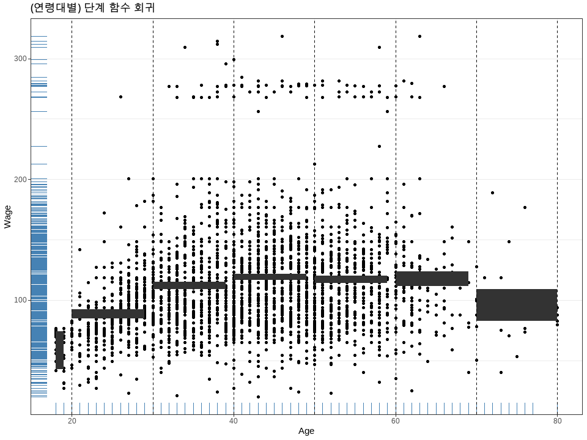

```r
# 그래프 그리기
ggplot(Wage, aes(x = age)) +
  geom_point(aes(y = wage)) +
  geom_rug(aes(y = wage), color = sbl) +
  geom_line(aes(y = fit, group = age.cut)) +
  geom_ribbon(aes(ymin = lwr, ymax = upr, group = age.cut)) +
  geom_vline(xintercept = breaks_points, linetype = "dashed") +
  labs(x = "Age", y = "Wage", title = "(연령대별) 단계 함수 회귀") +
  theme_bw()
```

- 계단 함수에 대한 분위수 회귀 적합

```r
#install.packages("quantreg")
library(quantreg)
```

```r
wage <- read.csv(paste0(data_path, "usa_wage.csv"))
wage$age.cut <- cut(wage$age, breaks = seq(10, 80, by = 10),
                    include.lowest = TRUE, right = FALSE)
taus <- c(0.25,0.5,0.75,0.9)
names <- paste0('PQ', taus*100)
fits <- lapply(taus, function(tau) rq(wage~age.cut,
                                       data=wage, tau = tau))
```

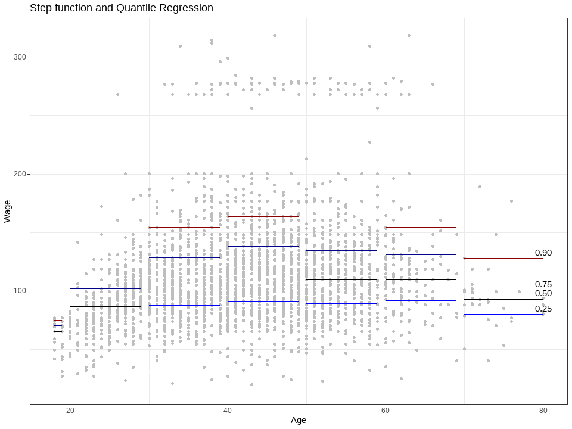

```r
preds <- lapply(fits, function(fit) predict(fit, newdata=wage))
names(preds) <- names

wage <- cbind(wage, as.data.frame(preds))
wage <- wage[order(wage$age),]

ggplot(wage, aes(x=age))+
  geom_point(aes(y=age),
                 color='white', pch=1, size=0.9)+
  geom_point(aes(y=wage),
             color='gray')+
  geom_line(aes(y=PQ25, group=age.cut), color='blue')+
  geom_line(aes(y=PQ50, group=age.cut), color='black')+
  geom_line(aes(y=PQ75, group=age.cut), color='darkblue')+
  geom_line(aes(y=PQ90, group=age.cut), color='darkred')+
  annotate('text', x=max(wage$age), y=tail(wage$PQ25, n=1),
           label='0.25', hjust=0.5, vjust=-0.5)+
  annotate('text', x=max(wage$age), y=tail(wage$PQ50, n=1),
           label='0.50', hjust=0.5, vjust=-0.5)+
  annotate('text', x=max(wage$age), y=tail(wage$PQ75, n=1),
           label='0.75', hjust=0.5, vjust=-0.5)+
  annotate('text', x=max(wage$age), y=tail(wage$PQ90, n=1),
           label='0.90', hjust=0.5, vjust=-0.5)+
  labs(x='Age', y='Wage', title='Step function and Quantile Regression')+
  theme_bw()
```

- 분위수 회귀에 의한 각 연령대별 분위수 예측값

```r
wage_table <- wage %>% group_by(age.cut) %>% summarize(Q25=mean(PQ25), Q50=mean(PQ50), Q75=mean(PQ75), Q90=mean(PQ90))

library(kableExtra)

kable(wage_table, "html") %>%
  kable_styling(full_width = TRUE)
```

| age.cut | Q25 | Q50 | Q75 | Q90 |
| --- | --- | --- | --- | --- |
| [10,20) | 49.6 | 65.1 | 70.5 | 75 |
| [20,30) | 72.2 | 86.7 | 101.8 | 119 |
| [30,40) | 87.9 | 104.9 | 128.7 | 155 |
| [40,50) | 90.7 | 112.6 | 138.3 | 164 |
| [50,60) | 89.5 | 109.8 | 134.7 | 160 |
| [60,70) | 91.7 | 109.8 | 131.0 | 155 |
| [70,80] | 79.9 | 92.9 | 100.8 | 128 |

- 임금과 같은 이상점이 많은 사회 현상을 모델에 적용하기 위해서는 step function과 Quantile Regression으로 접근 하는 것이 바람직해보인다.

## 3.3. 회귀 스플라인

- 회귀 스플라인 Regression Splines
  - 모수가 줄어드는 아니지만 구간마다의 간단한 모형을 적합할 수 있는 좋은 모델이다.
  - 입력 변수의 전체 범위에 다항식을 적합하는 대신에 입력 변수의 범위를 K > 1개의 너트(Knot)를 이용하여 중복되지 않은 구간으로 구분하고 각 구간별로 다항 회귀를 적합하는 방법
  - 더 많은 너트(경계)를 사용할수록 더 융통성있는 비선형 함수 구현 가능
  - 다항 회귀와 계단함수 회귀의 확장으로 보다 융통성 있는 비선형 함수 적합 가능
  - 각 너트(Knot)에서 연속 또는 불연속의 조건 적용 가능능
- 자연 스플라인 Natural Splines
  - 공학에서 많이 사용하는 방법이다.
  - 회귀 스플라인의 응요으로 양쪽 끝, (min(x), $t_1$)과 ($t_k$, max(x)),에서 추가적인 선형 제약 조건을 반영한다.
  - 회귀 스플라인의 경우보다 더욱 안정적인 추정값을 제공하며, 양 끝에서 더 좁은 신뢰구간을 제공하는 특징이 있다.
- B-스플라인 B-Splines
  - 회귀 스플라인을 일반화한 방법으로 너트에 의하여 결정되는 각 구간에서 다양한 B-스플라인 기본 함수를 사용함으로써 복잡한 비선형 패턴 적합에 유용
  - 회귀 스플라인보다 더 일반적이고 융통성 있는 적합을 가능하게 하며, 너트사이에서의 연속성을 보장함으로써 데이터 전범위에서 부드러운 적합 가능
  - 다항식의 차수 d와 너트의 수 K는 모델의 복잡도와 융통성을 결정한다.
- 너트의 위치와 개수 선택
  - 가장 좋은건 사전에 정해져 있으면 좋다.
  - 문제에 대한 사전 지식을 바탕으로 일정한 위치와 개수 지정
  - 많은 변화가 존재하는 영역에 더 많은 너트를 배치하여 모델의 유연성 확보
  - 데이터의 분위수 기준으로 균등하게 자동 지정
    - 너트의 위치와 개수에 대한 주관적인 판단을 최소화하고 데이터의 전체 영역에서의 모델의 일관성 유지
    - 입력 변수가 2개 이상인 경우에는 각 변수별로 지정할 수 있지만, 일반적으로 동일한 너트의 수를 모든 변수에 지정

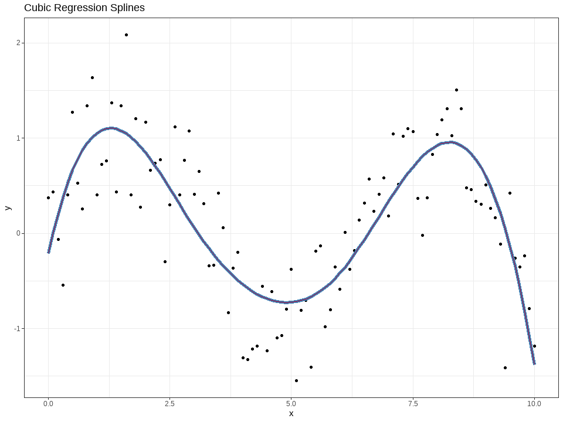

```r
library(splines)
data <- read.csv(paste0(data_path, "/rcspline.csv"))

# Knots 설정
knots <- c(3, 6)

x <- data$input
y <- data$target

# cubic regression spline의 Basis 설정
basis <- cbind(1, x, x^2, x^3,
               pmax(x - knots[1], 0)^3,
               pmax(x - knots[2], 0)^3)

# 모델 적합
fit.o <- lm(y ~ basis - 1, data = data)

# B-splines function 적용의 예측값
fit.b <- lm(y ~ bs(x, degree = 3, knots = c(3, 6)), data = data)
data$pred.o <- predict(fit.o)
data$pred.b <- predict(fit.b)

#
ggplot(data, aes(x, y)) +
    geom_point() +
    geom_line(aes(x, pred.b), color = sbl, linewidth = 2) +
    geom_line(aes(x, pred.o), color = lre) +
    labs(title = "Cubic Regression Splines") +
    theme_bw()
```

- 자연 스플라인 Natural Splines

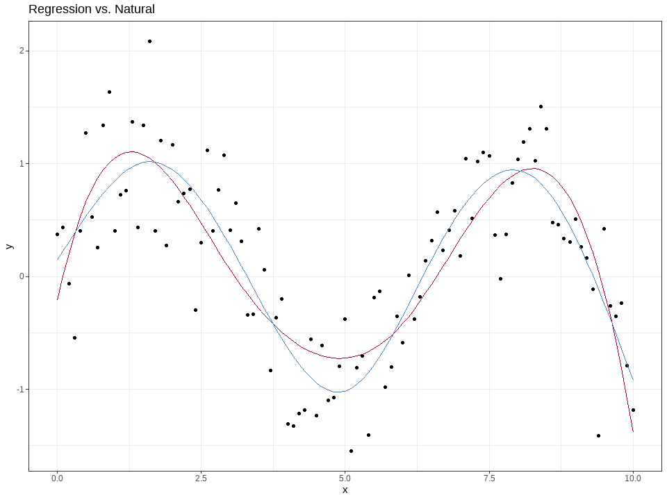

```r
library(splines)
data <- read.csv(paste0(data_path, "rcspline.csv"))
# Knots 정의
knots <- c(3, 6)
x <- data$input
y <- data$target
fit.b <- lm(y ~ bs(x, degree = 3, knots = c(3, 6)),
            data = data)
fit.n <- lm(y ~ ns(x, df = 6), data = data)
data$pred.n <- predict(fit.n)
data$pred.b <- predict(fit.b)
#
ggplot(data, aes(x, y)) +
  geom_point() +
  geom_line(aes(x, pred.b), color = lre) +
  geom_line(aes(x, pred.n), color = sbl) +
  labs(title = "Regression vs. Natural") +
  theme_bw()
```

- 파란색 실선을 살펴보면 데이터의 양쪽 한계에서 다항식의 불완정성을 보완하는 것을 알 수 있다.
  - 이를 통해 기본적인 회귀 스플라인의 경우보다 더욱 안정적인 추정값을 제공하는 것을 알 수 있다.
- B-spline

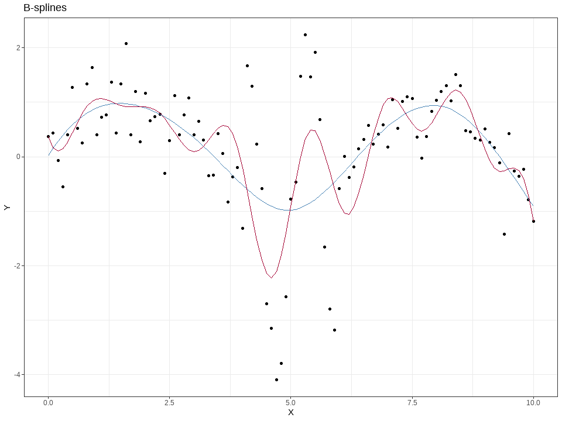

```r
library(splines)
data <- read.csv(paste0(data_path, "b_splines.csv"))
#
fit1 <- lm(y ~ bs(x, df = 8, degree = 3), data = data)
fit2 <- lm(y ~ bs(x, df = 15, degree = 3), data = data)
ggplot(data, aes(x = x, y = y)) +
  geom_point() +
  geom_line(aes(y = predict(fit1)), colour = sbl) +
  geom_line(aes(y = predict(fit2)), colour = lre) +
  labs(title = "B-splines",
       x = "X",
       y = "Y",
       color = "df of B-Spline") +
  scale_color_manual(values = c(sbl, lre), labels = c("B-splines8", "B-splines15")) +
  theme_bw()
```

## 3.4. 평활화 스플라인

- Smoothing Splines
  - 평활 함수 g(x)와 평활 페널티(smoothness penalty)하에서 잔차 제곱합(Residual Sum of Squares; RSS)을 최소화하는 비선형 함수를 적합
  - 고유한 모든 x값을 너트로 하는 자연 3차 스플라인으로, 너트의 위치와 개수 지정 불필요하다는 특징이 있다.
  - 일반적으로 데이터로부터 복잡한 모델이 필요한 근거를 찾지 못한다면, 간단한 모델을 선택하는 것이 바람직 하다.

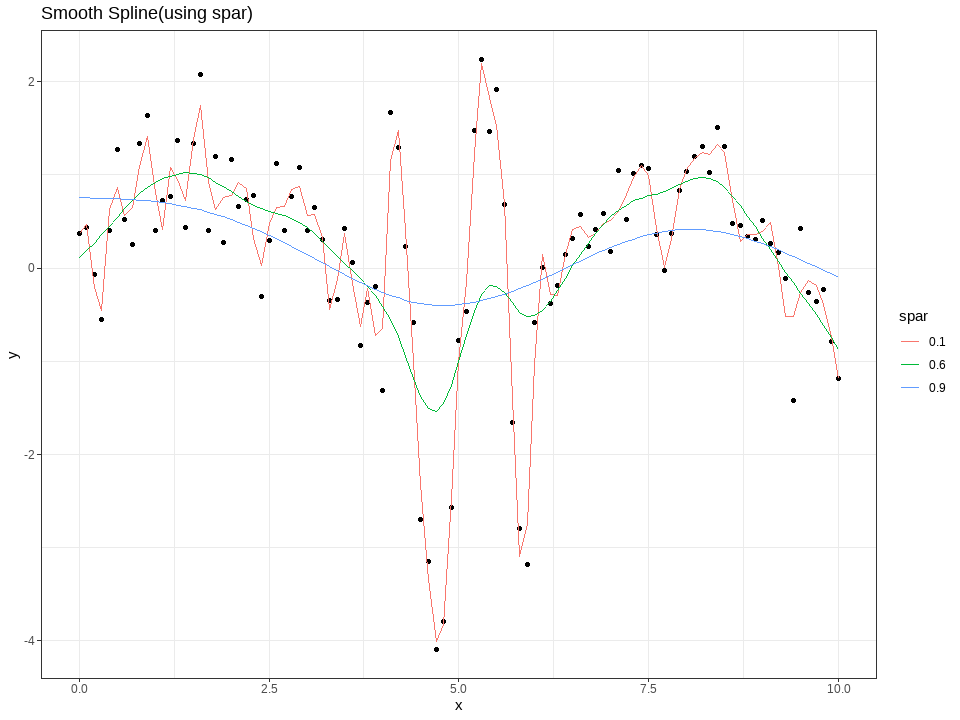

```r
library(purrr)

# 다양한 lambda 값을 가미에 대한 스무스 스플라인 계산
data <- read.csv(paste0(data_path, "/b_splines.csv"))

spar_values <- c(0.1, 0.6, 0.9)

x <- data$x
y <- data$y

splines <- map_df(
  spar_values,
  ~ data.frame(x = x,
               y = predict(smooth.spline(x, y, spar = .x), x)$y,
               spar = .x)
)

# 그래프 그리기
ggplot(data, aes(x = x, y = y)) +
  geom_point() +
  geom_line(data = splines, aes(x = x, y = y,
                                color = as.factor(spar))) +
  labs(title = "Smooth Spline(using spar)", color = "spar") +
  scale_color_discrete(name = "spar") +
  theme_bw()
```

- 0.1과 0.9 사이에 0.6정도가 적절하게 스무딩 파라미터로 보인다.
  - 0.1로 지정했을 때는 과적합된 것으로 보인다.
  - 0.9로 지정했을 때는 과소적합된 것으로 보인다.

## 3.5. 로컬 회귀

- Local Regression
  - 입력 변수의 개별 $X_0$의 근처에 있는 일부 데이터만을 이용하여 적합하는 방법으로 비선형 함수를 적합
- LOESS; Locally Estimated Scatterplot Smoothing
  - 데이터의 복잡한 비선형 패턴에 대한 부드러운 곡선을 제공하기 위한 비모수적 방법
  - 기준 데이터 값 주변의 부분 집합에서 다항식을 적합
  - 가중치 함수를 사용하여 근접한 데이터 값들에 더 높은 가중치를 부여
- LOWESS; Locally Weighted Estimated Scatterplot Smoothing
  - LOESS와 유사한 방법인데 LOWESS는 1차 다항식을 적합한다.
  - 기준이 되는 데이터 값의 주변의 작은 부분 집합에서 간단한 모델을 적합시키는 방식으로 비선형 패턴 적합
  - 각 예측값은 국소적으로 가중치가 부여된 지역 최소 제곱 추정에 기초하여 결정

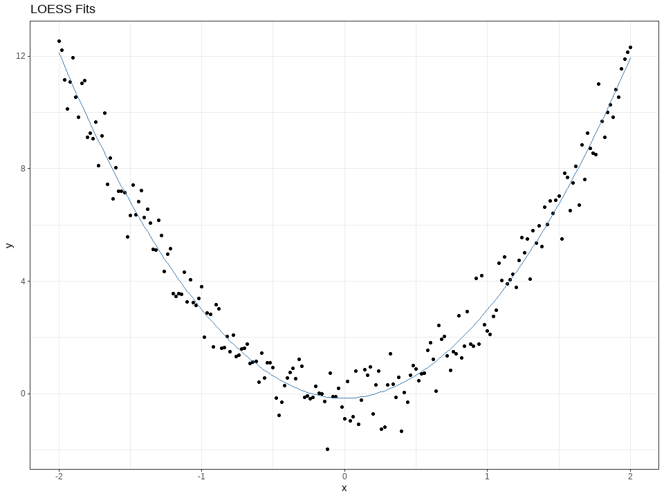

```r
# stats::lowess(model, span = α, degree = α)
# α ∈ (0,1)  그리고 d = (일반적으로) 1, 2^12
# α의 값이 클수록 전역 데이터를 사용하고, 그 값이 작을수록 지역 데이터를 사용

data <- read.csv(paste0(data_path, "/std_noise.csv"))
# 모델 적합
loess_fit <- loess(y ~ x, data = data, span = 0.75)
#그래프 그리기
ggplot(data, aes(x = x, y = y)) +
  geom_point() +
  geom_line(aes(y = predict(loess_fit, newdata = data)), color = sbl) +
  labs(title = "LOESS Fits",
       x = "x", y = "y") +
  theme_bw()
```

- LOESS vs. LOWESS 비교

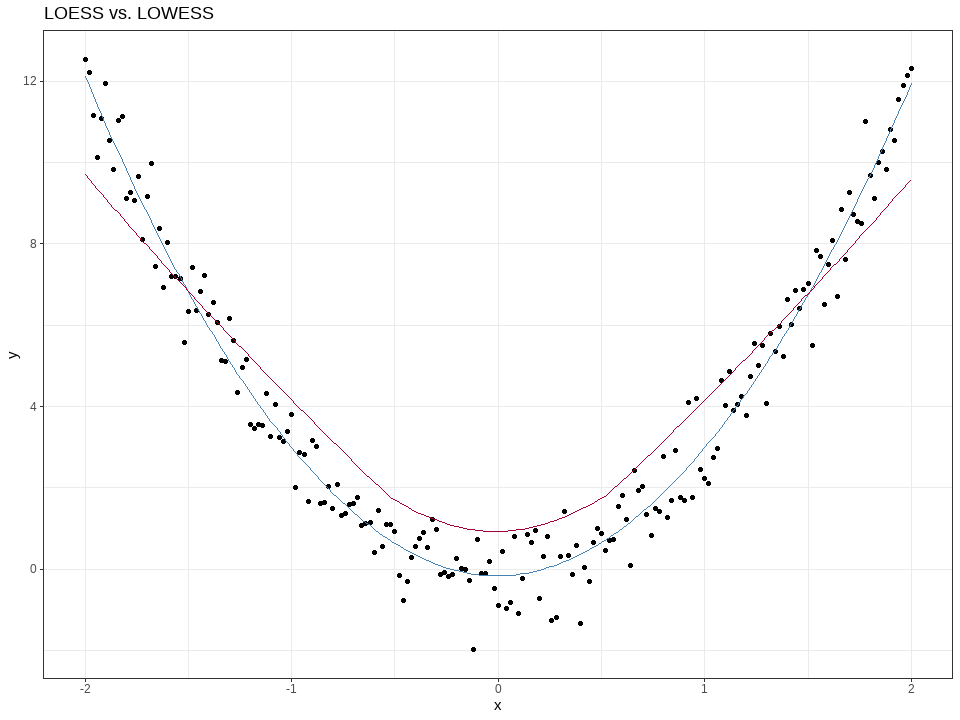

```r
# stats::lowess(x, y, f = α)
# · f ∈ (0,1): 로컬 스무딩에 사용되는 데이터의 비율

data <- read.csv(paste0(data_path, "/std_noise.csv"))
# 각각 모델 적합
loess_fit <- loess(y ~ x, data = data, span = 0.75)
lowess_fit <- lowess(data$x, data$y, f = 0.75)
# 그래프 그리기
ggplot(data, aes(x = x, y = y)) +
  geom_point() +
  geom_line(aes(y = predict(loess_fit, newdata = data)), color = sbl) +
  geom_line(aes(y = lowess_fit$y), color = lre) +
  labs(title = "LOESS vs. LOWESS",
       x = "x", y = "y") +
  theme_bw()
```

- 다항식의 차수를 조절할 수 있는 LOESS 모델이 좀더 양극단에서 데이터에 fitting되고 있다.

## 3.6. 커널 함수

- Kernel Regression

```r
# install.packages("np")
library(np)
```

```r
library(ggplot2)
#
data <- read.csv(paste0(data_path, "std_cycle2.csv"))

# 커널 목록
kernels <- c("gaussian", "truncated", "epanechnikov", "uniform")

# 빈 데이터 프레임 초기화
plot_data <- data.frame()

# 각 커널에 대한 회귀 모델을 적합하고 예측값 계산
for (kernel in kernels) {
  kernel_model <- npreg(y ~ x, data = data, ckertype = kernel)
  newdata <- data.frame(x = data$x)
  predictions <- predict(kernel_model, newdata = newdata)
  temp_data <- data.frame(x = newdata$x, y = predictions, kernel = kernel)
  plot_data <- rbind(plot_data, temp_data)
}
```

[output not shown]

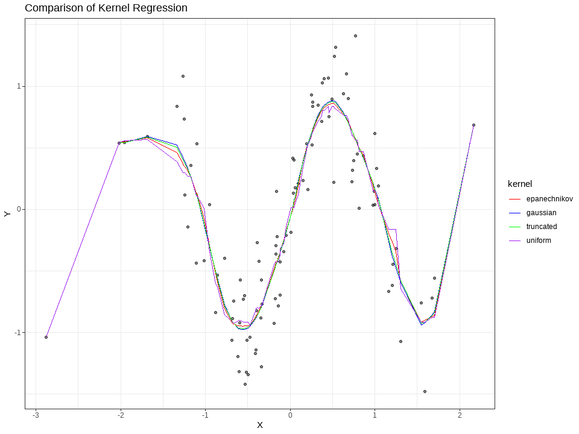

```r
# 그래프 그리기
ggplot() +
  geom_point(data = data, aes(x = x, y = y), alpha = 0.5) +
  geom_line(data = plot_data, aes(x = x, y = y, color = kernel)) +
  labs(title = "Comparison of Kernel Regression",
       x = "X", y = "Y") +
  scale_color_manual(values = c("red", "blue", "green", "purple")) +
  theme_bw()
```

## 3.7. KNN회귀

- K-Nearest Neighbors regression
  - knn을 사용할 때는 해당 도메인에서 사용하는 distance를 사용하는 것이 일반적으로 좋음
    - 모든 방법을 적용하기에는 시간/비용이 낭비된다.
  - 지도 학습 알고리즘 중 하나로, 분류와 회귀 모두에 사용될 수 있는 비모수적 방법
    - 따라서 모형 가정을 하지 않아도 된다.
  - 예측하려는 지점 근처의 k개 가장 가까운 훈련 데이터를 선택
  - 선택된 k개의 이웃 데이터 포인트의 평균을 계산하여 예측값으로 사용
  - 올바른 k값의 선택과 적절한 거리 계산 방법이 모델의 성능에 중요한 영향을 미친다.

```r
library(FNN)
```

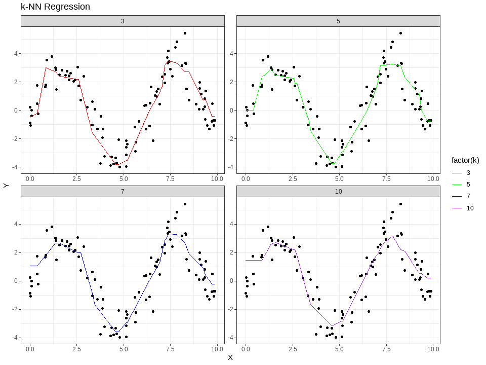

```r
# 데이터 불러오기기
data <- read.csv(paste0(data_path, "std_cycle3.csv"))
set.seed(4885)
# 훈련 및 테스트 데이터 분할
n <- nrow(data)
train_idx <- sample(1:n, 0.7 * n)
train_data <- data[train_idx, ]
test_data <- data[-train_idx, ]

# KNN
get_knn_pred <- function(train, test, k) {
  knn_pred <- knn.reg(train = data.frame(x = train$x),
                      test = data.frame(x = test$x),
                      y = train$y, k = k)
  test$pred <- knn_pred$pred
  test$k <- k
  return(test)
}

# k값 설정
k_values <- c(3, 5, 7, 10)

#
predictions_list <- lapply(k_values, function(k) {
  get_knn_pred(train_data, test_data, k)
})

#
all_predictions <- do.call(rbind, predictions_list)

# 그래프 그리기
ggplot(data, aes(x = x, y = y)) +
  geom_point() +
  geom_line(data = all_predictions, aes(x = x, y = pred, group = factor(k), color = factor(k))) +
  facet_wrap(~k, scales = "free") +
  labs(title = "k-NN Regression", x = "X", y = "Y") +
  theme_bw() +
  scale_color_manual(values = c("red", "green", "blue", "purple"))
```

[output not shown]

- 하이퍼파라미터
  - 학습 프로세스의 조정을 위하여 외부 설정되는 값으로 학습 전에 사용자가 설정해야 하는 값을 말하며, 이는 학습 데이터에 의해 추정되지 않는다.
  - 교차 검증 등의 다른 방법에 의하여 최적화되어야 한다.

# 4. 정규화/규제

- Regularization
  - 과적합(Overfitting)을 방지하기 위하여 모델의 복잡성을 제어하는 방법
- 대표적인 방법
  - 축소 Shrinkage(Penalized Methods)
    - 모델의 파라미터의 값을 축소시키기 위하여 손실 함수에 페널티(penalty) 항을 추가하여 파라미터에 대한 제약을 부과
      - L1(Lasso), L2(Ridge), Elastic Net 등
  - 조기 종료 Early Stopping
    - 과적합 방지를 위하여 훈련 손실과 검증 손실의 변화를 모니터링하여 검증 손실이 증가하는 시점에서 훈련을 조기 종료
  - 일부 제거 Dropout
    - 모델의 일부 구성 요소를 무작위로 비활성화하여 모델의 복잡성을 제한하고 일반화 성능 향상 유도
- 축소 방법은 객관적인 지표가 될 수 있으나 조기 종료 방법과 일부 제거 방법은 매우 휴리스틱한 방법이다.

## 4.1. 정규화 적용을 위한 준비

- 표준화 방법
  - scale(): 모든 연속형 예측 변수의 표준화
- 범주형 변수의 가변수화
  - One-hot Encoding

```r
# 데이터 생성
data <- data.frame(
  x1 = rnorm(100, mean = 50, sd = 10),
  x2 = rnorm(100, mean = 100, sd = 20),
  x3 = rnorm(100, mean = 0, sd = 5)
)
# 표준화
standized_data <- as.data.frame(scale(data))
```

- 개별 연속형 변수의 표준화

```r
data$x1 <- scale(data$x1)
```

- 개별 연속형 변수의 로버스트 표준화

```r
data$x1 <- (data$x1 - median(data$x1)) / IQR(data$x1)
```

- One-hot Encoding

```r
categorical <- c("A", "B", "C")
cat_dummy <- model.matrix(~categorical -1)
cat_dummy
```

```
##   categoricalA categoricalB categoricalC
## 1            1            0            0
## 2            0            1            0
## 3            0            0            1
## attr(,"assign")
## [1] 1 1 1
## attr(,"contrasts")
## attr(,"contrasts")$categorical
## [1] "contr.treatment"
```

## 4.2. 능형 회귀

- Ridge Regression
  - 회귀 모델에 절편을 제외한 회귀 계수의 $L_2$ 노름(norm)을 페널티로 하는 정규화 방법
    - 변수 간의 다중공선성에 덜 민감하게 모델을 학습
    - L2 노름은 미분가능하므로 경사하강 알고리즘을 사용하여 효율적으로 최적화가 가능하다.
    - $\lambda$가 증가함에 따라 회귀 계수를 0에 가깝게 만드는 경향이 있지만, 완전히 0이 되지 않는다는 특징이 있다.
- 1-Sandard Error Rule
  - 모델 복잡도와 예측 오류 사이의 균형을 고려
    - 여러 모델들 중에서 예측 오류가 가장 낮은 모델 선택
    - 해당 모델의 예측 오류의 표준 오차 계산
    - 가장 낮은 예측 오류 + 1표준 오차 범위 내에 있는 가장 단순한 모델을 선택
  - 가장 낮은 예측 오류를 가진 모델이 항상 최적의 모델이라고는 할 수 없다.

### 실습. Sensing Data within 5 Min.s

- regularization_1.csv
  - 총 50개의 입력 변수에 대한 결과(gap)

```r
# 데이터 불러오기
case <- read.csv(paste0(data_path, "regularization_1.csv"))

# 데이터 준비와 표준화
library(glmnet)
```

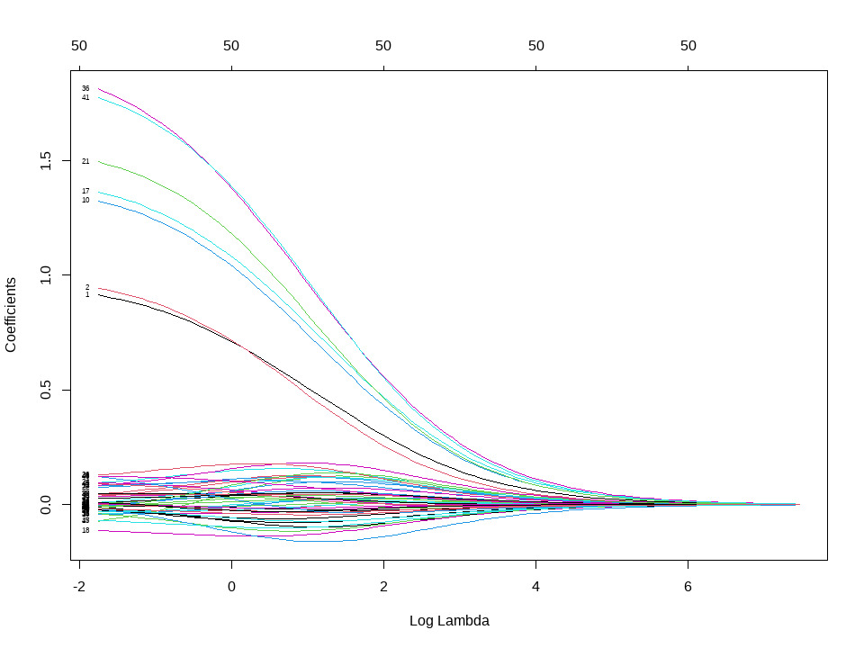

```r
# x1 ~ x50 열을 matrix로 변환
X0 <- as.matrix(case[, 1:50])
y <- case$gap

# 연속형 변수 표준화
X <- scale(X0)

# Ridge Regression 적합
ridge.mod <- glmnet(X, y, alpha = 0)
plot(ridge.mod, xvar="lambda", label=TRUE)
```

- lambda 값이 증가할수록 대부분이 회귀 계수가 0에 가까워 지는 것을 알 수 있다.
  - L2 규제이기때문에 0은 되지 않는다.
- 교차 검증 및 최적 $\lambda$ 추정

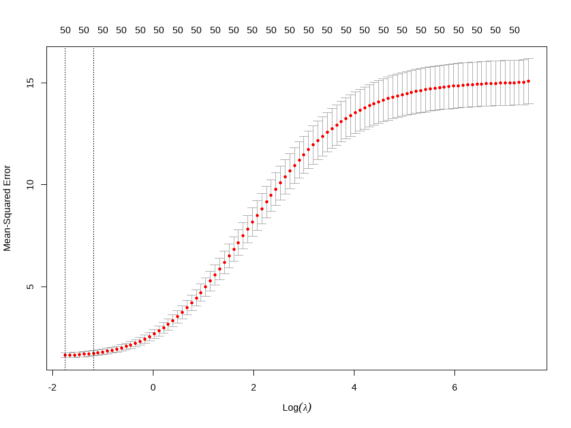

```r
# 교차 검증, k = 10
cv.ridge <- cv.glmnet(X, y, alpha = 0)
plot(cv.ridge)
```

```r
# 최적 lambda 결정
lambda_opt <- cv.ridge$lambda.min
lambda_1se <- cv.ridge$lambda.1se
c(lambda_opt, lambda_1se)
```

```
## [1] 0.175 0.305
```

- 모델 학습 및 예측: MSE 계산 및 비교

```r
# 최적 lambda에 대한 모델 학습
model_opt <- glmnet(X, y, lambda = lambda_opt)
# 1SE 내의 최소 복잡성을 갖는 lambda에 대한 모델 학습
model_1se <- glmnet(X, y, lambda = lambda_1se)
# 두 모델을 이용한 예측 - 실무에서는 newx = Test Data
predictions_opt <- predict(model_opt, newx=X)
predictions_1se <- predict(model_1se, newx=X)
# MSE 계산
mse_opt <- mse(y, predictions_opt)
mse_1se <- mse(y, predictions_1se)
# MSE 확인
c(mse_opt, mse_1se)
```

```
## [1] 1.18 1.69
```

- 최적 $\lambda$ 로 적용 했을 때 mse값이 더 낮은 것을 알 수 있다.
- 잔차 계산 및 비교

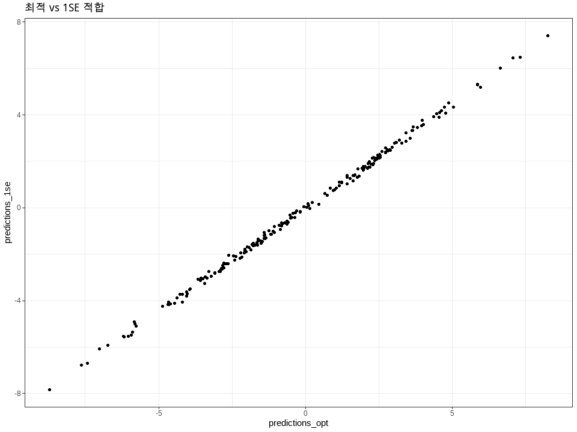

```r
# 표준화된 잔차
std_res_opt <- (y - predictions_opt) / sd(y - predictions_opt)
std_res_1se <- (y - predictions_1se) / sd(y - predictions_1se)

# 잔차 정의 및 그림
res_data <- data.frame(y,
                       predictions_opt,
                       predictions_1se,
                       std_res_opt,
                       std_res_1se)

# 그래프
res_data %>% ggplot() +
  geom_point(aes(predictions_opt, predictions_1se)) +
  labs(title = "최적 vs 1SE 적합") + theme_bw()
```

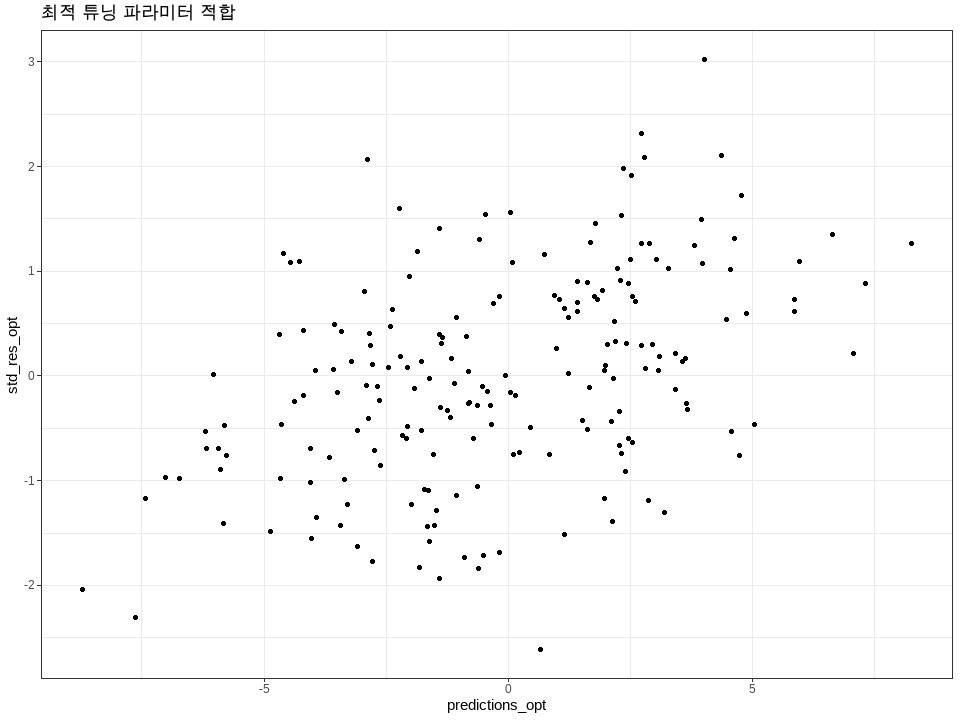

```r
res_data %>% ggplot() +
  geom_point(aes(predictions_opt, std_res_opt)) +
  labs(title = "최적 튜닝 파라미터 적합") + theme_bw()
```

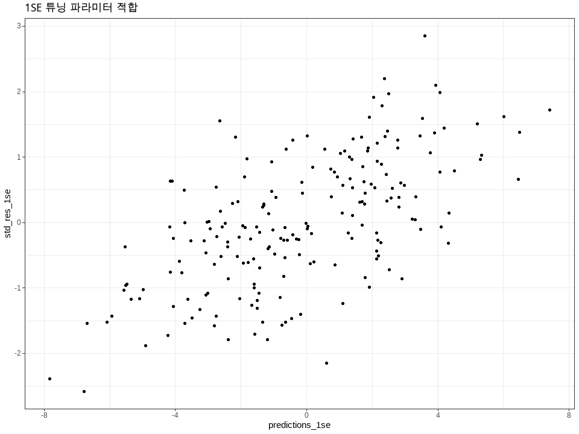

```r
res_data %>% ggplot() +
  geom_point(aes(predictions_1se, std_res_1se)) +
  labs(title = "1SE 튜닝 파라미터 적합") + theme_bw()
```

## 4.3. LASSO 회귀

- Least Absolute Shrinkage and Selection Operator
  - 절편을 제외한 회귀 계수의 $L_1$ 노름을 페널티로 하는 정규화 방법
    - Ridge와 달리 특정 계수를 완전히 0으로 축소할 수 있어, 변수 선택(variable selection)의 역할 가능
    - $L_1$노름은 그 자체로 미분이 불가능하지만, 좌표 경사 하강법(coordinate gradient descent) 등의 방법으로 최적화 가능
    - 간단한(sparse) 모델을 제시하여 결과의 해석 용이
- LASSO 정규화 경로 LASSo Regulation Paths
  - $\lambda$가 증가함에 따라 일부 회귀 계수는 급격하게 0이 되어, 변수 선택의 효과 발생
  - 일부 회귀 계수가 급격히 0으로 접근하더라도 다른 회귀 계수는 영향을 받지 않을 수 있음
- Ridge vs. LASSO Regulation Paths

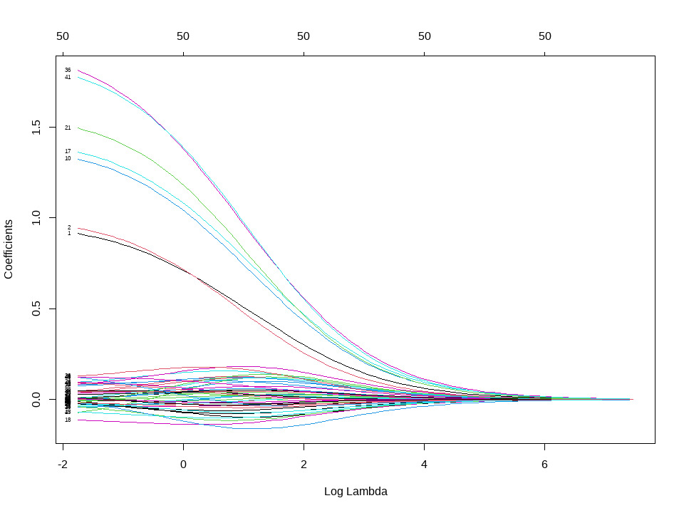

```r
# 데이터 불러오기
case <- read.csv(paste0(data_path, "regularization_1.csv"))

# 데이터 준비와 표준화
library(glmnet)
# x1 ~ x50 열을 matrix로 변환
X0 <- as.matrix(case[, 1:50])
y <- case$gap

# 연속형 변수 표준화
X <- scale(X0)

# Ridge vs Lasso
ridge.mod <- glmnet(X, y, alpha = 0)
plot(ridge.mod, xvar="lambda", label=TRUE)
```

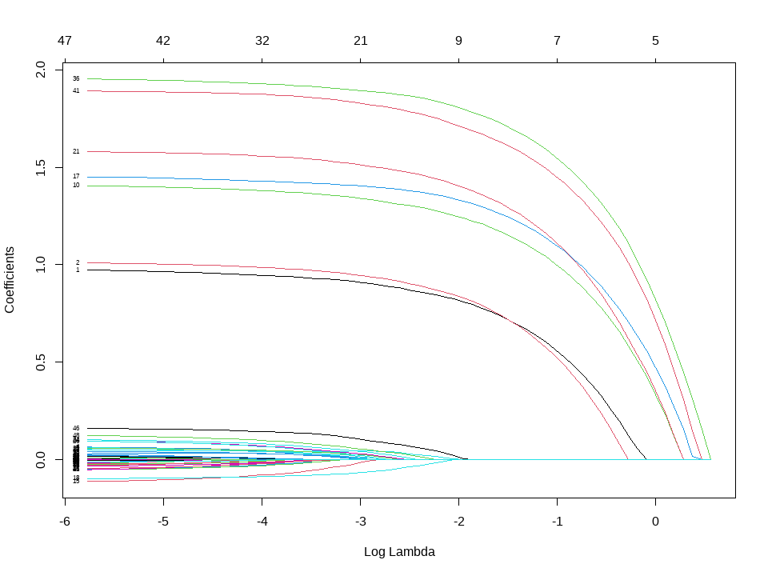

```r
lasso.mod <- glmnet(X, y, alpha = 1)
plot(lasso.mod, xvar="lambda", label=TRUE)
```

- LASSO 모델은 계수가 급격하게 0으로 변하는 것을 알 수 있다.
- Ridge 모델은 LASSO보다는 smooth하게 0 근처로 간다.

### 실습. Lasso regression

- regularization_1.csv

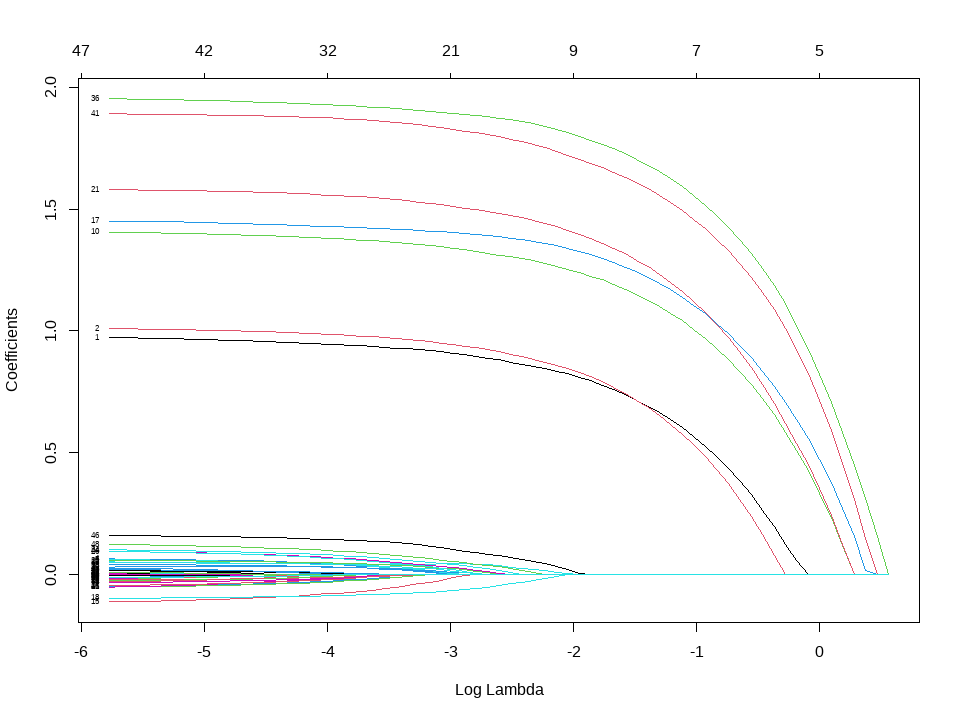

```r
# 데이터 불러오기
case <- read.csv(paste0(data_path, "regularization_1.csv"))

# 데이터 준비와 표준화
library(glmnet)

# x1 ~ x50 열을 matrix로 변환
X0 <- as.matrix(case[, 1:50])
y <- case$gap

# 연속형 변수 표준화
X <- scale(X0)
# lasso Regression 적합
lasso.mod <- glmnet(X, y, alpha = 1)
plot(lasso.mod, xvar="lambda", label=TRUE)
```

- 교차 검증 및 최적 $\lambda$ 추정

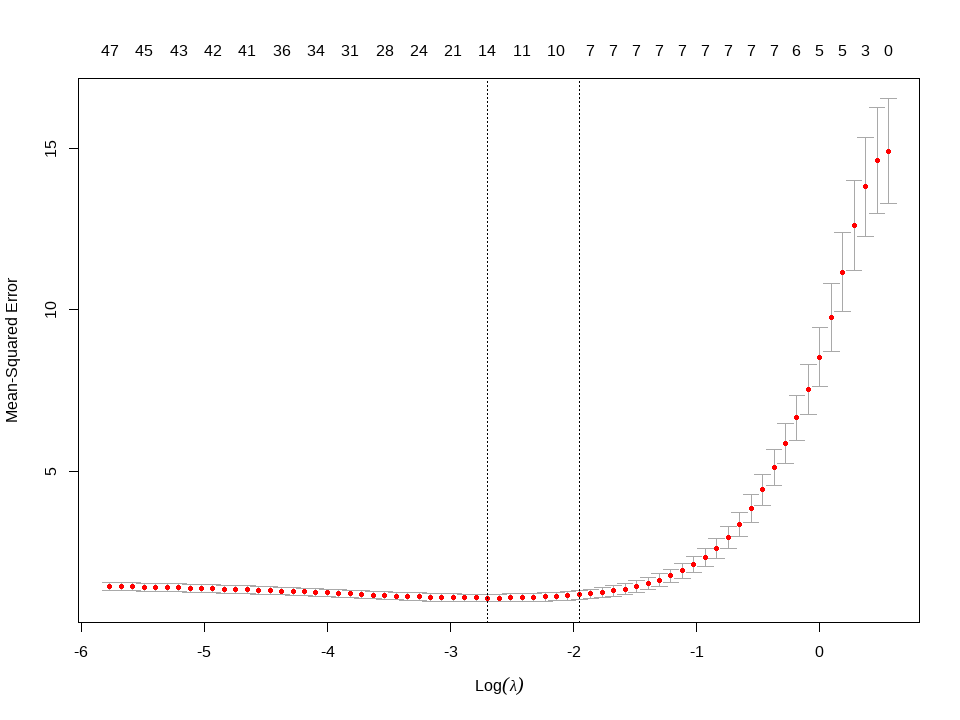

```r
# 교차 검증, k = 10
cv.lasso <- cv.glmnet(X, y, alpha = 1)
plot(cv.lasso)
```

```r
# 최적 lambda 결정
lambda_opt <- cv.lasso$lambda.min
lambda_1se <- cv.lasso$lambda.1se
c(lambda_opt, lambda_1se)
```

```
## [1] 0.0673 0.1417
```

- 모델 학습 및 예측: MSE 계산 및 비교

```r
# 최적 lambda에 대한 모델 학습
model_opt <- glmnet(X, y, lambda = lambda_opt)

# 1SE 내의 최소 복잡성을 갖는 lambda에 대한 모델 학습
model_1se <- glmnet(X, y, lambda = lambda_1se)

# 두 모델을 이용한 예측 - 실무에서는 newx = Test Data
predictions_opt <- predict(model_opt, newx=X)
predictions_1se <- predict(model_1se, newx=X)

# MSE 계산
mse_opt <- mse(y, predictions_opt)
mse_1se <- mse(y, predictions_1se)

# MSE 확인
c(mse_opt, mse_1se)
```

```
## [1] 0.928 1.098
```

- 최적 $\lambda$ 로 적용 했을 때 mse값이 더 낮은 것을 알 수 있다.
- 잔차 계산 및 비교

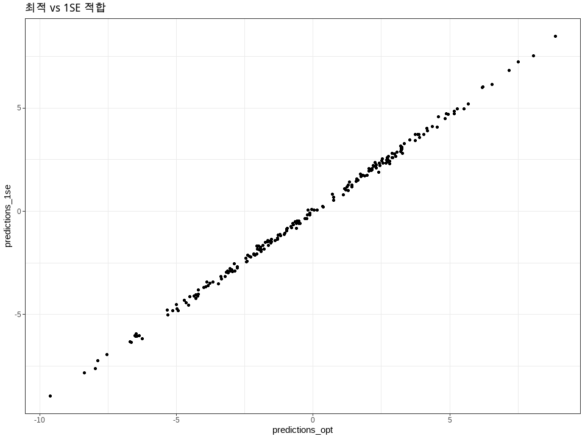

```r
# 표준화된 잔차
std_res_opt <- (y - predictions_opt) / sd(y - predictions_opt)
std_res_1se <- (y - predictions_1se) / sd(y - predictions_1se)

# 잔차 정의 및 그림
res_data <- data.frame(y,
                       predictions_opt,
                       predictions_1se,
                       std_res_opt,
                       std_res_1se)

res_data %>% ggplot() +
  geom_point(aes(predictions_opt, predictions_1se)) +
  labs(title = "최적 vs 1SE 적합") + theme_bw()
```

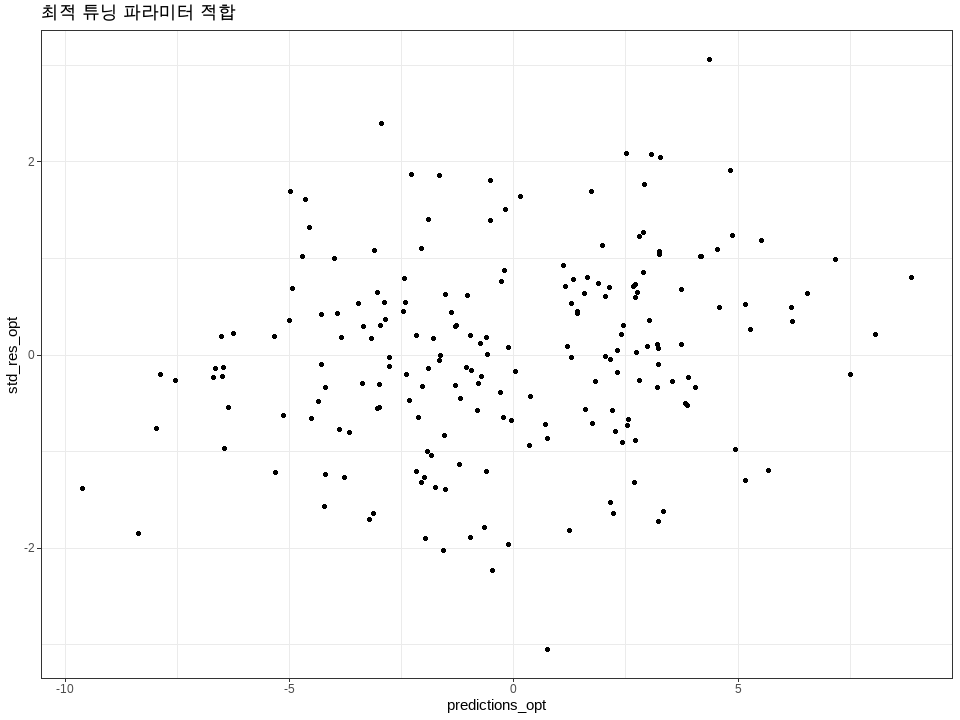

```r
res_data %>% ggplot() +
  geom_point(aes(predictions_opt, std_res_opt)) +
  labs(title = "최적 튜닝 파라미터 적합") + theme_bw()
```

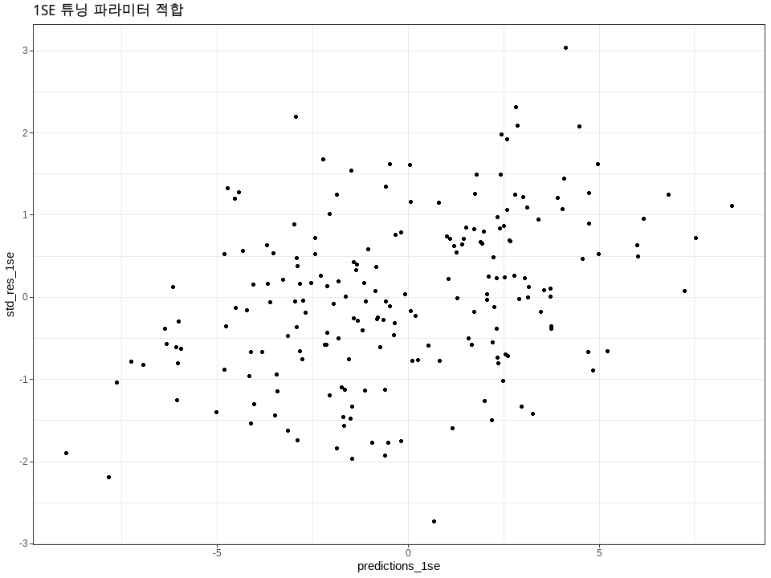

```r
res_data %>% ggplot() +
  geom_point(aes(predictions_1se, std_res_1se)) +
  labs(title = "1SE 튜닝 파라미터 적합") + theme_bw()
```

## 4.4. Elastic Net

- $L_1$ 노름과 $L_2$ 노름을 결합한 형태의 페널티를 동시에 적용하는 방법
  - Lasso의 변수 선택 기능과 Ridge의 다중공선성 축소 능력을 동시에 활용하고자 할 때 유용
  - $\lambda$는 정규화의 강도 조절
    - 0이면, 일반 선형 회귀
  - $\alpha$는 Ridge와 LASSO의 비율을 결정
    - 0이면 Ridge 회귀
    - 1이면 LASSO 회귀
- 주요 특징
  - 변수 선택과 계수 축소의 동시 적용 가능
  - 다중 공선성
  - 변수의 수(p) > 관찰값의 수(n)
    - OLS는 해를 찾을 수 없고, Lasso는 이러한 상황에서도 해를 찾을 수 있지만, 선택된 변수의 수가 관측치의 수를 초과할 수 없다. Elastic Net은 이러한 제한 없이 많은 수의 변수를 선택 가능
  - 일반화 성능 향상
    - Ridge와 Lasso의 조합이므로 데이터 과적합을 방지한다.
  - 변수 그룹화 기능
    - 상관관계가 높은 변수들은 Elastic Net에 의해 같이 선택되거나 제외되는 경향이 있다. 이는 변수의 그룹화 효과로, 상호 연관된 변수들 사이의 관계를 보존하면서 변수 선택 가능
- Ridge와 Lasso는 단일 튜닝 파리미터($\lambda$)만을 갖지만, 두 패널티 간의 균형을 조절하는 추가 튜닝 파라미터 $\alpha$도 결정해야 한다.

### 실습. 다중공선성 데이터에서의 비교

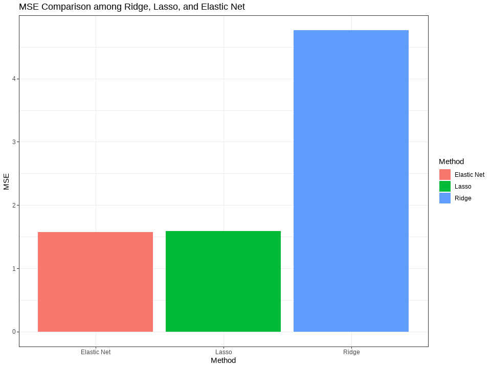

```r
library(glmnet)

# 데이터 생성
set.seed(4885)
n <- 100
p <- 50

#독립 변수 사이에 다중 공선성이 있도록 데이터 생성
X <- matrix(rnorm(n * p), ncol = p)
X <- scale(X)
X[, 1:10] <- X[, 1:10] + 3*X[, 11:20] + 2*X[, 21:30]

true_coef <- runif(p, -2, 2)
y <- X %*% true_coef + rnorm(n)

# 데이터를 training set과 test set으로 분할
train_rows <- sample(1:n, 0.7*n)
X_train <- X[train_rows, ]
y_train <- y[train_rows]

X_test <- X[-train_rows, ]
y_test <- y[-train_rows]

# Ridge, Lasso, Elastic Net 회귀 적합
cv.ridge <- cv.glmnet(X_train, y_train, alpha=0)
cv.lasso <- cv.glmnet(X_train, y_train, alpha=1)
cv.elnet <- cv.glmnet(X_train, y_train, alpha=0.5)

# 예측 및 MSE 계산
pred.ridge <- predict(cv.ridge, newx = X_test, s = cv.ridge$lambda.min)
pred.lasso <- predict(cv.lasso, newx = X_test, s = cv.lasso$lambda.min)
pred.elnet <- predict(cv.elnet, newx = X_test, s = cv.elnet$lambda.min)

mse.ridge <- mean((y_test - pred.ridge)^2)
mse.lasso <- mean((y_test - pred.lasso)^2)
mse.elnet <- mean((y_test - pred.elnet)^2)

mse.df <- data.frame(Method = c("Ridge", "Lasso", "Elastic Net"), MSE = c(mse.ridge, mse.lasso, mse.elnet))

# 그래프 그리기
ggplot(mse.df, aes(x = Method, y = MSE, fill = Method)) +
  geom_bar(stat="identity") +
  theme_bw() +
  labs(title = "MSE Comparison among Ridge, Lasso, and Elastic Net")
```

- 다중 공선성 데이터셋을 통해 실험을 해본 결과 Ridge 모델의 경우 패널티를 통해서 변수 제거는 불가능하므로 다른 방법에 비해 MSE값이 높은 결과가 나왔다.

## 4.5. Grouped LASSO

- 범주형 변수를 가변수로 사용할 때 매우 유용한 방법이다.
  - 그룹 내의 모든 변수들이 함께 선택되거나 함께 제외되도록 규제
  - 명시적 그룹 구조 - 범주형 변수의 가변수 처리된 집단 변수 등
- regularization_3.csv

### 실습. 표준화/가변수화/Grouped LASSO

- 표준화 적용 시 주의 사항
  - **계수 해석:** 원래의 단위로 보면 1단위 증가할때마다 반응변수가 5단위 증가한다라고 했다면, 표준쳔차가 1만큼 증가할 때 반응변수의 표준 편차가 5단위 증가한다로 해석해야 한다.
  - **예측 결과의 재변환:** 표준화된 모델에서 예측을 수행한 후 결과를 원래의 측정 단위로 다시 변환하는 것은 추가적인 계산이 필요하니까 참고해야 한다.

#### 함수: 표준화/Split

```r
library(gglasso)
# 데이터 불러오기
preprocess_data <- function(data, response_var, test_ratio = 0.3) {
  # Train/Test 데이터 분할
  set.seed(4885)
  train_idx <- sample(1:nrow(data), nrow(data)*(1-test_ratio))
  train_data <- data[train_idx, ]
  test_data <- data[-train_idx, ]

  # response 변수 저장
  y_train <- train_data[[response_var]]
  y_test <- test_data[[response_var]]

  # character 클래스를 가진 열을 factor로 변환
  char_cols <- sapply(train_data, is.character)
  train_data[, char_cols] <- lapply(train_data[, char_cols], as.factor)
  test_data[, char_cols] <- lapply(test_data[, char_cols], as.factor)

  #연속형 변수 표준화
  numeric_cols <- sapply(train_data, is.numeric)
  means <- sapply(train_data[, numeric_cols], mean)
  sds <- sapply(train_data[, numeric_cols], sd)
  train_data[, numeric_cols] <- sweep(train_data[, numeric_cols], 2, means, "-")
  train_data[, numeric_cols] <- sweep(train_data[, numeric_cols], 2, sds, "/")
  test_data[, numeric_cols] <- sweep(test_data[, numeric_cols], 2, means, "-")
  test_data[, numeric_cols] <- sweep(test_data[, numeric_cols], 2, sds, "/")

  # 범주형 변수 가변수화(그리고 이름 간소화)
  train_matrix <- model.matrix(~ . , data = train_data)
  colnames(train_matrix) <- make.names(colnames(train_matrix), unique = TRUE)
  train_data <- as.data.frame(train_matrix)
  test_matrix <- model.matrix(~ . , data = test_data)
  colnames(test_matrix) <- make.names(colnames(test_matrix), unique = TRUE)
  test_data <- as.data.frame(test_matrix)

  # response 변수 복원 및 절편 삭제
  # train_data[[response_var]] <- y_train
  train_data <- train_data[, -1]
  # test_data[[response_var]] <- y_test
  test_data <- test_data[, -1]

  # 훈련 데이터와 테스트 데이터 분리
  X_train <- train_data
  X_test <- test_data

  # 반응 변수 y를 예측 변수 데이터셋에서 제거
  X_train <- X_train[, !(colnames(X_train) %in% response_var)]
  X_test <- X_test[, !(colnames(X_test) %in% response_var)]

  # feature 변수를 학습 형태에 맞게 matrix로 변환
  X_train <- as.matrix(X_train)
  X_test <- as.matrix(X_test)
  list(X_train=X_train, X_test=X_test, y_train=y_train, y_test=y_test)
}
```

```r
# Train/Test Dataset split
case3 <- read.csv(paste0(data_path, "regularization_3.csv"))
preprocess_df  <- preprocess_data(case3,"y",test_ratio = 0.3)
X_train <- preprocess_df$X_train
X_test <- preprocess_df$X_test
y_train <- preprocess_df$y_train
y_test <- preprocess_df$y_test

# train/test 제대로 분리되었는지 확인
head(X_train, 5)
```

```
##        X1      X2     X3      X4      X5     X6     X7      X8     X9
## 3   0.660 -0.2868 -0.923  0.4722  0.1530 -1.484 -0.194  1.6193 -0.497
## 13  1.304 -0.2921 -1.540 -1.5790 -0.0273 -1.876 -0.205 -1.7278 -0.841
## 58 -0.761 -0.0112 -0.700 -0.0203 -1.0661  1.753  0.349 -0.0961  0.310
## 85 -0.315  0.6986 -0.941 -0.0220  1.5560  1.176 -0.546  0.0387  1.473
## 29 -1.400 -1.6660 -1.597 -0.7579  0.8836  0.593  2.210  0.8872 -0.231
##        X10    X11    X12    X13     X14    X15    X16    X17    X18
## 3   0.2626  0.850  0.167 -0.990  0.3222  0.130 -1.075  0.128  1.331
## 13 -0.4468  1.410 -0.626 -1.489 -1.0813 -0.299 -1.819 -0.164 -1.399
## 58 -0.0163 -0.418 -0.017 -0.783  0.0922 -1.213  1.713  0.228  0.490
## 85  0.9844 -0.780  1.146 -1.380 -0.1013  1.690  1.020 -0.599  0.532
## 29  1.4080 -1.678 -1.666 -1.590 -0.6168  1.108  0.759  1.873  1.031
##       X19      X20 locationCR locationLC locationLL locationRR
## 3  -0.764 -0.18804          0          0          0          1
## 13 -1.180 -0.81017          0          0          0          1
## 58  0.392 -0.00564          0          0          0          0
## 85  1.111  0.98390          0          0          1          0
## 29 -0.281  1.25563          0          0          1          0
##    materialM2 materialM3
## 3           1          0
## 13          0          0
## 58          0          1
## 85          0          1
## 29          0          1
```

```r
head(y_train, 5)
```

```
## [1]   11.2 -142.8   13.6  117.2   36.9
```

```r
head(X_test, 5)
```

```
##        X1     X2      X3      X4     X5     X6      X7     X8     X9
## 2   0.782 0.4556 -1.2605 -2.2016 -0.196  1.023 -0.0195  2.232 -0.773
## 6   1.438 0.0149 -1.3299 -1.2402 -1.513 -0.548 -0.2516 -1.613  0.666
## 8  -0.360 0.6564  0.0638 -1.0833  2.500  1.913  1.2185  2.072 -0.418
## 10  0.262 0.7688  0.8581 -1.8073  0.576 -0.231  1.0501 -0.576  2.099
## 11 -1.278 0.4274  1.3113 -0.0957  0.434  1.321  0.4511  0.111 -1.278
##       X10     X11   X12    X13    X14    X15    X16     X17    X18
## 2   0.535  0.5306 0.260 -0.742 -2.295 -0.212  1.447 -0.2381  2.413
## 6  -0.197  0.8307 0.550 -1.165 -1.711 -1.343 -0.770 -0.0873 -1.950
## 8   1.225 -0.0582 0.302 -0.330 -1.494  2.503  2.344  1.5925  2.169
## 10  1.055 -0.3622 0.391  1.584 -1.511  0.248 -0.981  1.2877 -0.536
## 11  0.797 -0.9150 0.852  1.173 -0.109  0.504  0.891  0.6234 -0.406
##       X19   X20 locationCR locationLC locationLL locationRR materialM2
## 2  -0.997 1.158          0          0          1          0          1
## 6   0.260 0.182          0          0          1          0          0
## 8  -0.144 1.196          0          0          0          0          0
## 10  1.754 0.872          0          1          0          0          0
## 11 -1.079 0.842          0          0          0          1          0
##    materialM3
## 2           0
## 6           1
## 8           0
## 10          0
## 11          1
```

```r
head(y_test, 5)
```

```
## [1]  29.4 -83.2 193.2 101.2  71.2
```

- 연속형 변수를 표준화할 때의 주의사항
  - Test dataset은 새로운 데이터를 대표하기 때문에 test dataset에 대해서 표준화 진행할 때는 train데이터의 평균, 표준편차값으로 표준화를 진행해야 Data Leakage를 방지할 수 있음.
  - Train dataset에서 파생된 통계적 특성(평균, 표준편차)을 사용하여 테스트 데이터셋을 표준화함으로써, 모델이 학습한 환경과 동일한 조건 하에 테스트 데이터셋의 성능을 평가할 수 있다.
- 범주형 변수를 표준활 때의 주의사항
  - model.matrix에서 -1을 추가하여 기준 범주를 제외할시에 k-1개의 범주를 생성하는 것이 아닌 k개의 범주를 생성하여 후처리를 통해 기준 범주를 제외진행하였다.
  - lasso를 진행할 때는 반드시 가변수화한 범주에 대하여 groups를 지정하여 특정 가변수화된 변수가 제외되지 않도록 해야 함.

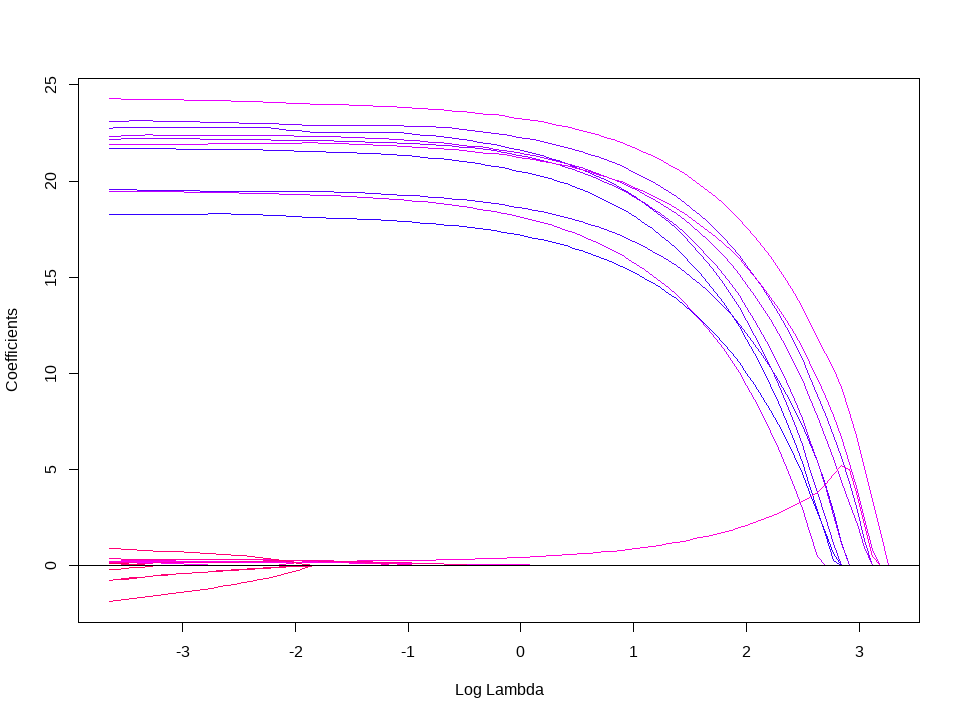

```r
# 그룹 설정
groups <- c(rep(1:20), rep(21,4), rep(22,2))

# Lasso Regression 적합
lasso.mod <- gglasso(X_train, y_train, group=groups)
plot(lasso.mod, xvar="lambda", label=TRUE)
```

- Location과 Material 두 범주형 변수에 대해서 가변수화를 진행하여 각 변수에 나온 가변수를 group으로 묶어주었다.
  - 이는 Lasso모델을 적합했을 때 group내 가변수가 제거되지 않도록 하기 위함.
- 교차 검증 및 최적 $\lambda$ 추정

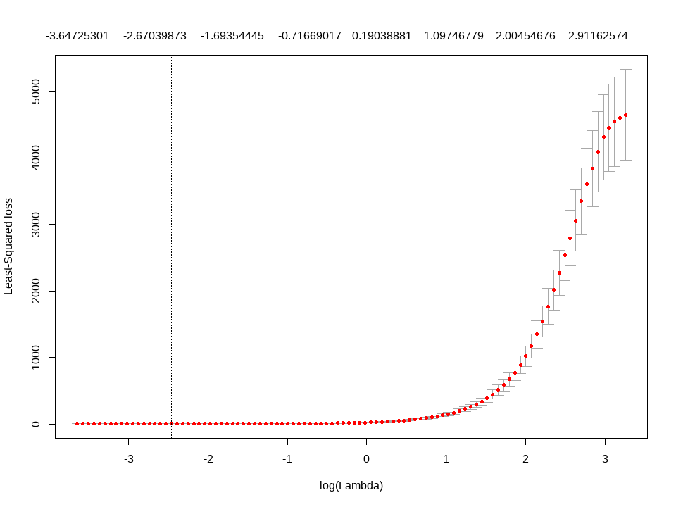

```r
# 교차 검증, k = 10
cv.lasso <- cv.gglasso(X_train, y_train, group=groups)
plot(cv.lasso)
```

```r
# 최적 lambda 결정
lambda_opt <- cv.lasso$lambda.min
lambda_1se <- cv.lasso$lambda.1se
c(lambda_opt, lambda_1se)
```

```
## [1] 0.0321 0.0853
```

- 모델 학습 및 예측: MSE 계산 및 비교

```r
# 최적 lambda에 대한 모델 학습
model_opt <- gglasso(X_train, y_train, lambda = lambda_opt, group=groups)

# 1SE 내의 최소 복잡성을 갖는 lambda에 대한 모델 학습
model_1se <- gglasso(X_train, y_train, lambda = lambda_1se, group=groups)

# 두 모델을 이용한 예측 - 실무에서는 newx = Test Data
predictions_opt <- predict(model_opt, newx=X_test)
predictions_1se <- predict(model_1se, newx=X_test)

# MSE 계산
mse_opt <- mse(y_test, predictions_opt)
mse_1se <- mse(y_test, predictions_1se)

# MSE 확인
c(mse_opt, mse_1se)
```

```
## [1] 4.79 6.49
```

- 최적 $\lambda$ 로 적용 했을 때 mse값이 더 낮은 것을 알 수 있다.
- 잔차 계산 및 비교

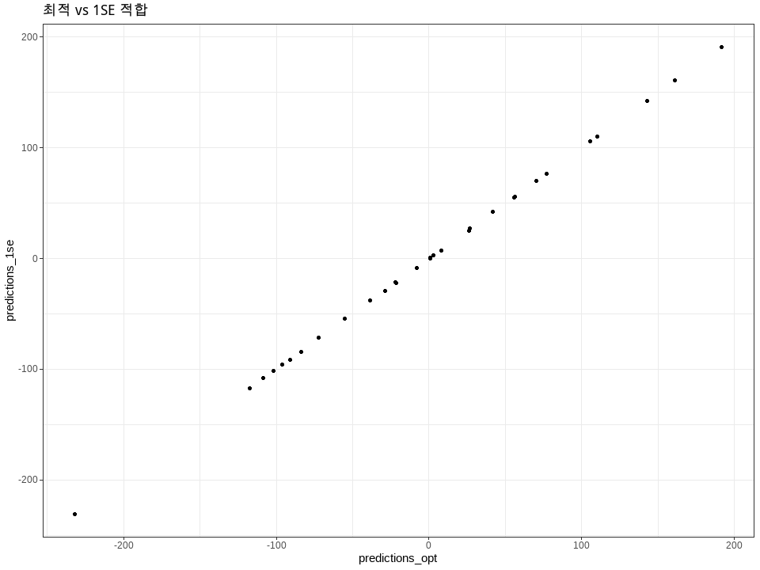

```r
# 표준화된 잔차
std_res_opt <- (y_test - predictions_opt) / sd(y_test - predictions_opt)
std_res_1se <- (y_test - predictions_1se) / sd(y_test - predictions_1se)

# 잔차 정의 및 그림
res_data <- data.frame(y_test,
                       predictions_opt,
                       predictions_1se,
                       std_res_opt,
                       std_res_1se)

res_data %>% ggplot() +
  geom_point(aes(predictions_opt, predictions_1se)) +
  labs(title = "최적 vs 1SE 적합") + theme_bw()
```

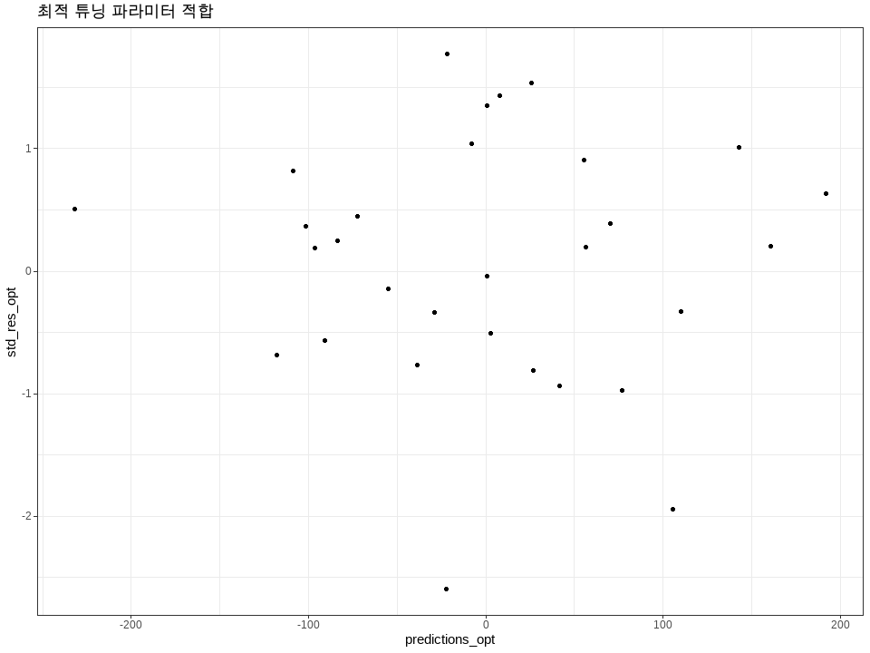

```r
res_data %>% ggplot() +
  geom_point(aes(predictions_opt, std_res_opt)) +
  labs(title = "최적 튜닝 파라미터 적합") + theme_bw()
```

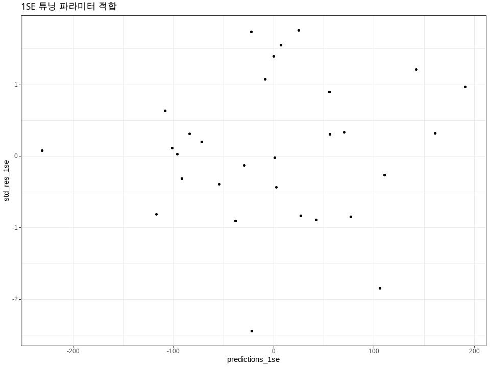

```r
res_data %>% ggplot() +
  geom_point(aes(predictions_1se, std_res_1se)) +
  labs(title = "1SE 튜닝 파라미터 적합") + theme_bw()
```

## 4.6. “Optimizing Model Performance”: A Comprehensive Exercise on Regularization

- usa_wage.csv
  - 미국 Mid-Atlantic 지역의 직장인 3000명에 대한 급여와 관련 정보

| Variable Name | Description |
| --- | --- |
| year | 임금정보가 기록된 연도 |
| age | 근로자의 나이 |
| maritl | 혼인 상태(1. Never Married 2. Married 3. Widowed 4. Divorced 5. Separated) |
| race | 1. White 2. Black 3. Asian 4. Other indicating race |
| education | 1. < HS Grad 2. HS Grad 3. Some College 4. College Grad 5. Advanced |
| region | mid-atlantic만 존재 |
| jobclass | 직업의 종류(1. Industrial 2. Information) |
| health | 근로자 건강 수준(1. <=Good 2. >=Very Good) |
| health_ins | 근로자의 건강보험 가입 여부(1. Yes / 2. No) |
| logwage | 근로자의 임금 로그값 |
| wage | 근로자의 임금 |

### 데이터 파악

- 변수 type 및 데이터 개수 파악하기

```r
wage <- read.csv(paste0(data_path, "usa_wage.csv"))
str(wage)
```

```
## 'data.frame':    3000 obs. of  11 variables:
##  $ year      : int  2006 2004 2003 2003 2005 2008 2009 2008 2006 2004 ...
##  $ age       : int  18 24 45 43 50 54 44 30 41 52 ...
##  $ maritl    : chr  "1. Never Married" "1. Never Married" "2. Married" "2. Married" ...
##  $ race      : chr  "1. White" "1. White" "1. White" "3. Asian" ...
##  $ education : chr  "1. < HS Grad" "4. College Grad" "3. Some College" "4. College Grad" ...
##  $ region    : chr  "2. Middle Atlantic" "2. Middle Atlantic" "2. Middle Atlantic" "2. Middle Atlantic" ...
##  $ jobclass  : chr  "1. Industrial" "2. Information" "1. Industrial" "2. Information" ...
##  $ health    : chr  "1. <=Good" "2. >=Very Good" "1. <=Good" "2. >=Very Good" ...
##  $ health_ins: chr  "2. No" "2. No" "1. Yes" "1. Yes" ...
##  $ logwage   : num  4.32 4.26 4.88 5.04 4.32 ...
##  $ wage      : num  75 70.5 131 154.7 75 ...
```

```r
summary(wage)
```

```
##       year           age          maritl              race
##  Min.   :2003   Min.   :18.0   Length:3000        Length:3000
##  1st Qu.:2004   1st Qu.:33.8   Class :character   Class :character
##  Median :2006   Median :42.0   Mode  :character   Mode  :character
##  Mean   :2006   Mean   :42.4
##  3rd Qu.:2008   3rd Qu.:51.0
##  Max.   :2009   Max.   :80.0
##   education            region            jobclass
##  Length:3000        Length:3000        Length:3000
##  Class :character   Class :character   Class :character
##  Mode  :character   Mode  :character   Mode  :character
##
##
##
##     health           health_ins           logwage          wage
##  Length:3000        Length:3000        Min.   :3.00   Min.   : 20
##  Class :character   Class :character   1st Qu.:4.45   1st Qu.: 85
##  Mode  :character   Mode  :character   Median :4.65   Median :105
##                                        Mean   :4.65   Mean   :112
##                                        3rd Qu.:4.86   3rd Qu.:129
##                                        Max.   :5.76   Max.   :318
```

- wgge와 log(wage) 확인

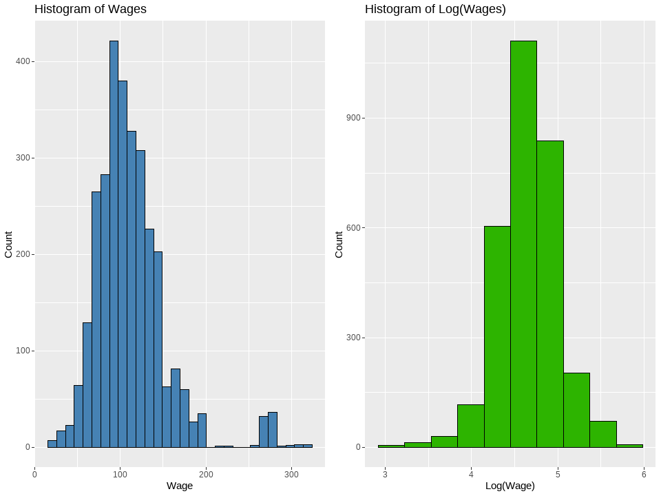

```r
p1 <- ggplot(wage, aes(x = wage)) +
      geom_histogram(bins = 30, fill = sbl, color = "black") +
      labs(title = "Histogram of Wages", x = "Wage", y = "Count")

p2 <- ggplot(wage, aes(x = logwage)) +
      geom_histogram(bins = 10, fill = ngr, color = "black") +
      labs(title = "Histogram of Log(Wages)", x = "Log(Wage)", y = "Count")
#
gridExtra::grid.arrange(p1, p2, ncol = 2)
```

- 먼저 wage 그래프를 살펴 보면 이상값이 영향을 끼치는 것으로 보인다.
  - 따라서 로그 변환을 통해 이상값이 모델에 미칠 영향을 적게 만들어준다.
- 예측 변수들의 빈도 파악

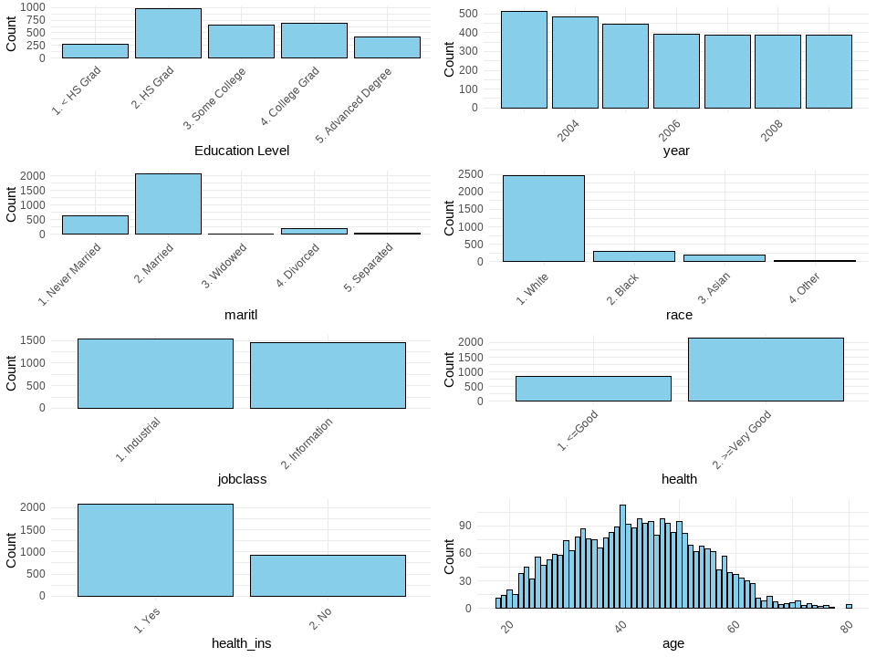

```r
p1 <-   ggplot(wage, aes(x = education)) +
          geom_bar(fill = "skyblue", color = "black") +
          labs(x = "Education Level", y = "Count") +
          theme_minimal() +
          theme(axis.text.x = element_text(angle = 45, hjust = 1))

p2 <-   ggplot(wage, aes(x = year)) +
          geom_bar(fill = "skyblue", color = "black") +
          labs(x = "year", y = "Count") +
          theme_minimal() +
          theme(axis.text.x = element_text(angle = 45, hjust = 1))
p3 <-   ggplot(wage, aes(x = maritl)) +
          geom_bar(fill = "skyblue", color = "black") +
          labs(x = "maritl", y = "Count") +
          theme_minimal() +
          theme(axis.text.x = element_text(angle = 45, hjust = 1))

p4 <-   ggplot(wage, aes(x = race)) +
          geom_bar(fill = "skyblue", color = "black") +
          labs(x = "race", y = "Count") +
          theme_minimal() +
          theme(axis.text.x = element_text(angle = 45, hjust = 1))
p5 <-   ggplot(wage, aes(x = jobclass)) +
          geom_bar(fill = "skyblue", color = "black") +
          labs(x = "jobclass", y = "Count") +
          theme_minimal() +
          theme(axis.text.x = element_text(angle = 45, hjust = 1))

p6 <-   ggplot(wage, aes(x = health)) +
          geom_bar(fill = "skyblue", color = "black") +
          labs(x = "health", y = "Count") +
          theme_minimal() +
          theme(axis.text.x = element_text(angle = 45, hjust = 1))
p7 <-   ggplot(wage, aes(x = health_ins)) +
          geom_bar(fill = "skyblue", color = "black") +
          labs(x = "health_ins", y = "Count") +
          theme_minimal() +
          theme(axis.text.x = element_text(angle = 45, hjust = 1))
p8 <-   ggplot(wage, aes(x = age)) +
          geom_bar(fill = "skyblue", color = "black") +
          labs(x = "age", y = "Count") +
          theme_minimal() +
          theme(axis.text.x = element_text(angle = 45, hjust = 1))
gridExtra::grid.arrange(p1, p2, p3, p4, p5, p6, p7, p8, nrow = 4, ncol = 2)
```

- 예측 변수의 빈도수를 살펴보면 다음과 같다.
  - 결혼을 한 비율이 다른 비율에 비해 압도적으로 높은곳을 확인해볼 수 있다.
  - 다른 인종에 비해 백인이 더 많이 보인다.
  - 직업군은 크게 치우치진 않았고 비슷하게 수집이 되었다.
  - 나중에 예측을 진행하게 되면 특정 인종과 기혼 가정에 치우치게 결과가 나올 수도 있을 것 같다.

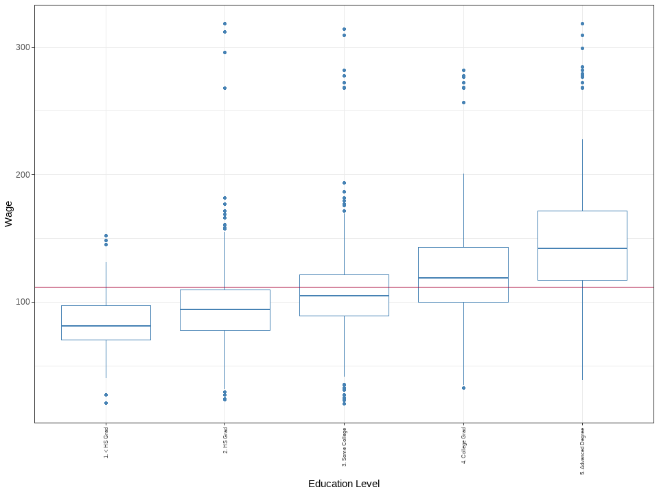

```r
# wage의 mean값
limit <- 112

wage %>%
  ggplot(aes(x = education, y = wage)) +
  geom_boxplot(position = position_dodge(width = 0.8), color = sbl) +
  labs(x = "Education Level", y = "Wage") +
  geom_hline(yintercept = limit, color = lre) +
  theme_bw() +
  theme(axis.text.x = element_text(angle = 90, vjust = 0.5, hjust = 1, size = 6))
```

- 교육수준에 따른 임금에 대한 boxplot을 그려보았다.
  - 빨간색 수평선으로 Wage의 대한 평균을 선으로 나타내었는데 Education Level이 높을수록 임금에 영향을 끼칠 것으로 보였다.

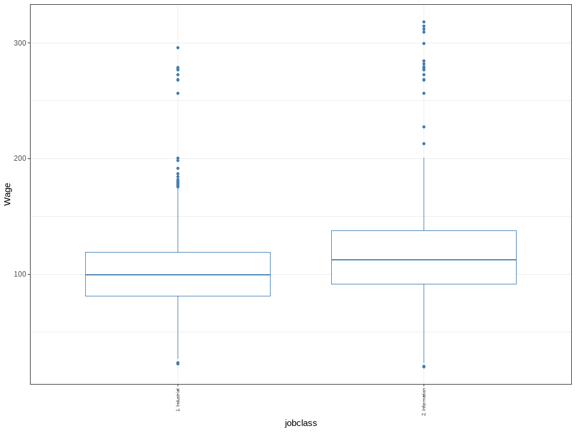

```r
# job class
wage %>%
  ggplot(aes(x = jobclass, y = wage)) +
  geom_boxplot(position = position_dodge(width = 0.8), color = sbl) +
  labs(x = "jobclass", y = "Wage") +
  theme_bw() +
  theme(axis.text.x = element_text(angle = 90, vjust = 0.5, hjust = 1, size = 6))
```

- job class에 따라서는 비슷한 경향을 보인다.

### 모델 비교를 위한 전처리 및 준비

- train/test split 확인

```r
wage_df <- preprocess_data(subset(wage, select = -c(wage, region)), "logwage", test_ratio = 0.3)

# Train/Test Dataset split
X_train <- wage_df$X_train
X_test <- wage_df$X_test
y_train <- wage_df$y_train
y_test <- wage_df$y_test

# train/test
head(X_train, 5)
```

```
##        year    age maritl2..Married maritl3..Widowed maritl4..Divorced
## 2800 -1.362 -0.211                1                0                 0
## 1027  0.595  0.733                1                0                 0
## 2282 -1.362 -0.125                1                0                 0
## 13   -0.383 -0.640                0                0                 0
## 2901  1.573  1.420                1                0                 0
##      maritl5..Separated race2..Black race3..Asian race4..Other
## 2800                  0            0            0            0
## 1027                  0            1            0            0
## 2282                  0            0            0            0
## 13                    0            0            0            0
## 2901                  0            0            0            0
##      education2..HS.Grad education3..Some.College
## 2800                   0                        0
## 1027                   0                        0
## 2282                   0                        1
## 13                     1                        0
## 2901                   0                        0
##      education4..College.Grad education5..Advanced.Degree
## 2800                        0                           1
## 1027                        0                           1
## 2282                        0                           0
## 13                          0                           0
## 2901                        0                           1
##      jobclass2..Information health2....Very.Good health_ins2..No
## 2800                      1                    0               1
## 1027                      1                    1               0
## 2282                      0                    1               0
## 13                        1                    1               0
## 2901                      1                    1               1
```

```r
head(y_train, 5)
```

```
## [1] 4.85 5.26 5.00 4.49 4.54
```

```r
head(X_test, 5)
```

```
##      year    age maritl2..Married maritl3..Widowed maritl4..Divorced
## 5  -0.383  0.647                0                0                 1
## 7   1.573  0.132                1                0                 0
## 10 -0.873  0.819                1                0                 0
## 11  0.595  0.218                0                0                 1
## 12  0.595 -0.726                1                0                 0
##    maritl5..Separated race2..Black race3..Asian race4..Other
## 5                   0            0            0            0
## 7                   0            0            0            1
## 10                  0            0            0            0
## 11                  0            0            0            0
## 12                  0            0            0            0
##    education2..HS.Grad education3..Some.College
## 5                    1                        0
## 7                    0                        1
## 10                   1                        0
## 11                   0                        1
## 12                   1                        0
##    education4..College.Grad education5..Advanced.Degree
## 5                         0                           0
## 7                         0                           0
## 10                        0                           0
## 11                        0                           0
## 12                        0                           0
##    jobclass2..Information health2....Very.Good health_ins2..No
## 5                       1                    0               0
## 7                       0                    1               0
## 10                      1                    1               0
## 11                      1                    0               0
## 12                      0                    1               1
```

```r
head(y_test, 5)
```

```
## [1] 4.32 5.13 4.86 4.76 4.40
```

### Ridge, Lasso, ElasticNet, Groupped Lasso 비교

- Groupped Lasso 모델의 교차 검증 진행
  - k = 10으로 고정.

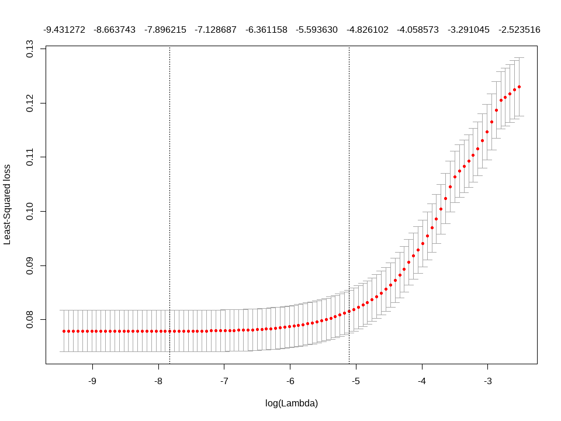

```r
# 그룹 설정
groups <- c(1, 2, rep(3,4), rep(4,3), rep(5,4), 6, 7, 8)

# Grouped Lasso Regression 적합
cv.glasso <- cv.gglasso(X_train, y_train, group=groups, nfolds = 10)
plot(cv.glasso)
```

```r
# 최적 lambda 결정
lambda_opt <- cv.glasso$lambda.min
lambda_1se <- cv.glasso$lambda.1se
print(c(lambda_opt, lambda_1se))
```

```
## [1] 0.000399 0.006065
```

- Ridge, Lasso, ElasticNet 모델의 교차 검증 및 최적 $\lambda$ 추정
  - 0 ~ 1 사이에 alpha값을 0.01 조정하며 탐색.
  - k = 10으로 고정

```r
alpha_seq <- seq(0, 1, by = 0.01)

# cross-validation results를 위한 dataframe 초기화
cv_results <- data.frame(
  alpha = alpha_seq,
  lambda_min = rep(NA, length(alpha_seq)),
  cv_rmse_min = rep(NA, length(alpha_seq)),
  lambda_1se = rep(NA, length(alpha_seq)),
  cv_rmse_1se = rep(NA, length(alpha_seq))
)

# Loop over alpha values
for (i in seq_along(alpha_seq)) {
  # alpha 값을 0 ~ 1까지 0.01씩 증가하며 진행
  cv_fit <- cv.glmnet(X_train, y_train, alpha = alpha_seq[i], nfolds = 10)

  # minimum cvm
  cv_results$cv_rmse_min[i] <- min(cv_fit$cvm)

  # 1se cvm
  cv_results$cv_rmse_1se[i] <- cv_fit$cvm[cv_fit$lambda == cv_fit$lambda.1se]

  # best lambda
  cv_results$lambda_min[i] <- cv_fit$lambda.min
  cv_results$lambda_1se[i] <- cv_fit$lambda.1se
}

# Find the alpha value with the lowest cross-validation RMSE
optimal_alpha_min <- cv_results$alpha[which.min(cv_results$cv_rmse_min)]
optimal_alpha_1se <- cv_results$alpha[which.min(cv_results$cv_rmse_1se)]

# "Optimal alpha: 0.67"
cv_fit_opt <- cv.glmnet(X_train, y_train, alpha = optimal_alpha_min, nfolds = 10)
print(paste("Optimal alpha (minimum RMSE):", optimal_alpha_min))
```

```
## [1] "Optimal alpha (minimum RMSE): 0.67"
```

```r
lambda_opt2 <- cv_fit_opt$lambda.min

# "1se rule alpha: 0.93"
cv_fit_1se <- cv.glmnet(X_train, y_train, alpha = optimal_alpha_1se, nfolds = 10)
print(paste("Optimal alpha (1se rule RMSE):", optimal_alpha_1se))
```

```
## [1] "Optimal alpha (1se rule RMSE): 0.93"
```

```r
lambda_1se2 <- cv_fit_1se$lambda.1se

# 각각 optimal alpha일때와 1se rule alpha
print(c(lambda_opt2, lambda_1se2))
```

```
## [1] 0.000742 0.018350
```

### 모델 학습 및 예측: MSE 계산 및 비교

```r
# Train glmnet models
model_opt2 <- glmnet(X_train, y_train, alpha = optimal_alpha_min, lambda = lambda_opt2)
model_1se2 <- glmnet(X_train, y_train, alpha = optimal_alpha_1se, lambda = lambda_1se2)


# 최적 lambda에 대한 모델 학습
model_opt <- gglasso(X_train, y_train, lambda = lambda_opt, group=groups)
# 1SE 내의 최소 복잡성을 갖는 lambda에 대한 모델 학습
model_1se <- gglasso(X_train, y_train, lambda = lambda_1se, group=groups)

# Predictions
predictions_opt2 <- predict(model_opt2, newx = X_test, s = lambda_opt2)
predictions_1se2 <- predict(model_1se2, newx = X_test, s = lambda_1se2)
predictions_opt <- predict(model_opt, newx = X_test)
predictions_1se <- predict(model_1se, newx = X_test)

# Calculate MSE and RMSE
mse_opt2 <- mse(y_test, predictions_opt2)
mse_1se2 <- mse(y_test, predictions_1se2)
rmse_opt2 <- rmse(y_test, predictions_opt2)
rmse_1se2 <- rmse(y_test, predictions_1se2)
mse_opt <- mse(y_test, predictions_opt)
mse_1se <- mse(y_test, predictions_1se)
rmse_opt <- rmse(y_test, predictions_opt)
rmse_1se <- rmse(y_test, predictions_1se)

# Check MSE and RMSE
results <- c(mse_opt2, mse_1se2, rmse_opt2, rmse_1se2, mse_opt, mse_1se, rmse_opt, rmse_1se)
names(results) <- c("MSE Opt_ElasticNet", "MSE 1SE_ElasticNet", "RMSE Opt_ElasticNet", "RMSE 1SE_ElasticNet", "MSE Opt_group", "MSE 1SE_group", "RMSE Opt_group", "RMSE 1SE_group")
print(results)
```

```
##  MSE Opt_ElasticNet  MSE 1SE_ElasticNet RMSE Opt_ElasticNet
##              0.0794              0.0823              0.2819
## RMSE 1SE_ElasticNet       MSE Opt_group       MSE 1SE_group
##              0.2868              0.0795              0.0839
##      RMSE Opt_group      RMSE 1SE_group
##              0.2820              0.2897
```

### 최종 모형 선택

- $\alpha$값을 조정하여 얻은 ElasticNet 모형과 Grouped LASSO의 test dataset에 적용한 실험 결과표이다.

| Model | MSE | RMSE |
| --- | --- | --- |
| MSE Opt_ElasticNet | 0.0794 | 0.2819 |
| MSE 1SE_ElasticNet | 0.0823 | 0.2868 |
| MSE Opt_group | 0.0795 | 0.2820 |
| MSE 1SE_group | 0.0839 | 0.2897 |

- ElasticNet과 Grouped LASSO 모델 간의 MSE/RMSE값이 크게 차이가 나지 않았기 때문에 그룹 내의 모든 변수들이 함께 선택되거나 함께 제외되도록 규제를 줄 수 있는 Grouped LASSO를 최종 모형으로 선택했다. 이는 그룹화된 관계를 제안할 때 Grouped LASSO 모델이 ElasticNET 모델보다 더 유익하다고 판단되었기 때문이다.

### Grouped LASSO 모형의 잔차 계산 및 비교

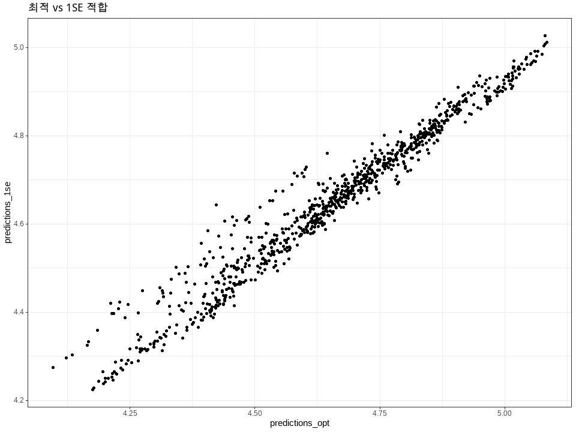

```r
# 표준화된 잔차
std_res_opt <- (y_test - predictions_opt) / sd(y_test - predictions_opt)
std_res_1se <- (y_test - predictions_1se) / sd(y_test - predictions_1se)

# 잔차 정의 및 그림
res_data <- data.frame(y_test,
                       predictions_opt,
                       predictions_1se,
                       std_res_opt,
                       std_res_1se)
res_data %>% ggplot() +
  geom_point(aes(predictions_opt, predictions_1se)) +
  labs(title = "최적 vs 1SE 적합") + theme_bw()
```

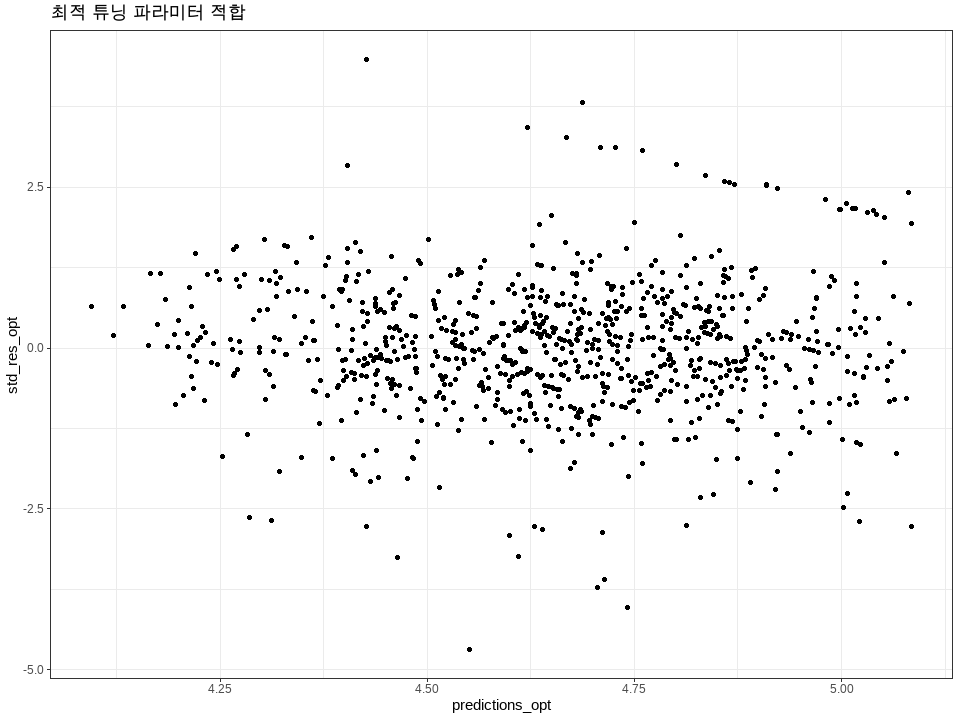

```r
res_data %>% ggplot() +
  geom_point(aes(predictions_opt, std_res_opt)) +
  labs(title = "최적 튜닝 파라미터 적합") + theme_bw()
```

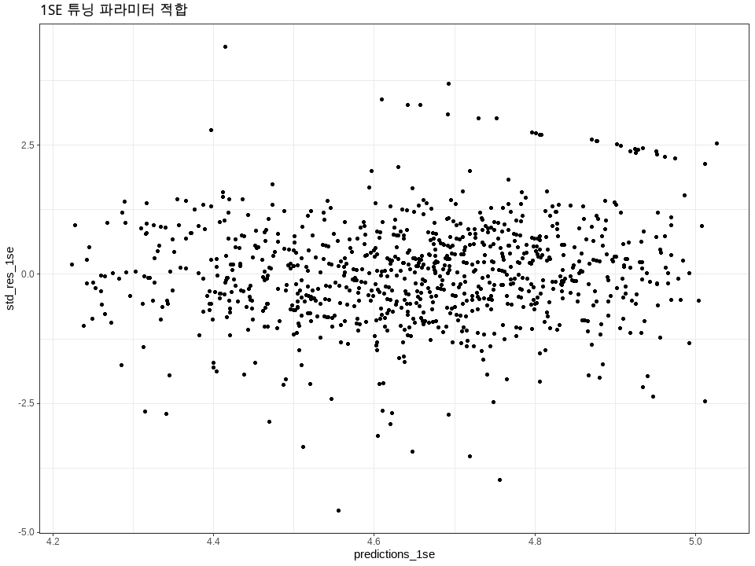

```r
res_data %>% ggplot() +
  geom_point(aes(predictions_1se, std_res_1se)) +
  labs(title = "1SE 튜닝 파라미터 적합") + theme_bw()
```

- Grouped LASSO의 최적화된 적합과 1SE 적합에 대한 표준화된 잔차 플롯을 살펴보면, 두 모델 모두 예측 범위에 걸쳐 일관된 오차 분산을 보이며 0을 중심으로 비슷하게 퍼져있는 것을 볼 수 있었다.
- “최적 대비 1SE 적합” 비교 플롯을 살펴볼 때, 유의미한 차이가 관찰되지 않았다. 따라서 1-표준 오차 규칙에 따라 Group LASSO 1SE 모델을 최종 모델로 선택했다. 이 규칙은 오차 곡선의 최소값에서 한 표준 오차 내의 가장 단순한 모델을 선택하는 것을 제안하며, 이는 보이지 않는 데이터에 대한 더 나은 일반화 성능을 제공할 가능성이 높다고 할 수 있다.

# 중요한 기본 R함수 정리

- 변수명은 대문자 또는 소문자로 통일하는 것이 바람직하다.

## 데이터 확인

`str()`  
`head()`  
`tail()`  
`view()` `summary()` `table()`

## 회귀 분석

`stats::lm()`: lm(y ~ x, data = data)으로 지정

- `name()`는 모형 적합 객체(object)에 포함된 구성 요소들의 이름을 확인해준다.
  - ex) model(dist_fit), model(summary(dist_fit))
- 이상점(outliers)의 진단
  - `rstandard()`: 표준화 잔차(standardized residuals)
    - 표준화 잔차의 절대값이 2보다 크거나 같은 경우만을 선택
      - rsd <- rstandard(dist_fit)
      - outliers_d <- as.numeric(names(rsd)[abs(rsd) >= 2])
      - dist[outliers_d, ]: 이상치 확인
      - dist[-outliers_d, ]: 검토 결과 이를 제거해야 한다면 다음을 이용하여 제거
  - `rstudent()`: 스튜던트화 잔차(studentized residuals)
    - 스튜던트화 잔차의 절대값이 3보다 크거나 같은 경우만을 선택
- `ggexport()`을 이용하여 생성된 plot을 원하는 위치의 외부 화일로 저장가능하다.
  - ggexport(object, filename = “./image/object.pdf”)
- `geom_smooth()`는 사전 분석 없이 기본 그림에 추정된 회귀식을 함께 도시해준다.

## 사용자 정의 함수 정리

`na_count(data)`: 결측값 확인  
`data_pre(data)`: 데이터의 변수들의 이름을 모두 소문자로 전환하는 함수  
`simple_reg(data, x, y)`: 단순 회귀 분석 최종 결과를 시각화하는 함수 `preprocess_data(data, "response_var", test_ratio = 0.3)`: 데이터 표준화 및 Split을 해주는 함수 `mse(actual, predicted)`: mse 함수 `rmse(actual, predicted)`: rmse 함수

데이터 정보 출처 - https://rdrr.io/cran/ISLR/man/Wage.html

ⓒ Statistical Method1, Gachon University